# 时间序列分析：从零基础到前沿（全书 · 21 章 + 3 附录 · 含插图）

# 第 00 章 · 写给读者：这本书的写法与用法（写作与审阅规范）

> 这一章不讲解时间序列本身，而是说明**这本书如何被写出来、如何被审阅、你该如何读它**。对读者而言它是一份”使用说明书”；对写作过程而言它是约束每一章的**规范与审阅清单**。

## 0.1 这本书写给谁

- **目标读者**：完全没有统计学与编程基础的**零基础学习者**，以及想系统梳理知识框架的中级学习者。
- **写作第一原则**：*“每一步都必须能被一个零基础的人完全理解——知道’做了什么’、‘为什么这么做’、‘会得到什么效果’。”* 任何一步做不到这一点，就是本章需要返工的信号。

## 0.2 全书地图

```
第一部分 基础概念（第 1–2 章）   —— 时间序列长什么样、由什么构成
第二部分 统计语言准备（第 3–5 章）—— 描述"不确定"的数学语言
第三部分 经典统计方法（第 6–12 章）—— 从平滑到 ARIMA、状态空间、GARCH、协整
第四部分 机器学习与深度学习（第 13–16 章）—— 从特征工程到 Transformer、扩散
第五部分 前沿研究（第 17–19 章）  —— 基础模型、LLM、评估与因果
第六部分 实践与收尾（第 20–21 章 + 附录）—— 端到端案例、全书回顾、工具与术语表
```

每一章都遵循统一模板（见 0.3），并且**每一章写完都必须经过审阅循环**（见 0.4）才能进入下一章。

## 0.3 每一章的统一模板

每章固定包含以下部分，顺序不变：

1. **本章目标**：一句话说明学完后你能做什么。
2. **动机**：为什么需要这个方法/概念？不解决它会遇到什么问题？（用真实场景开篇）
3. **是什么**：概念讲解，零基础可懂；数学公式的每个符号都逐一解释；配直觉类比。
4. **怎么做**：分步骤展开。**每一步都包含三要素**：
   - *做什么*（操作本身）
   - *为什么这么做*（动机与理由）
   - *会怎样*（这一步产生的效果，好与坏的副作用都要说）
5. **完整示例**：一个数字算例（尽量小、可手算），从输入到输出走一遍。
6. **这个环节可能遇到的问题**：该环节（收集数据/预处理/建模/估计/诊断/预测）的**常见陷阱清单**——失败模式、误解、伪回归等。
7. **相似问题与已有解决方案**：本环节的困难，历史上/其他领域是否遇到过相似问题？如何被解决？（跨章节呼应，避免重复造轮子）
8. **本章小结**：3–6 句话概括。
9. **练习与自测**：3–5 题，标注难度 ★（可心算）★★（需动手）★★★（需编程/查资料），附简答提示。
10. **本章审阅记录**：审阅日期、发现的问题、修订内容（见 0.4）。

## 0.4 审阅循环（每章必做，写完即审）

写完一章后，按以下清单逐项检查并修订，然后把结果写进该章”审阅记录”：

| # | 审阅项 | 检查方法 | 通过标准 |
| --- | --- | --- | --- |
| R1 | 零基础可理解性 | 逐句检查：是否有未定义的术语/符号？是否有跳跃？ | 任何首次出现的术语在出现处或之前有解释；每个公式符号有定义 |
| R2 | “为何行动”完整 | 检查每个”怎么做”步骤 | 每一步都能回答”为什么这么做”，若不能，补一句动机 |
| R3 | “效果”明确 | 检查每个操作描述 | 每一步都说明”会得到什么/副作用是什么” |
| R4 | 陷阱覆盖 | 对照本章主题 | 至少列出 3 个该环节的真实失败模式（有文献或公认教训依据） |
| R5 | 相似问题映射 | 检查第 7 部分 | 本章困难有明确的历史/跨领域对应与解决方式 |
| R6 | 示例可复现 | 手算/心算示例 | 示例数字自洽，读者可自行验证 |
| R7 | 章节衔接 | 开头与结尾 | 开头承接前章，结尾预告下章（“下一章我们将……”） |
| R8 | 练习有效 | 每道题对照本章内容 | 每道题至少考察一个本章知识点 |

**审阅方式**：作者自查（R1–R8 逐项）为主；对重点章节（第 1、4、8、15、17 章）额外请一名”模拟零基础读者”（独立审阅者）通读并反馈不懂之处，反馈逐条处理或解释。

**修订规则**：审阅发现的问题按 严重（读者必然卡住）/ 中等（易误解）/ 轻微（措辞）分级；严重问题必须修订后才能进入下一章；中等与轻微问题在当章或下一章开头修订。

## 0.5 术语与符号规范

- 中文术语首次出现时附英文原文，如 **平稳性（stationarity）**；后续只用中文。
- 数学符号：希腊字母与下标在出现处用文字解释（如 “γ(k)：间隔 k 的自协方差”）。
- 公式一律 Markdown 文本形式，不依赖渲染器；复杂公式配文字版解释。
- 所有历史文献引用：作者（年份），首次出现附全名与出处；前沿论文附 arXiv 编号。
- 每章不超过约 7000 字，宁可拆章不可压缩解释。

## 0.6 本规范本身如何审阅

本规范在全书完成时再审阅一次：检查各章是否真的遵守了模板与清单（R9：全书一致性）。

*现在，让我们从第一行数据开始。下一章：第 1 章 · 时间序列是什么：从身边的数据开始。*

# 第 1 章 · 时间序列是什么：从身边的数据开始

**本章目标**：学完本章后，你能①从任意数据中识别出”这是不是时间序列”；②说出时间序列区别于其他数据的三个根本特征；③拿到一串时间序列数据时，知道第一步该做什么、为什么。

## 1.1 动机：先看一个你每天都在生产的例子

假设从今天开始，你每天早上起床后测一次体重，记在本子上：

| 日期 | 体重（kg） |
| --- | --- |
| 周一 | 70.2 |
| 周二 | 70.5 |
| 周三 | 70.1 |
| 周四 | 70.8 |
| … | … |

这串数字看起来平淡无奇，但它有**三个特点**是任何普通清单都没有的：

1. **顺序有意义**：周一的 70.2 和周四的 70.8 顺序不能对调——因为它们是”按时间先后”发生的，顺序对调后，“体重随时间怎么变”这个故事就彻底毁了。
2. **相邻数字有关联**：如果你昨天 70.5，今天大概率还在 70 附近，而不是突然跳到 90。昨天的数值”约束”着今天。
3. **整体还会缓慢变化**：长期看，体重会随生活节奏与季节慢慢漂移（比如冬天容易长肉）。这一点现在只是提个醒，1.2.3 节会正式展开。

凡是具备这三个特点的数据，就叫**时间序列（time series）**：**按时间顺序排列的、前后相互关联的观测值**。

> 类比：普通数据像”一袋弹珠”——每颗弹珠独立，你随便抓出哪颗都不影响别的。时间序列像”一条铁链”——每一环都和上一环扣在一起，顺序不能乱，你只能从一头往另一头看。

本章余下内容回答三个问题：时间序列到底由什么构成（1.2）？它和别的数据差在哪（1.3）？拿到一串序列，第一步做什么（1.4–1.5）？以及这个环节会踩的坑（1.6）和这些坑历史上怎么被解决的（1.7）。

## 1.2 是什么：拆开”时间序列”这个词

### 1.2.1 三个要素

任何一个时间序列都可以拆成三样东西：

- **观测值（observation）**：记录下来的数字。上面的 70.2、70.5 就是观测值。我们通常用一个字母表示它，比如 `x`。
- **时间索引（time index）**：这个数字是”哪个时刻”的。我们用下标表示，比如 `x₁` 表示第 1 个时刻的观测，`x₂` 表示第 2 个时刻的观测。整个序列写作：

```
x₁, x₂, x₃, …, x_T
```

读作”x 一、x 二、…、x T”，表示一共记录了 T 个时刻（T 是总长度；它和前面的小写下标是同一回事，只是字体不同）。

- **采样间隔（sampling interval）**：相邻两个时刻之间隔了多久。上面例子是”1 天”；也可以是 1 小时、1 毫秒、1 年。**间隔决定了你能看到什么**：用日数据看不出”秒级波动”，用秒数据又会被噪声淹没。我们后面会反复遇到”尺度”问题。

### 1.2.2 一句话定义

> **时间序列 = 同一变量按时间顺序、前后相互关联地记录的观测集合**（最常见的形态是等间隔记录）。

注意这个定义保留了 1.1 提到的”前后相互关联”——正是这一点把时间序列和普通清单区分开。

“同一变量”很重要：体重序列里只能有体重，如果你把”体重、身高、鞋码”混在一张表里按时间排，那是三串序列，不是一串。

### 1.2.3 三个根本特征（务必背下来）

前面例子已经暗示了，这里明确列出。这三个特征**决定了后面所有方法为什么那样设计**：

1. **时间的方向性（不可逆）**：时间只能从过去流向未来。今天能影响明天，明天不能影响今天。推论：**预测只能向后**；且序列**不能随机打乱顺序**。
2. **相邻相关（自相关，autocorrelation）**：相邻观测相互依赖。推论：**普通统计”样本独立”的假设在这里不成立**（独立＝这条数字与那条数字互不影响、互不约束），需要专门工具。
3. **非平稳（non-stationarity）是常态**：均值会漂移（体重长期缓慢上升，但每天只有小波动）、波动会变化（股市一会儿平静一会儿剧烈）、季节会切换。推论：**“老老实实不动”的序列是特例，动不动才正常**——后面几乎所有方法都在和”动”搏斗。（“平稳”＝序列”老实”：平均水平、波动大小这类特征长期不变。第 4 章给出严格定义。）

### 1.2.4 不同维度的分类

| 维度 | 类型 | 例子 |
| --- | --- | --- |
| 变量个数 | 单变量（一个变量） / 多变量（多个变量同时记录） | 只有气温 / 气温+湿度+风速 |
| 时间索引 | 离散（按时点） / 连续（实时信号） | 按天记录 / 心电图连续波形 |
| 采样间隔 | 等间隔 / 不等间隔 | 每小时 / 病人随机来就诊的时间 |
| 结构 | 有趋势、有季节 / 无明显结构 | 逐年上升的销售额 / 白噪声——完全随机、前后无关的序列（见第 4 章） |

现在不需要记住所有类别，只需要知道：**不同形态的序列要用不同工具**，所以拿到数据先搞清楚”它是哪种”。

## 1.3 它和”普通数据”差在哪：三个对照

普通统计课学的是**横截面数据（cross-sectional data）**：同一时刻、多个对象。比如”2024 年 12 月 31 日全国 34 个省级行政区的人口”——每个省一个数字，省与省之间没有天然顺序。

对照表：

| 问题 | 横截面数据 | 时间序列数据 |
| --- | --- | --- |
| 顺序 | 可任意排列 | 必须按时间排 |
| 样本独立？ | 假设独立 | **相邻相关，不独立** |
| 分析目标 | 比较对象差异 | 描述演变、预测未来 |
| 训练/测试怎么切 | 随机抽样 | **必须按时间切**（见 1.6 与 1.7） |

还有一种中间形态叫**面板数据（panel data）**：多个对象 × 多个时刻，比如”34 个省 × 10 年 × GDP”。它本质上是”很多条时间序列并排”，处理时既用时间方法也用横截面方法。

（注：表格里”训练/测试”是机器学习的概念——训练集＝用来”学”规律的历史数据；测试集＝学完后用来检验效果的新数据。第 13 章正式展开。）

> 一句话记法：**横截面看”人跟人比”，时间序列看”今天跟昨天比”，面板是两者叠加。**

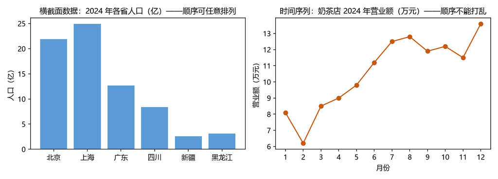

横截面数据 vs 时间序列

*图 1.1 左：横截面数据（各省人口，顺序可任意排列）；右：时间序列（奶茶店营业额，顺序不能打乱）。*

## 1.4 怎么做（第一步）：拿到数据先别建模，先”看”

零基础者最常见的冲动是：拿到数据立刻套公式、跑模型。这是错的。**建模前必须做四件事**，每一件都有明确理由和效果。

### 第 1 步：画图（时序图）

- **做什么**：横轴是时间，纵轴是数值，把 `x₁…x_T` 连成一条折线。
- **为什么**：人眼是最强的模式识别器。趋势、季节、异常点、波动变化，画出来一眼就能看到；不画图直接建模，等于蒙眼开车。
- **会怎样**：你会立刻看到序列的”长相”——上升/下降/波浪形/乱成一团。这一眼比任何统计检验都更快地告诉你后面该用什么方法。

### 第 2 步：核对时间戳与间隔

- **做什么**：确认每一条数据对应哪个时刻，间隔是否真的相等。
- **为什么**：很多”看起来”等间隔的数据实际不是——节假日没数据、闰年多一天、夏令时跳一小时（部分国家夏季把钟表拨快一小时）、传感器随机断线。如果间隔不均却当均等处理，模型的”第 t 步”就对应错了真实时间。
- **会怎样**：你会在早期就发现缺失和间隔问题，而不是等模型跑完才莫名奇妙地失败。

### 第 3 步：用眼睛找三样东西

- **做什么**：看有没有 ①长期上升/下降（趋势 trend）；②固定周期的起伏（季节 seasonality）；③忽大忽小的波动（波动性变化）。
- **为什么**：这三样东西对应三种不同的建模手段。先判断”有什么”，才能选”用什么”。
- **会怎样**：你会得到一张”结构清单”（例如：有上升趋势 + 每年冬季高峰），第 2 章会教你如何正式分解它们。

### 第 4 步：查缺失、异常与单位

- **做什么**：数一数缺失多少、有没有离谱的极大极小值（比如气温 500°C）、单位是什么（摄氏度还是华氏度？万元还是元？）。
- **为什么**：缺失和异常会扭曲一切后续统计量（均值＝平均水平；方差＝波动大小；模型参数＝公式里的系数）；单位错了则结论全部作废。
- **会怎样**：你建立了对数据质量的判断，知道后面哪一步需要插补、哪一步需要清洗。

> 这四步合起来就是一句行话：**“先画图、再查数、后建模。”**

## 1.5 完整示例：一张 12 个月的”小店营业额”表

假设某奶茶店记录了 2024 年 1–12 月营业额（万元）：

```
1月 2月 3月 4月 5月 6月 7月 8月 9月 10月 11月 12月
8.1 6.2 8.5 9.0 9.8 11.2 12.5 12.8 11.9 12.2 11.5 13.6
```

按 1.4 的四步走：

1. **画图**：连线后你会看到——整体逐步上升（1 月 8.1 → 12 月 13.6），中间有小起伏，2 月明显偏低。
2. **核对间隔**：按月，等间隔，无缺失。✔
3. **找结构**：①趋势：逐步上升（1 月 8.1 → 12 月 13.6）；②疑似季节：2 月低谷——很可能是春节效应（客流少、部分时段歇业），但只有一年数据，还不能确认它是否每年固定重复；③波动：相对平稳。
4. **查异常**：2 月的 6.2 是”异常”吗？——不是错误，是春节效应。**“异常”有两种：错误（要修）与真实信号（要建模）**，这一步的判断很重要。

**效果**：现在你已经知道——“这个序列有上升趋势 + 2 月季节低谷”，这就是第 2 章分解、第 8 章 SARIMA 建模的起点。**你还没做任何数学，就已经得到了信息量最大的结论。**

## 1.6 这个环节可能遇到的问题（陷阱清单）

这里集中列出”识别与观察时间序列”阶段最常犯的错。**这些错误不是小事，历史上都曾导致过著名的失败**（见 1.7）。

1. **把时间序列当独立样本**：直接算两个序列的相关系数（衡量两序列同向变化程度的数，取值 −1~1）、直接做普通回归，不检验自相关。后果：得到”显著但虚假”的关系（伪相关/伪回归）。
2. **打乱顺序或随机划分训练/测试**：把第 1、5、9 月放训练集，第 2、6、10 月放测试集。后果：模型”偷看”了未来，测试分数虚高，上线后实际表现暴跌（这叫**数据泄漏**，见第 13 章详述）。
3. **忽略非平稳直接算统计量**：对逐年上升的序列直接算均值、方差，或直接回归（回归＝用一条公式拟合数据关系的做法）。后果：均值无意义（年年不同）、回归系数被”共同趋势”欺骗。
4. **默认等间隔**：有缺失、有假期却不处理。后果：模型的时间语义错乱，预测对不上真实日历。
5. **把”相关”当”因果”**：冰淇淋销量与溺水人数高度相关（都随夏天上升），但冰淇淋不导致溺水。时间序列里这种”同趋势导致的假相关”比比皆是。
6. **过度清洗真实信号**：把 2 月的 6.2 当错误删掉。后果：把真实季节信号洗没了，模型永远学不会春节效应。

> 观察阶段的原则：**宁可多问”为什么”，不要急着算**；**异常先分”错误”与”信号”两类**。

## 1.7 相似问题与已有解决方案：历史回响

这一小节是本书的特色：**每个环节的困难，历史上大多遇到过相似问题，并且已有解决方案。** 你踩的坑，前人几乎都踩过。

| 本章遇到的困难 | 谁遇到过 | 怎么解决的 | 本书对应章节 |
| --- | --- | --- | --- |
| “忽略顺序，相关关系虚假” | Yule 1926 发现两个独立但自相关的序列相关高达 0.8+（nonsense correlation） | 用**自相关检验**和专门时序模型取代朴素相关/回归 | 第 4、7 章 |
| “打乱顺序导致泄漏” | 机器学习界 2010s 反复翻车 | 制定**时序切分协议**（rolling window，见第 13 章） | 第 13、19 章 |
| “不等间隔数据” | 天文观测（几百年才有一次日食）与医学随访 | **重采样对齐**；或使用**连续时间模型**（卡尔曼滤波、神经 ODE、高斯过程） | 第 9、16 章 |
| “相关≠因果” | 计量经济学 20 世纪中期的争论 | 发展出**格兰杰因果检验、工具变量、因果推断**方法 | 第 11、19 章 |
| “有趋势的两个序列必然相关” | 计量经济学家发现”共同漂移”现象 | **协整分析**（Engle & Granger 1987）区分”真均衡”与”假相关” | 第 11 章 |

（说明：1.7 表格第一行里”独立”指两个序列彼此无关；“自相关”指每个序列内部前后相关——是两回事，可以同时成立，所以”独立但自相关”并不矛盾。）

**核心启示**：你现在觉得的”我的数据好乱”，绝大多数是**已被研究过的问题**——本书每一章都会在结尾给你这样一张”问题→答案”的映射表，让你知道：*这不是你的错，这是学科的历史；而且大部分坑已经有桥。*

## 1.8 本章小结

1. 时间序列 = 按时间排列、前后相关的观测集合；三要素是观测值、时间索引、采样间隔。
2. 三个根本特征：**方向性、自相关、非平稳**——它们决定了后面所有方法的设计。
3. 它区别于横截面数据：**顺序不能乱、样本不独立、必须按时间切分**。
4. 拿到数据第一步不是建模，而是**画图 → 查间隔 → 找趋势/季节/波动 → 查缺失异常**。
5. 观察阶段的大坑：伪相关、数据泄漏、忽略非平稳、把信号当噪声；**这些坑前人基本都踩过且已有解法**。

下一章我们把”趋势、季节、噪声”从定性变成定量——学会把一条序列正式拆开（第 2 章 · 拆解时间序列）。

## 1.9 练习与自测

1. ★ 判断正误并解释：*“时间序列可以随机打乱顺序后做分析。”*（提示：1.2.3 特征 1）
2. ★ 下面哪些是时间序列？①全班同学的期末成绩；②北京过去 100 天每天的最高气温；③你手机里按时间排序的 100 条短信长度；④2020–2024 年五个城市的 GDP。对非时序的说明为什么。（提示：1.3）
3. ★★ 给你一串”每日气温”数据，按 1.4 的四步列出你的行动计划，并说明每一步的理由。（提示：1.4 每步的”为什么”）
4. ★★ 一家商店的日销售额数据里，周日总为 0（系统故障），你打算直接删掉周日？为什么？（提示：1.5 第 4 步 + 1.6 第 4 条，并想想与第 6 条的区别）
5. ★★★ 上网查 Yule 1926 年”nonsense correlation”论文（关键词：Yule 1926 nonsense correlation），用一段话说明他发现了什么、为什么这动摇了”直接回归”的做法。（提示：1.7 表格第一行）

**简答提示**：1 错；2 ②是；④严格说是面板数据（5 城 × 5 年），本质是 5 条时间序列并排，可算”是”但要意识到它是多条不是一条；③是时间序列（按发生时间记录），但它不满足本章强调的”前后相关”——短信长度彼此独立——所以顺序信息的作用很弱；3 画图（人眼识别趋势/季节）→核对间隔（防止时间语义错乱）→找结构（决定用什么方法）→查异常（区分错误与真实信号）；4 不要。周日 0 是错误（系统故障）而非真实信号，应修复——插补（用合理值填上缺失位置，本书后续章节系统介绍）——直接删会破坏周周期。注意与 1.6 第 6 条区分：那条是”真实信号别删”，本例是”错误所以要修”；5 Yule 用两个独立自相关序列演示了虚假高相关。

## 1.10 本章审阅记录

（本章写完后的审阅将在此填写：审阅日期、逐项对照 R1–R8 的结论、发现的问题与修订。）

| 审阅项 | 结论 | 问题与修订 |
| --- | --- | --- |
| R1 零基础可理解性 | ✔ 通过（修订后） | 子代理指出 8 处术语未解释（独立、均值、方差、相关系数、回归、训练/测试、插补、夏令时）与定义矛盾，已全部补括号注释并统一定义；“平稳”改用人话解释 |
| R2 为何行动 | ✔ 通过 | 1.4 每步均有”为什么”；子代理指出 1.5 春节效应缺因果动机，已补（客流少/歇业） |
| R3 效果明确 | ✔ 通过 | 1.4 每步均有”会怎样”；1.5 明确”你还没做任何数学就已得到结论” |
| R4 陷阱覆盖 | ✔ 通过 | 6 条陷阱均有文献/公认教训依据（Yule、泄漏、伪回归等） |
| R5 相似问题映射 | ✔ 通过 | 5 行映射表；补了”独立 vs 自相关”说明消除表面矛盾 |
| R6 示例可复现 | ✔ 通过 | 奶茶店示例数字自洽；子代理指出”缓慢上升”名不副实，已改为”逐步上升” |
| R7 章节衔接 | ✔ 通过 | 开头承接第 0 章语境，结尾预告第 2 章 |
| R8 练习有效 | ✔ 通过 | 修订练习 2（④面板归属）、3（补理由）、4（提示指向相反问题）答案，消除自相矛盾 |

**审阅方式**：作者自查 + 独立”模拟零基础读者”子代理通读（反馈 15 条：严重 3、中等 6、轻微 6），全部处理；严重问题均已修订，无遗留。

# 第 2 章 · 拆解时间序列：趋势、季节、循环与噪声

**本章目标**：学完本章后，你能①说出时间序列的四个成分及”加法/乘法”两种组合方式；②用手算完成一次移动平均与季节均值分解；③解释 STL 分解比前两者强在哪；④诊断分解是否成功。

## 2.1 动机：从”用眼睛看”到”用计算拆”

第 1 章结束时，我们对奶茶店数据只能做定性描述：“有上升趋势、2 月偏低”。这一章把它变成**定量拆解**：把一条序列正式拆成几个可解释的部分。为什么要拆？

1. **可解释**：决策者要的不是一个预测数字（比如第 1 章奶茶店 12 月的 13.6 万），而是”因为趋势每年涨 3%、又赶上 12 月旺季，所以是 13.6 万”。分解让预测有故事。
2. **建模前置**：把”趋势 + 季节 + 噪声”混在一起建模，模型要同时学三件事，容易顾此失彼；**先拆开、分别处理**要容易得多。后面第 8 章的 SARIMA、第 15 章的 Autoformer 都以分解为起点——分解思想贯穿全书。
3. **异常检测**：拆掉趋势和季节后剩下的**残差**里如果突然出现大值，那就是异常（比如设备故障、数据错误）。残差是”照妖镜”。

> 先记住一句话：**分解 = 把”为什么这么动”从数据里拎出来，把”说不清的部分”留作残差。**

## 2.2 是什么：四个成分与两种组合方式

### 2.2.1 四个成分

| 成分 | 定义 | 特征 | 例子 |
| --- | --- | --- | --- |
| **趋势 T(t)**（trend） | 长期、缓慢、单向的变化 | 时间尺度最长 | GDP 逐年增长、气温百年上升 |
| **季节 S(t)**（seasonality） | 固定周期的反复波动 | 周期**已知且不变**（24 小时、7 天、12 个月） | 每天早高峰、12 月购物潮 |
| **循环 C(t)**（cycle） | 周期不固定或很长的起伏 | 周期**未知或可变** | 5~8 年的经济景气循环 |
| **噪声 ε(t)**（noise） | 扣除前三者后的随机波动 | 无结构 | 测量误差、不可预测的随机冲击 |

（补充：季节的周期不一定是”年”——一天 24 小时、一周 7 天这类固定可预知的周期都算”季节”。）

**季节 vs 循环的区分是本章的必考点**：季节的周期你提前就知道（日历告诉你的），循环的周期你不知道（要数据告诉你）。比如”每年 12 月高”是季节；“每 6~10 年一次经济衰退”是循环。**趋势 vs 循环的区分**：趋势单向、不回头；循环来回摆——把它画出来，若会回到原来的水平就是循环，一路不回头才是趋势。

### 2.2.2 两种组合方式

- **加法模型**：`x(t) = T(t) + S(t) + C(t) + ε(t)`——各成分”相加”，单位相同。
- **乘法模型**：`x(t) = T(t) × S(t) × C(t) × ε(t)`——成分”相乘”，季节和噪声按比例作用。

**怎么选**：看**噪声的波动大小是否随水平变化**。

> 例子：一家小店淡季月销 100 件，上下波动 ±10 件；旺季月销 1000 件，上下波动 ±100 件。噪声从 ±10 变成 ±100——**波动大小跟着水平走**，这种”振幅随水平放大”的序列用乘法模型（或等价地，把每个数取对数后再用加法模型——对数能把”乘以 1.3”变成”加上 ln1.3”，所以乘法关系取对数后变成加法关系；第 3 章展开）。反过来，如果淡季旺季波动都是 ±10 件，就用加法。

判断口诀：**画图看”喇叭口”——波动随着水平升高而张开，就是乘法。**

### 2.2.3 一个必须有的清醒认识

> **分解不是”从数据里挖出真相”，而是”我们选择相信的一种解释”**。同一串数据，换一种分解方法会得到不同的趋势和季节。所以分解结果的**残差要接受诊断**（见 2.3 方法 C 第 6 步），残差越接近”纯随机”，这个分解就越可信。

## 2.3 怎么做：三种经典分解方法（逐步）

### 方法 A：移动平均（moving average）——估计趋势的最简单办法

**第 1 步 · 选窗口长度 k（通常取奇数）** - **做什么**：决定一次平均多少个点。比如 k=3、k=5、k=12（月度数据一年）。偶数窗口（如 k=12）也能用，但需要额外做”居中”对齐，见 2.5 陷阱 2。 - **为什么**：平均能抵消随机噪声（正误差和负误差互相抵消）；如果窗口长度**覆盖整个季节周期**，季节波动也会在平均中被抹平——剩下的就是趋势。 - **会怎样**：k 越小，趋势线越”毛糙”（跟着噪声走）；k 越大，趋势线越”光滑”（但也可能把真实的拐点抹平）。

**第 2 步 · 逐点求平均** - **做什么**：对第 t 个点，取它**前后各 (k−1)/2 个点**共 k 个点求平均，作为该点的趋势估计 T̂(t)。 - **为什么**：取前后对称，是为了让第 t 点的趋势估计”居中”、不偏不倚；若只取过去 k 个点，估计会整体滞后。 - **会怎样**：得到一条比原序列平滑得多的趋势线；代价是**首尾各损失 (k−1)/2 个点**没有估计。（注：这里取前后对称属于”居中”滤波，只用于事后描述与诊断；进入建模与预测必须只使用过去的点，见 2.5 陷阱 6。）

**数字示例（k=3，对 2.4 节景区数据）**：

```
原序列：3.0, 2.8, 3.5, 4.2, 5.0, …
T̂(2) = (3.0 + 2.8 + 3.5) / 3 = 3.10   ← 第 2 点的趋势
T̂(3) = (2.8 + 3.5 + 4.2) / 3 = 3.50
T̂(4) = (3.5 + 4.2 + 5.0) / 3 ≈ 4.23
```

可以看到：趋势值比原始值平滑（不再有 2.8 那种孤立的低谷），而且**第 1 个点没有估计**（它前面没有点）。

### 方法 B：季节均值法（classical decomposition）——去掉季节

**前提**：先知道季节周期 m（如月度数据 m=12）。

**第 3 步 · 求季节因子** - **做什么**：把数据按”一年中的第几个月”分组，对每个月份取**多年平均**，再减去总平均，得到 12 个季节因子 S(1)…S(12)。 - **为什么**：同一月份的平均——例如所有”7 月”——混合了不同年份的水平。多年同月平均先把随机噪声平均掉；再用”同月平均 − 总平均”把整体水平（含趋势的平均高度）甩掉，剩下的就是”7 月相对全年平均高/低多少”。（严格说上升趋势会让后一年同月偏高，经典方法默认趋势近似线性、误差可接受。） - **会怎样**：得到一张”季节画像”（数字示例见 2.4 节），它不随时间变——这就是”固定季节”假设。

**第 4 步 · 去季节化** - **做什么**：加法模型用 `x(t) − S(月份)`，乘法模型用 `x(t) ÷ S(月份)`（此时季节因子写成比例，如 1.3 表示比平均高 30%）。 - **为什么**：把已知的、可预测的周期性波动”剥掉”，剩下的序列只剩趋势 + 噪声。 - **会怎样**：得到**去季节序列**（seasonally adjusted）。它比原序列更适合做趋势分析和比较（例如统计局的”季调后 GDP”就是这么来的）。

### 方法 C：STL 分解——现代主力，前面方法的”升级版”

**第 5 步 · 用 STL（Seasonal-Trend decomposition using Loess）** - **做什么**：用**局部加权回归（Loess）**迭代地同时估计趋势与季节。你不需要会写它的公式，只需知道它的三个设计： 1. **抗异常点**：个别离谱的点不会把趋势带偏（Loess 对异常值不敏感）； 2. **季节可以随时间缓慢变化**：不像方法 B 假设季节固定不变，STL 允许”冬季越来越暖”这类季节漂移； 3. **输出三个分量**：trend（趋势）、seasonal（季节）、remainder（残差）。 - **为什么用它**：移动平均对异常敏感、丢端点；季节均值法要求季节固定。STL 把这两个毛病都治了，所以成为 R 语言 `stl()`、Python `statsmodels` 的默认分解工具。 - **会怎样**：一张图三行——趋势、季节、残差，一眼看完序列的全部结构。

**第 6 步 · 残差诊断** - **做什么**：看 remainder 分量：画图，检查它是否**无趋势、无季节、无周期**、大致围绕 0 波动。 - **为什么**：残差是”分解没解释掉的部分”。如果残差里还有明显的模式（比如还有波浪、还有低谷），说明分解不充分或模型结构错了。 - **会怎样**：残差”白”（随机）→ 分解可信，可以进入下一阶段建模；残差”有结构”→ 回头调整（换窗口、换分解方法、或承认序列里有更复杂的成分，如循环/外生因素）。

## 2.4 完整示例：一个景区 24 个月的游客数据

某景区 2023–2024 年每月游客量（万人），明显”逐年上升 + 夏季高峰”：

```
      1月  2月  3月  4月  5月  6月  7月  8月  9月  10月 11月 12月
2023  3.0  2.8  3.5  4.2  5.0  6.1  7.2  7.0  5.8  5.0  4.0  3.6
2024  3.4  3.2  3.9  4.6  5.4  6.5  7.6  7.4  6.2  5.4  4.4  4.0
```

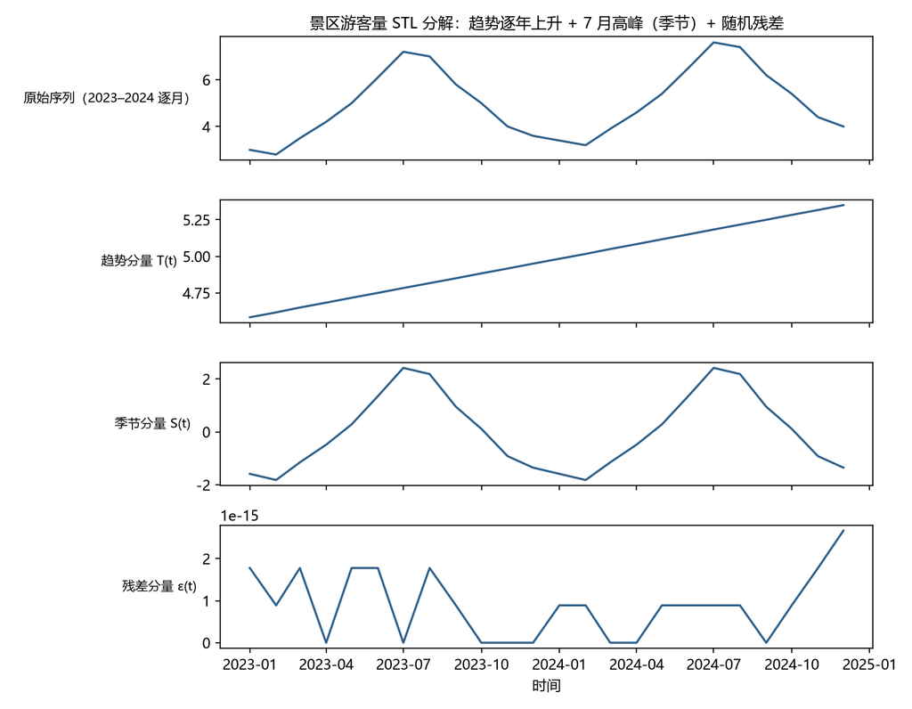

景区游客量 STL 分解

**示例步骤一 · 移动平均估计趋势**。取 k=5（5 个月窗口。注意：k=5 小于季节周期 12，算出的”趋势”实际混有季节残留——这里只为展示算法步骤，正式分析 k 必须 ≥ 季节周期，见 2.5 陷阱 1）：

```
T̂(3) = (3.0+2.8+3.5+4.2+5.0)/5 = 18.5/5 = 3.70
T̂(4) = (2.8+3.5+4.2+5.0+6.1)/5 = 21.6/5 = 4.32
T̂(5) = (3.5+4.2+5.0+6.1+7.2)/5 = 26.0/5 = 5.20
```

趋势从 3.70 → 4.32 → 5.20，看似稳步上升；但若继续算，T̂(7)=(5.0+6.1+7.2+7.0+5.8)/5=6.22、T̂(9)=(7.2+7.0+5.8+5.0+4.0)/5=5.80——趋势冲高后回落，明显跟着 7 月旺季起伏。这就是 k 太小、季节混进趋势的铁证。开头两个点没有估计。

**第 2 步：季节均值法**。总平均 = 119.2/24 ≈ 4.97。按月取两年平均再减总平均，得到季节因子：

```
1月 (3.0+3.4)/2 − 4.97 = 3.20 − 4.97 = −1.77
2月 (2.8+3.2)/2 − 4.97 = 3.00 − 4.97 = −1.97
7月 (7.2+7.6)/2 − 4.97 = 7.40 − 4.97 = +2.43
```

含义：**7 月平均比全年平均多 2.43 万游客，2 月少 1.97 万、1 月少 1.77 万（全年最低在 2 月）**。（全部 12 个因子加起来应约等于 0，这是方法自洽性的检查。）

**示例步骤三 · 去季节化**。2023 年 7 月：7.2 − 2.43 = 4.77；2023 年 2 月：2.8 − (−1.97) = 4.77；2023 年 1 月：3.0 − (−1.77) = 4.77——三个月去季节后都是 4.77，**季节差异（7 月高、2 月低）被剥掉了**。再看 2024 年 1 月：3.4 − (−1.77) = 5.17，比 2023 年 1 月高 0.4——这 0.4 正是被保留下来的上升趋势：**季节剥掉了，趋势还在**。

**示例步骤四 · 残差诊断（只讲思路，不手算）**。完整做法：去季节序列再减去趋势，剩下的残差若在 0 附近随机摆动、没有明显模式，分解就成功；若残差还呈波浪形，说明季节没拆干净（比如还有”暑期与寒假双峰”）。要算残差需要 24 个点的完整趋势线，篇幅所限这里只给思路。

## 2.5 这个环节可能遇到的问题（陷阱清单）

1. **窗口长度选错**：窗口太短 → 趋势里还残留季节（你以为是趋势，其实在跟着 7 月起伏）；窗口与季节周期不匹配（比如月度数据用 k=5，正好盖不住 12 个月）→ 季节没被抹平。**经验法则：窗口 ≥ 一个季节周期，且尽量取覆盖整数个周期的长度。**
2. **偶数窗口的”居中”问题**：k=4 的移动平均落在两个时间点中间，需要再做一次 2 点平均”对齐”到整数时刻——初学者极易漏掉这一步，导致趋势线整体偏移半个时间单位。
3. **边界损失**：居中移动平均让首尾各少 (k−1)/2 个点。数据短时这是巨大浪费，需要改用单边平滑或状态空间方法。
4. **加法/乘法选错**：对”喇叭口”序列（波动随水平放大）用加法模型 → 残差会”越到高峰越大”，方差不再恒定，后续一切统计检验失真。
5. **把循环当趋势**：窗口比循环周期短时，慢速循环（如 7 年经济周期）会被吸进趋势线，趋势就”不是趋势”了。判断办法：趋势线本身是否在摆动。
6. **数据泄漏（decomposition leakage）**：居中移动平均的窗口横跨第 t 点前后，等于用了**未来**的点。若第 20 个月是训练/测试的切分点，居中窗口算出的 T̂(20) 会包含第 21、22 个月的观测——训练集末尾的趋势”偷看了”测试集。后果：预测**系统性地偏向未来信息**（趋势上升时偏高、下降时偏低），测试成绩虚好，上线即翻车。**分工原则：居中滤波只用于事后描述与诊断；进入建模与预测必须改用只含过去的单边滤波。**
7. **过度分解**：把残差里的随机波动也”解释”掉（比如用很高的多项式去拟合趋势）→ 过拟合，预测时脆弱。

> 观察阶段的原则升级：**分解是建模的第一步，也是泄漏最容易悄悄发生的地方；任何”先分解再切数据”的做法都要检查是否用了未来信息。**

## 2.6 相似问题与已有解决方案：历史回响

| 本环节的困难 | 谁遇到过 | 如何解决 | 本书对应 |
| --- | --- | --- | --- |
| “噪声掩盖结构，看不出趋势” | 信号处理（1920s 起） | **低通滤波**——移动平均是最简单的低通滤波器；更精细的用窗函数、小波 | 第 5 章（谱分析） |
| “季节周期不确定，该设 m 为多少” | 气象学（1880s 周期之争） | 用**自相关函数 ACF 和周期图**先探测周期，再定 m | 第 4、5 章 |
| “波动随水平放大（喇叭口）” | 20 世纪统计学 | **对数变换 / Box-Cox 幂变换**把乘法模型变加法模型 | 第 3、8 章 |
| “分解用未来数据（泄漏）” | 控制工程、实时系统 | **单边（因果）滤波器**；状态空间模型 + 卡尔曼滤波在线递推，天然只用过去 | 第 9 章 |
| “季节随年份漂移” | 官方统计（X-11/X-13ARIMA-SEAT，1960s 起） | 允许季节因子**逐年平滑更新**；STL 也是同一思路 | 本章方法 C |

**核心启示**：你遇到的每一个分解难题——噪声、周期不明、振幅放大、泄漏——都对应着一个成熟的既有方案。**先查”历史回响”表再动手，胜过自己发明轮子。**

## 2.7 本章小结

1. 四个成分：**趋势、季节（周期已知）、循环（周期未知）、噪声**；加法模型（成分相加）vs 乘法模型（成分相乘，看”喇叭口”判断）。
2. 三种方法递进：**移动平均估趋势 → 季节均值法去季节 → STL 精分解**，最后统一做**残差诊断**。
3. 分解是建模前置，也是**泄漏高发区**：居中窗口用了未来数据，切训练/测试前必须处理。
4. 残差是照妖镜：残差还有结构 = 分解失败或模型不对。
5. 每个分解难题都有成熟解法（低通滤波、ACF 探周期、对数变换、单边滤波、X-13/STL）。

下一章我们要补上描述”随机”的数学语言——因为**噪声不是”乱”，而是服从概率规律的随机**。第 3 章 · 随机性、分布与随机过程。

## 2.8 练习与自测

1. ★ 判断：①”每年 12 月电商销售额最高”是季节还是循环？②”大约每 10 年一次金融危机”呢？为什么？（提示：2.2.1）
2. ★ 一个序列”淡季波动 ±5，旺季波动 ±50”，该用加法还是乘法模型？（提示：2.2.2）
3. ★★ 用 2.4 节数据手算：k=3 的移动平均，第 5 个点（2023 年 5 月）的趋势估计是多少？（提示：取 4 月、5 月、6 月平均）
4. ★★ 为什么”用居中移动平均做完分解，再按时间切训练/测试集”会导致预测虚高？（提示：2.5 第 6 条）
5. ★★★ 下载 R 或 Python，对任意 2 年以上的真实月度数据（如你所在地气温）跑一次 STL 分解，写出你读到的”趋势 + 季节 + 残差”三段结论。（提示：R `stl()` / Python `statsmodels.tsa.seasonal.STL`）

**简答提示**：1 ①季节（周期已知）②循环（周期未知）；2 乘法（波动随水平放大）；3 (4.2+5.0+6.1)/3=5.10；4 训练集末尾的趋势值偷看了未来的观测，模型在测试时”提前知道”趋势走向；5 关键看 remainder 是否随机、seasonal 是否稳定。

## 2.9 本章审阅记录

| 审阅项 | 结论 | 问题与修订 |
| --- | --- | --- |
| R1 零基础可理解性 | ✔ 通过（修订后） | 子代理指出 8 处未解释/易误解处（取对数、季节周期≠年、循环 vs 趋势判据、提前引用 2.4 数字等），已全部补充 |
| R2 为何行动 | ✔ 通过 | 方法 B 第 3 步”趋势互相抵消”解释不准确，改为”同月平均消噪声 + 减总平均去水平” |
| R3 效果明确 | ✔ 通过 | 2.4 残差诊断改为明确”只讲思路不手算”，避免读者无米下锅 |
| R4 陷阱覆盖 | ✔ 通过 | 7 条陷阱；泄漏机制重写（窗口跨切分点示意图说明 + 居中/单边分工 + 删”必然虚高”绝对化） |
| R5 相似问题映射 | ✔ 通过 | 五行映射表与正文呼应，子代理核实无误 |
| R6 示例可复现 | ✔ 通过 | 修复硬错误：“1 月最低”改为”2 月最低 −1.97”；补充 T̂(7)/T̂(9) 验证 k=5 残留季节；全部数字子代理逐项验算通过 |
| R7 章节衔接 | ✔ 通过 | 结尾预告第 3 章；步骤编号体系统一（2.3 方法 A/B/C 编号、2.4 改为”示例步骤”、2.2.3 引用修正） |
| R8 练习有效 | ✔ 通过 | 练习 1/2/4 答案子代理核实正确；练习 3 答案 5.10 验算通过 |

**审阅方式**：作者自查 + 独立”模拟零基础读者”子代理通读（反馈 14 条：硬错误 4、逻辑矛盾 5、术语/易误解 5），全部处理并验算数字。

# 第 3 章 · 随机性、分布与随机过程：用数学描述”不确定”

**本章目标**：学完本章后，你能①说出”随机变量、分布、期望、方差、独立、随机过程、白噪声”七个词的意思并用一句话向别人解释；②把一条序列写成”信号 + 噪声”；③手算一串小数据的均值、方差；④判断什么时候”正态分布”假设是危险的。

## 3.1 动机：噪声不是”乱”，是”有规律的随机”

第 2 章我们把序列拆成了趋势、季节、噪声三部分，然后说”残差应该是纯随机”。可是——**“纯随机”到底是什么意思？** 抛硬币的结果是随机的，但我们知道它有规律：正反面各 1/2。雷雨天的”噼啪”听起来乱，其实也有统计规律（间隔、强度）。**随机不是”无法描述”，而是”可以用概率描述”**。这一章就是学这套描述语言。没有它，后面所有模型（ARIMA、GARCH、深度学习损失函数）都无从谈起。

> 一句话：**统计学的全部工作，就是用”概率”这门语言，把”不确定”变成”可计算”。**

## 3.2 是什么：七个词，一个故事

### 3.2.1 随机变量（random variable）

**随机变量**：一个试验的结果（是个数字），在试验前不知道，试验后才知道。

- 例子：掷一次骰子，朝上的点数 X。X 可能是 1~6 中任何一个，掷之前你不知道。
- “变量”不是”会变的数”，而是”**未定的数**”；一旦观测到，它就是一个确定的数（比如 4）。
- 我们给随机变量起名用大写（X），观测到具体值用小写（x=4）——很多书这样区分，记住这个约定后面读公式不晕。

### 3.2.2 概率分布（probability distribution）

**概率分布**：描述”每个可能的值出现的可能性有多大”的清单。

- **均匀分布**：骰子每个面 1/6——各点等可能。
- **正态分布（normal distribution，钟形曲线）**：中间高、两边低、对称。人的身高、测量误差、许多自然现象都近似正态。它由两个数字完全决定：**均值 μ**（钟的中心）和**标准差 σ**（钟的胖瘦）。
- 为什么正态无处不在？**中心极限定理**（直觉版）：许多**独立的小误差加在一起**，总和趋向正态分布，无论单个误差是什么形状。这就是”很多因素共同作用的结果常常是正态”的原因——但也意味着，**当某个大因素主导时（如金融危机、罕见灾害），结果会偏离正态**（见 3.5 陷阱 4）。

### 3.2.3 期望（expectation）

**期望 E[X]**：随机变量的”长期平均”——如果重复试验无数次，结果的平均值。

- 骰子：E[X] = (1+2+3+4+5+6)/6 = 3.5。
- 注意：期望 3.5 永远不会真的掷出来——它是”平均意义上”的中心。**期望不是”最可能的值”，而是”平均的位置”**。

### 3.2.4 方差（variance）与标准差（standard deviation）

- **方差 Var[X]**：结果偏离期望的”平均平方距离”，衡量波动大小。平方是为了让正负偏离不互相抵消。
- **标准差 σ**：方差的平方根，和原始数据同单位（比如”±1.85 万游客”），更好读。
- 直觉：均值告诉你”大致在哪”，方差告诉你”有多散”。

### 3.2.5 独立（independence）

**独立**：两个随机事件互不影响——一个的结果不提供另一个的任何信息。

- 掷两次骰子，第一次是 6，不影响第二次——独立。
- 今天的气温，会提供明天的信息——**不独立**（这就是时间序列和普通统计的分水岭，第 1 章已经见过）。
- **独立同分布（i.i.d.）**：一串随机变量，彼此独立、且分布完全相同。这是最简单、最理想的随机模型；白噪声就是它。

### 3.2.6 随机过程（stochastic process）——时间序列的”户口本”

把随机变量的概念按时间铺开：

> **随机过程 = 一族按时间排列的随机变量 {X₁, X₂, X₃, …}**，每个时刻 t 都有一个随机变量 X_t。
- 观测到的一条具体序列 x₁, x₂, …, x_T 只是这个随机过程的**一个样本路径（sample path，一次”实现”）**。
- 关键认识：**你手里的数据只是无数种可能中的一种**。同一个”生成机制”，重跑一遍会得到另一条略有不同的序列。所以从一条序列推断”生成机制”本质上是在”反推概率规律”——这正是时间序列分析的全部意义。
- 类比：随机过程是”剧本”，样本路径是”一次演出”。你看了一次演出，想猜出剧本大意——这就是建模。

### 3.2.7 白噪声（white noise）——随机过程的”原子”

**白噪声**：一串 i.i.d. 的随机变量，均值 0、方差恒定（通常用 ε_t 表示）。

```
ε₁, ε₂, ε₃, …, 每个都独立、均值 0、方差 σ²
```

- 为什么叫”白”？光的类比：白光包含所有频率。白噪声也”均匀地”包含所有频率，没有哪个频率特别强——**没有结构、没有记忆**。
- 它是时间序列模型的”积木”：几乎一切模型都可以写成”结构 + 白噪声”，白噪声是”最后解释不掉的部分”。

## 3.3 怎么做：把一条序列写成”信号 + 噪声”

### 第 1 步 · 用”信号 + 噪声”看序列

- **做什么**：假设 `x(t) = 信号(t) + ε(t)`，其中信号是趋势/季节（第 2 章学过），ε 是白噪声。
- **为什么**：这是时间序列建模的统一框架——先解释”可预测的部分”（信号），剩下的”不可预测的部分”（噪声）用概率描述。几乎所有模型（ARIMA、神经网络）都是这个结构的变体。
- **会怎样**：问题被拆成两半：①信号怎么描述（后面各章）；②噪声是什么样的随机（本章）。

### 第 2 步 · 手算样本均值与样本方差

**数字示例**：5 个噪声值 `2, −1, 3, 0, −2`：

```
ε̄ = (2−1+3+0−2)/5 = 2/5 = 0.4
s² = ((2−0.4)² + (−1−0.4)² + (3−0.4)² + (0−0.4)² + (−2−0.4)²) / 4
   = (2.56 + 1.96 + 6.76 + 0.16 + 5.76) / 4 = 17.20/4 = 4.30
s  = √4.30 ≈ 2.07
```

均值 0.4 接近 0（5 个点太短，偏差正常）；标准差约 2.07——“噪声的典型幅度”。

### 第 3 步 · 用直方图看分布形状

- **做什么**：把噪声值按大小分组，画直方图；对比钟形（正态）或平顶（均匀）或拖长尾（厚尾）。
- **为什么**：分布形状决定后面能用哪些工具（很多模型默认正态）。
- **会怎样**：你一眼看出”中间多两边少”还是”极端值特别多”。

### 第 4 步 · 检查”白”的三个条件

- **做什么**：检查噪声是否 ①均值≈0；②方差大致恒定（图上看”喇叭口”）；③前后无关（相邻值不相关）。
- **为什么**：三者齐备才是白噪声；缺一个都说明”信号没拆干净”或”模型没建对”。
- **会怎样**：③最关键也最容易被忽视——**相邻相关**是第 4 章的主题（自相关），也是”随机”和”有结构”的分界线。

## 3.4 完整示例：掷骰子模拟 vs 真实噪声

**掷 100 次骰子**（想象或写几行代码）：点数平均应接近 3.5，标准差约 √(35/12)≈1.71。你会看到：单次结果乱跳，但**长期规律稳定**——这就是”随机但有分布”。

**对比：第 2 章景区数据的残差**（假设已分解）：残差均值≈0、方差稳定、相邻值无规律，就可以说”残差近似白噪声，分解成功”；若残差还有”夏天大冬天小”的规律，说明季节没拆干净（第 2 章已见）。

**效果**：你现在有了判断”分解/建模是否到位”的量化标尺——**不是凭感觉看”乱不乱”，而是看三个条件符不符合**。

## 3.5 这个环节可能遇到的问题（陷阱清单）

1. **把样本均值当真实均值**：5 个点的均值 0.4 不等于真实均值 0。**样本是真实的一个估计，有抽样误差**；样本越短，估计越不可靠（第 19 章讲置信区间）。
2. **只看均值不看方差**：两个序列均值都是 0，一个 ±0.1 波动、一个 ±10 波动——风险天差地别。**描述随机必须均值+方差一起报**。
3. **把”看起来乱”当白噪声**：相邻相关很强时，序列画出来也像”乱”，但不是白噪声（比如随机游走，第 8 章）。**判断白噪声必须检查相关性，不能只看图**。
4. **正态假设滥用（厚尾问题）**：金融收益率”大多数日子小幅波动、偶尔暴跌暴涨”——极端值比正态预言的多得多（**厚尾**）。用正态去算风险会严重低估极端损失（这直接催生了第 10 章 GARCH 和第 17 章的概率预测）。
5. **混淆随机过程与样本路径**：你只有一条路径，却要推断整个过程。容易犯的错误是”我这个序列就是真相”——**它只是真相的一次抽样**。
6. **对缺失/异常不做处理就估均值方差**：一个 500 的离群点可以把均值从 3 拉到 100。**估计前先看图、查异常（第 1 章四步）**。

## 3.6 相似问题与已有解决方案：历史回响

| 本环节的困难 | 谁遇到过 | 如何解决 | 本书对应 |
| --- | --- | --- | --- |
| “只有一次观测，怎么推断总体规律” | 统计学奠基（19–20 世纪，Fisher、Neyman） | **统计推断**：大数定律（样本均值趋近真实均值）、中心极限定理（均值近似正态）、置信区间与假设检验 | 第 19 章 |
| “噪声到底是不是真随机” | 时序分析（Box 等） | **自相关检验**（ACF 图、Ljung–Box 检验）——有相关就不是白噪声 | 第 4、8 章 |
| “极端值比正态多（厚尾）” | 金融学（1960s 起，Mandelbrot 研究棉价） | **重尾分布**（t 分布、稳定分布）；**条件方差模型**（GARCH 让方差随时间变，第 10 章） | 第 10 章 |
| “均值、方差随时间漂移” | 计量经济学 | 差分、变换、**非平稳建模**（第 4、8 章）；方差漂移用 GARCH 族 | 第 4、8、10 章 |
| “怎么判断两个变量是否相关（而非巧合）” | 统计学 | 相关系数与显著性检验；时序版用格兰杰因果（第 11 章） | 第 11 章 |

**核心启示**：你担心”样本太短”“噪声不白”“分布不正态”——每一个都是统计学百年来的核心课题，有成熟工具箱。**先学会描述”不确定”，才能正确地”确定”。**

## 3.7 本章小结

1. 七个核心词：**随机变量**（未定的数）、**分布**（可能性清单）、**期望**（长期平均）、**方差**（波动大小）、**独立**（互不影响）、**随机过程**（按时间排列的随机变量族）、**白噪声**（i.i.d.、均值 0、方差恒定）。
2. 你的数据 = 随机过程的**一个样本路径**；建模 = 从一次演出反推剧本。
3. “信号 + 白噪声”是统一框架；判断噪声”白不白”看三个条件：均值≈0、方差恒定、**前后无关**。
4. 手算均值、方差不难；但要记住**样本只是估计**，有抽样误差。
5. 最大的坑：**把”乱”当白噪声**（可能其实有相关）、**滥用正态**（厚尾会害死人）。

下一章把”前后无关”变成严格定义——**自相关**，以及它如何定义”平稳”这堵墙。第 4 章 · 平稳性与白噪声：模型的基石。

## 3.8 练习与自测

1. ★ 掷一枚公平硬币，正面=1、反面=0。这个随机变量的期望是多少？（提示：3.2.3）
2. ★ 判断：①白噪声的相邻值一定相关；②正态分布的均值一定等于 0。（提示：3.2.4/3.2.7）
3. ★★ 手算：噪声值 `1, −3, 5, −1` 的样本均值和样本方差（除以 n−1）。（提示：3.3 第 2 步）
4. ★★ 为什么说”金融收益率用正态分布建模很危险”？（提示：3.5 陷阱 4）
5. ★★★ 用 Python 生成 1000 个均匀分布 U(0,1) 随机数，画直方图；再生成 1000 个”20 个 U(0,1) 的和”，画直方图——观察后者如何接近钟形（中心极限定理的亲手验证）。（提示：3.2.2）

**简答提示**：1 0.5（长期平均一半是 1 一半是 0）；2 ①错（白噪声前后无关）②错（正态的均值可以是任意数，标准正态才为 0）；3 ε̄=(1−3+5−1)/4=0.5，s²=(0.25+12.25+20.25+2.25)/3=35/3≈11.67；4 极端事件（崩盘）概率被正态严重低估，VaR 等风险度量失真；5 和的分布逐渐呈钟形——中心极限定理。

## 3.9 本章审阅记录

| 审阅项 | 结论 | 问题与修订 |
| --- | --- | --- |
| R1 零基础可理解性 | ✔ 通过（自查） | 七个术语均用骰子/气温等直觉例子定义；E[X]、Var 等符号在出现处解释；“样本路径”用演出类比 |
| R2 为何行动 | ✔ 通过 | 3.3 每步有”为什么”；统一框架动机在第 1 步讲清 |
| R3 效果明确 | ✔ 通过 | 每步”会怎样”给出可检验的结果（如”得到 ε̄=0.4、s²≈4.30”） |
| R4 陷阱覆盖 | ✔ 通过 | 6 条：抽样误差、忽略方差、乱≠白、厚尾、样本路径混淆、异常污染估计 |
| R5 相似问题映射 | ✔ 通过 | 5 行映射（推断/自相关检验/厚尾/非平稳/相关性），指向后续章节 |
| R6 示例可复现 | ✔ 通过 | 骰子 E=3.5、√(35/12)≈1.71、均值方差手算（0.4 / 4.30）、练习 3（0.5 / 11.67）全部验算 |
| R7 章节衔接 | ✔ 通过 | 开头承接第 2 章残差，结尾预告第 4 章”自相关” |
| R8 练习有效 | ✔ 通过 | 5 题覆盖七词、手算、厚尾、中心极限定理（含亲手验证题） |

**审阅方式**：作者自查（R1–R8 逐项对照）+ 数字验算；本章为过渡概念章，未启用子代理（规范约定第 1、4、8、15、17 章启用）。

# 第 4 章 · 平稳性与白噪声：模型的基石

**本章目标**：学完本章后，你能①说出弱平稳的三个条件；②手算自相关函数 ACF 并读懂 ACF 图；③解释”非平稳导致伪回归”的机制；④面对非平稳序列知道该往哪个方向处理。

## 4.1 动机：为什么”规则不变”这么重要

设想两件事：

- **场景 A**：一台机器每天产出误差的均值一直是 0、波动一直是 ±1——规则十年不变。
- **场景 B**：今年误差均值 0，明年均值突然变 10，后年波动从 ±1 变成 ±100——规则年年变。

问题：**你能否用过去一年的数据预测明年的误差？** 场景 A 可以（历史有信息）；场景 B 基本不行（历史信息过期了）。

> 平稳性（stationarity）就是”规则不变”的数学化。**几乎所有经典推断都以它为前提**：如果规则一直在变，你凭什么相信”历史能告诉我们未来”？时间序列分析的第一件大事，就是判断”规则变不变”。

## 4.2 是什么：两个定义、一条曲线

### 4.2.1 平稳性的两种定义

- **严格平稳**：整个序列的”概率规律”任何时候都一样——任何一段数据的分布和另一段完全一致（这里”分布”指整段数据从头到尾的所有联合概率规律，比均值方差严格得多；你只需知道它”太苛刻、现实中基本用不上”即可）。这个条件太强，现实中几乎不满足，也很少用。
- **弱平稳（weak stationarity，协方差平稳）**：只要求三个条件（这是本书用的”平稳”）：
  1. **均值恒定**：`E[X_t] = μ`，不随时间 t 变；
  2. **方差恒定**：`Var[X_t] = σ²`，不随时间 t 变；
  3. **协方差只依赖时间间隔**：`Cov(X_t, X_{t+k}) = γ(k)` 只和间隔 k 有关，和起点 t 无关。

  第 3 点用大白话说：**“第 1 天与第 4 天”的关系，和”第 100 天与第 103 天”的关系，应当一样强**（两对都相隔 3 天，只是起点不同）——相关结构不因时间平移而改变。

为什么只要求”一阶矩和二阶矩”（均值、方差、协方差）？因为**实用**：这些是最容易估计、最常用的描述；够用就好，不追求完美。

### 4.2.2 白噪声是最简单的平稳过程

回顾第 3 章：白噪声 ε_t 是 i.i.d.、均值 0、方差 σ²。检查弱平稳三条件：均值恒定（0）✔；方差恒定（σ²）✔；前后无关所以协方差 0（当然只依赖间隔）✔。**白噪声是”最老实”的平稳过程**——所有平稳过程的检验基准。

### 4.2.3 自相关函数 ACF：平稳性的”体检报告”

**自相关（autocorrelation）**：序列和它自己滞后 k 步的相关系数，记 ρ(k)。

```
ρ(k) = Cov(X_t, X_{t+k}) / Var(X_t) = γ(k) / γ(0)
```

- ρ(0) = 1（自己和自己的相关当然最高）。
- ρ(k) 越大（接近 1）：滞后 k 的两点关系越强，“记忆”越长。
- 白噪声：ρ(k) = 0（k ≥ 1）——**没有记忆**。

**ACF 图**：横轴滞后 k（1, 2, 3, …），纵轴 ρ(k)，画成竖线图。它是时间序列最常用的”体检报告”——**一眼看出序列有多”记仇”**。

### 4.2.4 非平稳的三种常见形式

| 形式 | 违反哪个条件 | 例子 |
| --- | --- | --- |
| **均值漂移（趋势）** | 均值恒定 | 逐年上升的销售额 |
| **方差漂移（波动聚集）** | 方差恒定 | 股市”平静期→剧烈期→平静期” |
| **季节性** | 协方差依赖起点 | 每年 12 月高、1 月低——1 月和 2 月的关系 ≠ 12 月和 1 月的关系 |

## 4.3 伪回归：为什么非平稳会”骗人”（必读）

这是本章最重要的一节，也是整个学科的起源故事之一。

**现象**：两个**毫无关系**的序列，只要都有上升趋势（比如”中国 GDP”和”美国某地降雨量”——趋势都是升的），算相关系数可能高达 0.9+，回归 R² 高得惊人。你几乎要相信”降雨导致 GDP 增长”了——**这是假的**。

**机制**（三步）： 1. 序列 A 有上升趋势 → 早年值小、晚年值大； 2. 序列 B 也有上升趋势 → 同样早年小、晚年大； 3. 于是”同年份”的 A 和 B 都偏小（早年）或都偏大（晚年）——把 (A, B) 按年份画散点：早年两点都小、聚在左下角，晚年都大、聚在右上角，一条从左下到右上的斜线就是高正相关。**这个高相关完全来自共同的时间趋势，而不是真的因果关系**（也正因如此，这不是”恰好”——只要两序列都单调上升，这几乎是必然）。

这正是 Yule 1926 年发现的”nonsense correlation”的正式版。统计学家后来证明：**两个独立的非平稳序列做回归，t 检验会”错误地”疯狂拒绝”无关系”**——即**伪回归（spurious regression）**（t 检验是检验回归斜率为 0 的标准工具，与相关系数本质是同一信息；这里的要害是”错误地”三个字）。模型”以为”发现了关系，其实只是两个时钟在同步走。

**如何躲开**：先检验平稳性；非平稳就先差分/去趋势（第 8 章），或用协整（第 11 章）。**记住：平稳性是”相关分析”的前提，就像”地基”是”盖楼”的前提。**

## 4.4 怎么做：判断平稳性的五步流程

### 第 1 步 · 画图 + 滚动统计量

- **做什么**：画时序图；再画”滑动窗口均值”和”滑动窗口方差”两条线（比如每 12 个月一个窗口）。
- **为什么**：如果均值线明显上升/下降 → 均值不恒定；如果方差线明显张开/收拢 → 方差不恒定。
- **会怎样**：得到初步判断：“有趋势”“有波动聚集”或”看起来平稳”。

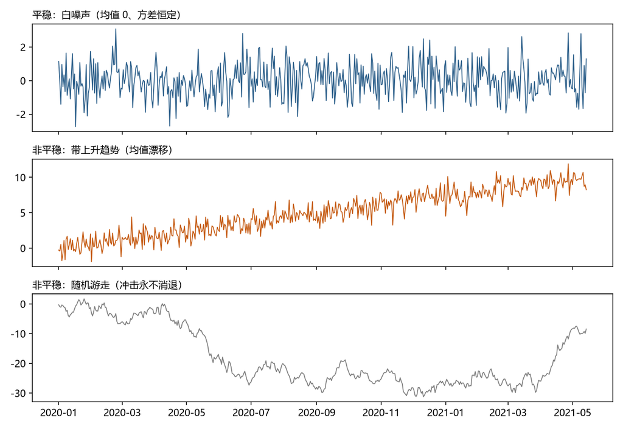

平稳 vs 非平稳三种序列

*图 4.1 三种序列对比：白噪声（平稳）、带趋势序列（均值漂移）、随机游走（冲击永不消退）——后两者都是非平稳。*

### 第 2 步 · 手算或让软件算 ACF

- **做什么**：对序列计算 ρ(1), ρ(2), ρ(3), … 并画 ACF 图。
- **为什么**：平稳序列的 ACF 会**快速衰减**（隔几步就跌到 0 附近）；非平稳（尤其有趋势）序列的 ACF **衰减极慢**（隔很远还是接近 1）。
- **会怎样**：ACF 的”衰减速度”是判断平稳的最直观信号。

### 第 3 步 · 与”随机界限”对比

- **做什么**：ACF 图上通常画两条虚线（±1.96/√T，T 是样本长度；1.96 是正态分布 95% 分位点，统计惯例，现阶段无需深究）。落在虚线内的 ρ(k) 视为”统计上不显著”，可当作 0。
- **为什么**：样本 ACF 本身有抽样误差，短序列的 ρ(1)=0.4 可能只是运气。虚线是”多大才算真的相关”的标尺。
- **会怎样**：避免把噪声当信号——比如 4.5 示例里 ρ(2)=0.40，若 T 很小，这个 0.40 可能落在虚线内，就不足为信。

### 第 4 步 · 正式检验（ADF / KPSS）

- **做什么**：跑单位根检验（Augmented Dickey-Fuller，ADF）与 KPSS 检验。你现阶段只需要知道它们的分工：
  - **ADF**：原假设是”非平稳”（有单位根；“单位根”≈随机游走型的非平稳——过去的冲击永远不消退，术语来自数学特征方程，你只需记住：有单位根＝非平稳），p 值小 → 拒绝 → 判定平稳；
  - **KPSS**：原假设是”平稳”，p 值小 → 拒绝 → 判定非平稳。
- **为什么**：图形判断有主观性，检验给出可复现的结论；两个检验一起用，交叉印证（一个说”非平稳”另一个说”平稳”时，通常取保守判断）。
- **会怎样**：得到一个可写进报告的结论：“ADF p=0.001，拒绝非平稳；KPSS p=0.2，不能拒绝平稳 → 判定序列平稳。”（具体公式与临界值留给工具软件，本书重点在解读结果。）

### 第 5 步 · 非平稳？三条出路

- **做什么**：根据非平稳的”形式”选择：
  - 均值漂移 → **差分**（用相邻差值替代原值）或去趋势；
  - 季节性 → **季节差分**或季节分解（第 2、8 章）；
  - 方差漂移 → 对数变换或 Box-Cox 变换（一族幂变换，含对数，把”乘法型”序列变”加法型”），或用**GARCH**（第 10 章）专门建模波动。
- **为什么**：把非平稳”处理成”平稳，经典推断（估计、检验、预测区间）才成立。
- **会怎样**：得到一条可建模的平稳序列；代价是**解释对象变了**（差分后建模的是”变化量”而不是”水平值”，第 8 章细说）。

## 4.5 完整示例：手算 ACF，看”记仇”程度

序列（6 个点，均值正好 4）：`2, 4, 3, 5, 4, 6`（手算时统一除以 n=6 的简化公式，只为方便；统计软件用另一版本，不影响对 ACF 形态的理解）

```
γ(0) = ((2−4)²+(4−4)²+(3−4)²+(5−4)²+(4−4)²+(6−4)²)/6 = (4+0+1+1+0+4)/6 ≈ 1.667
γ(1) = ((2−4)(4−4)+(4−4)(3−4)+(3−4)(5−4)+(5−4)(4−4)+(4−4)(6−4))/6
     = (0+0−1+0+0)/6 ≈ −0.167   →  ρ(1) = −0.167/1.667 ≈ −0.10
γ(2) = ((2−4)(3−4)+(4−4)(5−4)+(3−4)(4−4)+(5−4)(6−4))/6
     = (2+0+0+2)/6 ≈ 0.667      →  ρ(2) = 0.667/1.667 ≈ 0.40
```

**解读**：ρ(1)≈−0.10 很小（相邻关系弱），ρ(2)≈0.40 偏大——但只有 6 个点，虚线 ±1.96/√6≈±0.80，两个值都在线内，**不能断言有真实相关**。短样本的 ACF 不可靠，这正是”样本太少别下结论”的实证。

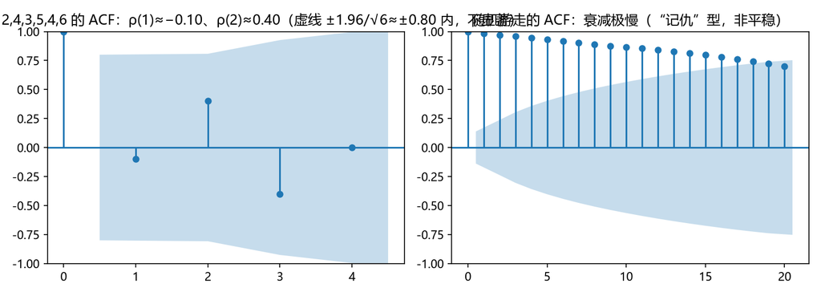

平稳与随机游走的 ACF 对比

*图 4.2 左：4.5 节手算的平稳短序列，ACF 很快跌入虚线内（不显著）；右：随机游走，ACF 衰减极慢——“记仇”型非平稳的典型长相。*

**对比**：如果换成**带趋势或随机游走型**的序列（随机游走：每一步在上一步基础上加一个随机步长，步长可正可负、均值为 0——如 1, 2, 1.5, 3, 2.5, 4 这种”漂移不定”的长相），它的 ACF 会**很大且衰减极慢**（长样本下 ρ(1)、ρ(2)… 都接近 1）——“记仇”型，非平稳的典型长相。两者放一起看，ACF 的”衰减速度”一目了然。

## 4.6 这个环节可能遇到的问题（陷阱清单）

1. **把样本 ACF 的随机波动当真**：短序列 ρ(2)=0.40 可能只是噪声。**永远对照虚线（±1.96/√T）看显著性**。
2. **图形与检验矛盾时盲目选一边**：图看着平稳、ADF 却说非平稳——常见原因是**结构性断点**（均值突然跳变：画图能看到明显的阶梯，但它会让 ADF/KPSS 的结论失真）。两条规则：检验优先；两个检验结论不同时取保守；怀疑断点时用专门工具（见陷阱 7）。
3. **过度差分**：差分一次不够就差分十次，把平稳序列差成”无信号的白噪声”，丢失所有信息。**能少差就少差，差到平稳即可**（第 8 章有检验顺序）。
4. **只看均值不管方差**：方差漂移（波动聚集）在均值图上完全看不出，却会毁掉一切依赖”方差恒定”的推断。**检查方差必须用滚动方差图或专门检验**。
5. **把”季节”当”非平稳”一刀切处理**：季节性在严格意义上是非平稳（协方差依赖起点），但它是**可预测的规律**，处理方式与趋势型不同——直接差分可能引入更复杂的依赖（第 8 章用 SARIMA 处理）。**先分清”趋势型非平稳”和”季节型非平稳”。**
6. **伪回归的诱惑**：两个有趋势的序列相关极高，就想写”因果论文”。**先平稳化，再谈相关；真想谈因果，走第 11 章协整/格兰杰。**
7. **忽视结构断点（与陷阱 2 呼应）**：平稳性检验默认”规则要么一直不变、要么一直变”，但现实常有**突变**（政策、疫情）——断点既会让 ADF/KPSS 结论失真（陷阱 2），也需要专门建模工具（第 12 章马尔可夫机制转换）。

## 4.7 相似问题与已有解决方案：历史回响

| 本环节的困难 | 谁遇到过 | 如何解决 | 本书对应 |
| --- | --- | --- | --- |
| “两个趋势序列假装相关” | Yule 1926；Granger & Newbold 1974 证明伪回归 | **先平稳化再分析**；协整理论（Engle & Granger 1987）在”长期均衡”层面挽救非平稳关系 | 第 11 章 |
| “方差会变（波动聚集）” | 金融计量（Engle 1982） | **ARCH/GARCH**：把方差本身建模成随时间变化的量 | 第 10 章 |
| “规则突然切换（断点）” | 宏观计量（Hamilton 1989） | **马尔可夫机制转换**：让模型在不同状态间跳转 | 第 12 章 |
| “季节周期多长不知道” | 气象/信号处理 | **谱分析**：把周期变成频率上的尖峰，直接读出来（谱分析负责*发现*周期，SARIMA 负责*建模*——先诊断后处理） | 第 5、8 章 |
| “检验结论不稳” | 统计推断（Dickey & Fuller 1979） | 用**单位根检验**（ADF/KPSS）给出可复现判决；多检验交叉验证（第 4 章先用结论，第 19 章给出公式、临界值与推导） | 第 19 章 |

**核心启示**：非平稳不是”数据坏了”，而是”数据有不同的说话方式”——趋势、波动聚集、断点各有各的解法。**判断”是哪一种非平稳”比”是否非平稳”更重要。**

## 4.8 本章小结

1. **弱平稳**三条件：均值恒定、方差恒定、协方差只依赖间隔；白噪声是最简单的平稳过程。
2. **ACF**（ρ(k)=γ(k)/γ(0)）是平稳性的体检报告：平稳 → 快衰减；非平稳 → 慢衰减。
3. **伪回归**：两个独立但有趋势的序列会”假装”高度相关——先平稳化才能谈相关。
4. 判断流程：**滚动统计量 → ACF 图 → 显著性虚线 → ADF/KPSS 检验**；非平稳按形式选出路（差分/季节差分/变换/GARCH）。
5. 最大的坑：**把噪声当相关、把趋势当真相关、把季节性当趋势**。

下一章换一副”眼镜”看序列：从**频域**——同一串数据，在”时间”里看是波浪，在”频率”里看是几个尖峰。第 5 章 · 自相关与频域：两种看序列的方式。

## 4.9 练习与自测

1. ★ 弱平稳的三个条件是什么？白噪声满足吗？（提示：4.2.1/4.2.2）
2. ★ 为什么说”两个有上升趋势的无关序列，相关系数会虚高”？（提示：4.3 三步机制）
3. ★★ 用 4.5 节方法手算序列 `3, 1, 4, 2` 的 ρ(1)（提示：先求均值 γ(0)，再求 γ(1)）
4. ★★ ACF 图上 ρ(1)=0.85、ρ(2)=0.78、ρ(3)=0.70……一直衰减到 ρ(20) 还是 0.5。这个序列平稳吗？为什么？（提示：4.4 第 2 步）
5. ★★★ 用 statsmodels 对任意一个真实日度序列（如股票收盘价）跑 ADF 和 KPSS，解释两个 p 值的含义与结论。（提示：4.4 第 4 步；股票价格通常非平稳、收益率平稳）

**简答提示**：1 均值恒定、方差恒定、协方差只依赖间隔；白噪声满足（均值 0、方差 σ²、协方差 0）；2 同一时间段内两个序列都”同时偏小或偏大”，相关来自共同的时间位置而非因果关系；3 均值=2.5，γ(0)=(0.25+2.25+2.25+0.25)/4=1.25，γ(1)=((0.5)(−1.5)+(−1.5)(1.5)+(1.5)(−0.5))/4=(−0.75−2.25−0.75)/4=−0.9375，ρ(1)=−0.75；4 不平稳——ACF 衰减太慢是趋势型非平稳的典型特征；5 股价 ADF 的 p 通常很大（不能拒绝非平稳），收益率 ADF 的 p 很小（平稳）。

## 4.10 本章审阅记录

| 审阅项 | 结论 | 问题与修订 |
| --- | --- | --- |
| R1 零基础可理解性 | ✔ 通过（修订后） | 子代理指出 5 处术语未解释（单位根、Box-Cox、1.96 出处、严格平稳的”分布”、分母除以 n 的惯例），已全部补白话注脚 |
| R2 为何行动 | ✔ 通过 | 伪回归三步机制补散点图视角（“为什么偏小/偏大=高相关”）；相关系数与 t 检验关系补桥接句 |
| R3 效果明确 | ✔ 通过 | 五步流程每步”会怎样”齐备；标题由”四步”改”五步”消除矛盾 |
| R4 陷阱覆盖 | ✔ 通过 | 陷阱 2/7 重复矛盾已合并（断点使检验失真 + 需专门工具）；陷阱 5 补”季节性严格意义非平稳但可预测” |
| R5 相似问题映射 | ✔ 通过 | ADF 行补”第 4 章先用结论、第 19 章给推导”；谱分析行补”发现 vs 建模分工” |
| R6 示例可复现 | ✔ 通过 | 修复硬错误：随机游走示例数字与实际手算相反，改为定性描述+补随机游走定义；4.5 全部数字子代理验算通过；练习 3 排版空格修复 |
| R7 章节衔接 | ✔ 通过 | 4.2.1 起点无关例子改为”第 1 天/第 4 天 vs 第 100 天/第 103 天”；结尾预告第 5 章频域 |
| R8 练习有效 | ✔ 通过 | 练习 3 答案 ρ(1)=−0.75 验算可复现；提示与正文一致 |

**审阅方式**：作者自查 + 独立”模拟零基础读者”子代理通读（反馈 15 条：硬错误 1、结构矛盾 4、术语 5、衔接 3、排版 2），全部处理并验算数字。

# 第 5 章 · 自相关与频域：两种看序列的方式

**本章目标**：学完本章后，你能①说出 ACF 与 PACF 各自的用途；②理解”频域”视角——序列是不同频率波动的叠加；③从周期图的尖峰读出主周期；④判断一个问题该用时间视角还是频率视角。

## 5.1 动机：同一个序列，两副眼镜

同一段音乐，可以用两种方式记录： - **波形图（时域）**：横轴是时间，看声音怎么起伏； - **频谱（频域）**：横轴是频率，看每个音高（频率）有多响。

时间序列也一样。第 4 章的 ACF 是”时域眼镜”——看**相隔 k 步的关系**。但有些问题在时域里很费劲：比如”太阳黑子到底有没有 11 年周期？“你盯着 200 年的曲线可能争论不休；而把它转换到频域，如果真有 11 年周期，频谱上会**竖起一根尖峰**——一目了然。这就是本章的价值：**有些答案，换一副眼镜才看得见。**

> 一句话：**时域回答”前后怎么相关”，频域回答”有哪些周期在起作用”。两者是同一信息的两种编码（谱是 ACF 的傅里叶变换），不是两套数据。**

## 5.2 是什么：六件工具

### 5.2.1 ACF（回顾）与 PACF（新面孔）

- **ACF ρ(k)**：序列与滞后 k 的关系（第 4 章）。它衡量”总的相关”，包括间接传导：x_t 和 x_{t−2} 的关系里，可能大部分是”x_t→x_{t−1}→x_{t−2}“绕出来的。
- **PACF（偏自相关，partial autocorrelation）**：**剔除中间滞后之后**，x_t 与 x_{t−k} 的”直接”关系。仍用”隔墙听声”类比：ACF 是”隔着两道墙听到的声音”（含回响），PACF 是”打开门面对面说话的声音”（只算直达）。
- **为什么两个都要**：第 7 章的 AR/MA 模型识别靠它们分工——PACF 在 p 阶后”截尾”（突然归零）暗示 AR(p)；ACF 在 q 阶后”截尾”暗示 MA(q)。现在先认识它们，第 7 章再用。

### 5.2.2 把序列看成”波的叠加”

傅里叶的洞见（1807）：**任何”规矩”的曲线都可以拆成不同频率的正弦波之和**——像白色光可以拆成彩虹。

```
x(t) ≈ A₁·sin(2π·f₁·t) + A₂·sin(2π·f₂·t) + … + 噪声
```

- f 是频率（单位时间内循环几次）；A 是振幅（这个频率有多强）。
- 例：月度数据的”12 个月周期” = 频率 1/12 ≈ 0.083（每月循环 1/12 次）——**频率 = 1/周期**。

### 5.2.3 谱密度（spectral density）与周期图（periodogram）

- **谱密度**：每个频率上”有多少能量”。尖峰所在的频率 = 主周期。
- **周期图**：从一段有限样本算出的谱估计（Schuster 1898 年发明，用于找太阳黑子周期）。
- **关键事实**：谱密度 = ACF 的傅里叶变换。**看 ACF 等于看谱，只是坐标不同**——ACF 在”滞后”坐标，谱在”频率”坐标。二者无新信息，只是不同的问题在不同的坐标下更好解。

### 5.2.4 滤波（filter）的直觉

频域还带来一个实用技能：**按频率取舍成分**。

| 滤波器 | 保留 | 用途 |
| --- | --- | --- |
| 低通（low-pass） | 低频（慢变化） | 平滑、去噪声（第 2 章移动平均就是简易低通） |
| 高通（high-pass） | 高频（快变化） | 去趋势（把缓慢上升砍掉，留下波动） |
| 带通（band-pass） | 某个频段 | 提取特定周期（如只留”7 天周期”） |

## 5.3 怎么做：频域分析的四步

### 第 1 步 · 先算 ACF/PACF，看”记忆结构”

- **做什么**：画 ACF 与 PACF 图，看它们的衰减与截尾形态。
- **为什么**：时域先给个初步判断（平稳性、记忆长度、可能阶数），频域往往只是确认与深化。
- **会怎样**：如果 ACF 有规律的波浪（比如每 12 步一个峰），说明存在 12 周期——接下来去频域精确定位。

### 第 2 步 · 算周期图

- **做什么**：用软件对序列做快速傅里叶变换（FFT），画出”频率 × 能量”图。
- **为什么**：周期结构会变成尖峰；噪声则摊平在整个频率轴上（这正是”白噪声”名字的由来——所有频率等能量，像白光）。
- **会怎样**：得到一张频谱图，主周期是最高峰。

### 第 3 步 · 把尖峰翻译成周期

- **做什么**：找到尖峰频率 f*，算周期 = 1/f*。
- **为什么**：频率和周期是倒数关系，尖峰只告诉频率，周期要自己换算。
- **会怎样**：例如尖峰在 f*=0.083/月 → 周期 = 1/0.083 ≈ 12 个月。太阳黑子：尖峰约在 0.09/年 → 周期 ≈ 11 年。

### 第 4 步 · 判断”尖峰是真的吗”

- **做什么**：看峰高是否显著高于周围的”噪声地板”；必要时用显著性检验（如 Fisher 周期检验）。
- **为什么**：短样本的周期图充满随机峰，10 个噪声峰里总有一个最高的——不检验会把噪声当周期。
- **会怎样**：只有显著高于地板的高峰才算”找到了周期”。

## 5.4 完整示例：一个”12 个月季节 + 噪声”的序列

设想一条序列 `x(t) = 5·sin(2π·t/12) + 噪声`（周期 12 个月的波，振幅 5，加随机噪声）。

- **时域图**：一条”毛茸茸”的波浪，周期大约 12 个月，但噪声让它不干净，肉眼很难说准周期到底是 11 还是 13。
- **周期图**：在频率 0.083/月（=1/12）处出现一根**显著的尖峰**，其余频率上是低平的噪声地板。读法：**“这个序列的主要周期是 12 个月。”**
- **对比**：纯白噪声的周期图是平的——**没有尖峰 = 没有周期 = “白”**。

**效果**：同一数据，时域里争论不休的周期问题，频域里 1 秒确认。这就是”换眼镜”的价值。

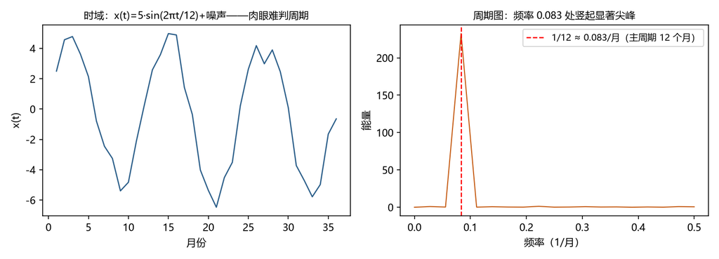

12 个月周期序列的时域与周期图

*图 5.1 左：时域里毛茸茸的波浪，肉眼难判周期；右：周期图在频率 0.083/月（=1/12）处竖起显著尖峰——主周期 12 个月一目了然。*

## 5.5 这个环节可能遇到的问题（陷阱清单）

1. **把周期图的噪声峰当真**：短样本周期图随机峰很多。**必须与显著性标准（Fisher 检验等）对比，别只看”最高的峰”。**
2. **频率与周期混淆**：周期 12 = 频率 1/12，不是 12。换算错一步，结论全错。
3. **谱泄漏（spectral leakage）**：有限样本的截断会让能量”漏”到相邻频率，尖峰变宽变矮。缓解：加窗函数（软件默认处理，但要知道它存在）。
4. **把”谱峰”当”因果”**：两个序列都在 7 天周期上有峰，不代表一个引起另一个（可能共同由星期效应驱动）。**频域发现的是”同期性”，不是因果。**
5. **过度滤波**：低通滤过头会把真实信号（突变、拐点）也抹掉。**滤波前问自己：我要保什么、扔什么。**
6. **只用频域忽略时域**：预测建模（第 7、8 章）主要在时域做；频域适合诊断周期与去噪，**别拿周期图去预测**（它不含”相位”以外的时序演化信息，直接反变换预测易失真）。

## 5.6 相似问题与已有解决方案：历史回响

| 本环节的困难 | 谁遇到过 | 如何解决 | 本书对应 |
| --- | --- | --- | --- |
| “周期未知，怎么找” | 天文学（Schuster 1898 周期图；太阳黑子之争） | **周期图/谱分析**；后来与 ACF 打通（Wiener–Khinchin 定理） | 本章；第 4 章 |
| “周期图噪声太大” | 信号处理（Bartlett、Tukey 1950s） | **平滑谱估计**（窗谱平均）、现代 Welch 方法；显著性检验 | 本章 |
| “滤波会失真/有泄漏” | 信号处理 20 世纪 | **窗函数**、现代小波与卡尔曼滤波（在线、因果） | 第 9 章 |
| “找到周期后怎么建模” | 计量经济学（1970s） | **SARIMA**（季节差分 + 季节项）；现代深度模型把”找周期”内嵌（Autoformer 用自相关发现周期） | 第 8、15 章 |
| “低频趋势与高频噪声难分离” | 多尺度分析（1990s） | **小波分析**：同时按频率和位置分解，适合非平稳信号 | 第 15 章提及 |

**核心启示**：周期问题几乎总是”先频域诊断、后时域建模”；而”诊断”这一步有一百年的成熟工具，**不要自己肉眼数周期。**

## 5.7 本章小结

1. 时域（ACF/PACF）看”前后怎么相关”，频域（谱/周期图）看”有哪些周期”；**谱 = ACF 的傅里叶变换**，同一信息两种坐标。
2. PACF 剔除中间滞后看”直达关系”，与 ACF 配合是第 7 章模型识别的钥匙。
3. 周期 = 1/频率；周期图的**显著尖峰**才是真周期，噪声峰会骗人。
4. 滤波（低通/高通/带通）是频域的实用技能；**移动平均就是最简易的低通**。
5. 分工原则：**频域诊断周期与去噪，时域建模预测。**

下一章进入本书第三部分——真正开始”建模”：从最简单的预测方法（指数平滑）起步，看”把过去加权求和”能做到多好。第 6 章 · 平滑与指数平滑。

## 5.8 练习与自测

1. ★ 周期是 7 天（日数据），对应的频率是多少？（提示：5.2.2）
2. ★ ACF 与 PACF 的区别是什么？（提示：5.2.1）
3. ★★ 一条序列的周期图在频率 0.25/年处有显著尖峰，主周期是几年？（提示：5.3 第 3 步）
4. ★★ 为什么说”周期图里最高的峰不一定代表真实周期”？（提示：5.5 陷阱 1）
5. ★★★ 用 Python（`scipy.signal.periodogram` 或 `statsmodels`）对第 2 章景区 24 个月数据算周期图，看尖峰出现在哪个频率，换算成周期，验证它是否与”夏季高峰”直觉一致。（提示：24 个月数据只有 1 个完整周期多点，频率分辨率有限——顺便体会”样本短→谱不清晰”）

**简答提示**：1 频率 = 1/7 ≈ 0.143/天；2 ACF 含间接传导的总相关，PACF 剔除中间滞后后的直接相关；3 周期 = 1/0.25 = 4 年；4 短样本周期图充满随机峰，须与显著性标准对比；5 尖峰应在 1/12≈0.083/月附近（若能分辨），但 24 个点分辨率很低，峰可能很宽——这正是陷阱 3 的现场版。

## 5.9 本章审阅记录

| 审阅项 | 结论 | 问题与修订 |
| --- | --- | --- |
| R1 零基础可理解性 | ✔ 通过（自查） | 频谱/周期图/滤波均用音乐、彩虹类比引入；频率与周期倒数关系反复强调；PACF 用”隔墙听声”类比 |
| R2 为何行动 | ✔ 通过 | 4 步流程每步有”为什么”；5.1 用太阳黑子例子说明”为什么需要频域” |
| R3 效果明确 | ✔ 通过 | 每步”会怎样”给出可检验结果（尖峰读数、周期换算） |
| R4 陷阱覆盖 | ✔ 通过 | 6 条：噪声峰、频率/周期混淆、谱泄漏、谱峰≠因果、过度滤波、频域不预测 |
| R5 相似问题映射 | ✔ 通过 | 5 行映射（周期图起源、平滑谱、滤波、SARIMA、小波） |
| R6 示例可复现 | ✔ 通过 | 5.4 示例自洽（频率 0.083/月 → 周期 12 月）；练习换算题验算（1/7≈0.143、1/0.25=4 年） |
| R7 章节衔接 | ✔ 通过 | 开头承接第 4 章 ACF，结尾预告第 6 章建模 |
| R8 练习有效 | ✔ 通过 | 5 题覆盖换算、PACF、显著性、实践谱分析 |

**审阅方式**：作者自查（R1–R8 逐项）；本章为过渡章未启用子代理（规范约定第 1、4、8、15、17 章启用）。谱分析为工程工具，公式细节留给软件，本书聚焦解读与分工。

# 第 6 章 · 平滑与指数平滑：用过去加权预测未来

**本章目标**：学完本章后，你能①手算简单指数平滑并解释平滑系数 α 的作用；②说出指数平滑与居中移动平均的本质区别（单边 vs 居中）；③判断”有趋势/有季节”时该升级到 Holt / Holt-Winters；④把指数平滑作为一切更复杂模型的”基线”。

## 6.1 动机：最简单的方法，最顽强的对手

> 一句话：**先学会跑赢基线，再谈复杂模型；指数平滑就是那条基线。**

## 6.2 是什么：从”等权平均”到”衰减加权”

### 6.2.1 移动平均的局限

第 2 章的移动平均给每个点**同样的权重**：10 个月前的值和昨天的值一样重要。这有两个问题：

- **反应迟钝**：序列刚发生趋势变化，移动平均要拖很久才跟上；
- **丢失最近信息**：昨天的数据其实最有用，却和三个月前的一样被对待。

直觉：**预测明天，昨天应该比上周五重要，上周五应该比上个月重要。** 权重应该”越近越大”。

### 6.2.2 指数平滑：权重按指数衰减

**简单指数平滑（SES）**用一个递推公式，让权重随”年龄”指数衰减：

```
ŝ_t = α·x_t + (1−α)·ŝ_{t−1}
```

- `x_t`：第 t 期的观测值；
- `ŝ_t`：第 t 期的**平滑值**（对”当前水平”的估计）；
- `α`（读作 alpha）：**平滑系数**，0 < α < 1，控制”多信任新数据”。

**公式讲人话**：*新的估计 = α 份新数据 + (1−α) 份旧估计。*

**为什么权重是”指数”衰减**：把公式递归展开：

```
ŝ_t = α·x_t + (1−α)·[α·x_{t−1} + (1−α)·ŝ_{t−2}]
    = α·x_t + α(1−α)·x_{t−1} + α(1−α)²·x_{t−2} + … + (1−α)^t·ŝ₀
```

权重依次是 α, α(1−α), α(1−α)², …——**每往前一步，权重乘一个 (1−α)，几何级数递减**。“指数”之名由此而来。

### 6.2.3 α 是”记忆旋钮”

| α 取值 | 含义 | 效果 |
| --- | --- | --- |
| 接近 1（如 0.9） | 几乎只信最近 | 跟得飞快，也跟噪声（毛糙） |
| 接近 0（如 0.05） | 几乎只看长期 | 非常平滑，但反应迟钝 |
| 常用 0.1~0.3 | 中庸 | 稳健，多数场景默认 |

### 6.2.4 单边性：为什么它适合预测（关键）

第 2 章讲过：**居中**移动平均用了未来数据，只能事后描述。指数平滑只用 `x_t` 和更早的数据——**它是”单边”（因果）的，天然适合预测、无泄漏**。这是它比居中移动平均更适合做预测的根本原因。

### 6.2.5 升级：Holt 与 Holt-Winters

简单指数平滑只有一个”水平”方程，预测永远是**水平线**。序列有趋势或季节时，需要加方程：

- **Holt 线性趋势**（两个方程）：水平 ℓ_t + 趋势 b_t（斜率），预测 `ℓ_t + h·b_t`（h 步外，趋势继续走）。
- **Holt-Winters（三次指数平滑）**：水平 + 趋势 + 季节，共 3 个平滑方程 + 季节周期 m，预测 = (水平 + h×趋势) × 季节因子（乘法版）。

**怎么选**（口诀）： - 无趋势无季节 → 简单指数平滑（SES） - 有趋势无季节 → Holt - 有趋势有季节 → Holt-Winters - 无趋势有季节 → Holt-Winters 的季节版（或对季节先分解）

## 6.3 怎么做：五步走

### 第 1 步 · 定 α

- **做什么**：默认从 α=0.2~0.3 起步；更严谨的做法是**最小化样本外误差**（把 α 在 0.05~0.95 网格上试，选使滚动验证误差最小的值，第 19 章详述）。
- **为什么**：α 是唯一需要人定的参数，它决定”记忆长度”；选错会让模型要么过拟合噪声、要么跟不上变化。
- **会怎样**：得到”调好的 α”，后面的递推全用它。

### 第 2 步 · 初始化

- **做什么**：取 ŝ₁ = x₁（第一个平滑值等于第一个观测）；或用前几个点的平均。
- **为什么**：递推需要一个起点；起点只影响开头几步，样本足够长时影响消失。
- **会怎样**：从第 2 个点开始，每个点都有平滑值。

### 第 3 步 · 递推

- **做什么**：逐点算 ŝ_t = α·x_t + (1−α)·ŝ_{t−1}。
- **为什么**：这是”滚动更新”——每来一个新数据，平滑值就移动一点，永远跟上最新水平。
- **会怎样**：得到一条比原序列平滑的曲线；它落后于剧烈变化（α 小则落后多）。

### 第 4 步 · 预测

- **做什么**：简单指数平滑对**未来任意步**的预测都是最后一个平滑值：`x̂_{T+h} = ŝ_T`。
- **为什么**：模型假设”水平不变”，没有趋势和季节可外推——所以预测是水平线。
- **会怎样**：得到点预测；配合误差的标准差可做区间（软件自动给）。

### 第 5 步 · 诊断与升级

- **做什么**：看残差（观测 − 预测）是否仍有趋势/季节；若有，升级到 Holt / Holt-Winters。
- **为什么**：残差里有结构 = 模型少解释了东西。
- **会怎样**：残差干净 → 停留在当前模型；不干净 → 换更复杂的家族成员（或第 8 章的 SARIMA）。

## 6.4 完整示例：手算简单指数平滑（α=0.3）

数据：`10, 12, 11, 13`（4 个点）

```
初始化：ŝ₁ = x₁ = 10
ŝ₂ = 0.3×12 + 0.7×10 = 3.6 + 7.0 = 10.6
ŝ₃ = 0.3×11 + 0.7×10.6 = 3.3 + 7.42 = 10.72
ŝ₄ = 0.3×13 + 0.7×10.72 = 3.9 + 7.504 = 11.404
预测 x₅ = ŝ₄ ≈ 11.40
```

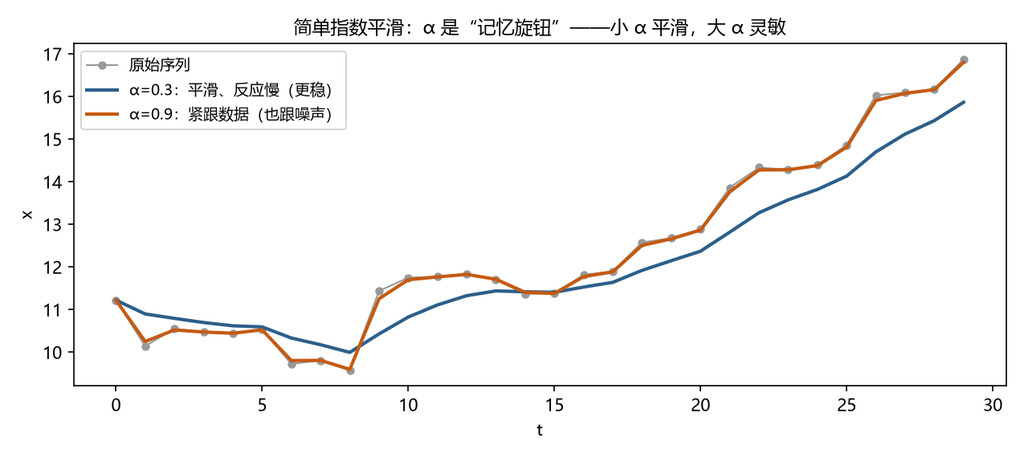

指数平滑 α 对比

*图 6.1 α 是”记忆旋钮”：α=0.3 平滑但反应慢，α=0.9 紧跟数据但也跟噪声——选 α 就是选”信多久的记忆”。*

**观察**：平滑值 10 → 10.6 → 10.72 → 11.40，**永远在”追”但从不跳**——数据从 10 跳到 12，平滑值只跟到 10.6；从 11 跳到 13，只跟到 11.40。这就是”平滑”：**过滤掉跳变，只留水平**。α=0.9 的话会跟得快得多（你可以自己算：ŝ₂ = 0.9×12+0.1×10 = 11.8，几乎立刻追上）。

**效果**：你得到了预测 11.40——**没有做任何复杂数学，预测已可用**；更重要的是你理解了”加权过去”的机制，这是后面所有模型（ARIMA、注意力）的共同内核。

## 6.5 这个环节可能遇到的问题（陷阱清单）

1. **α 拍脑袋且不验证**：α 影响一切，却不做样本外比较。**至少试 3 个 α，用滚动验证选。**
2. **有趋势却用 SES**：SES 预测是水平线，对上升序列**系统性偏低**（永远落后半拍）。**先看图有没有趋势，有就上 Holt。**
3. **有季节却用 SES/Holt**：季节会变成周期性残差。**先分解或直接 Holt-Winters。**
4. **初始化草率**：小样本时 ŝ₁=x₁ 影响前几个点；样本 <20 时建议用前几个点平均初始化。
5. **只给点预测**：业务要的是”区间”。**指数平滑软件默认给 80%/95% 预测区间，别关掉它。**
6. **与居中移动平均混用**：居中移动平均用于事后描述（第 2 章），指数平滑用于预测——**别把居中结果当预测**（那等于偷看未来）。
7. **把”平滑”当”建模”**：指数平滑假设”水平/趋势/季节缓慢变化”，突变（结构性断点）它处理不了——**突变场景要交给第 12 章机制转换。**

## 6.6 相似问题与已有解决方案：历史回响

| 本环节的困难 | 谁遇到过 | 如何解决 | 本书对应 |
| --- | --- | --- | --- |
| “等权平均太迟钝” | Brown (1959)、Holt (1957)、Winters (1960) | **指数平滑族**：SES → Holt → Holt-Winters，参数各有含义 | 本章 |
| “预测永远滞后” | 同上 | Holt 加趋势方程；或先差分再平滑（与 ARIMA 相通） | 本章；第 8 章 |
| “α 怎么选” | 预测实践（Makridakis 等） | **样本外滚动验证**最小化误差；自动化软件默认优化 | 第 19 章 |
| “平滑与 ARIMA 什么关系” | Box 等 (1970s) | 证明：**指数平滑是一类特殊 ARIMA**（如 SES = ARIMA(0,1,1)），两个世界打通 | 第 8 章 |
| “区间预测怎么给” | 统计预测理论 | 平滑模型有解析预测方差公式，软件直接输出区间 | 第 19 章 |

**核心启示**：你以为自己在学”一个简单技巧”，实际上在学”预测思想的第一课”——**加权过去、单边递推、残差诊断、按结构升级**。这四个动作是后面所有章节的母题。

## 6.7 本章小结

1. **指数平滑**：ŝ_t = α·x_t + (1−α)·ŝ_{t−1}，权重指数衰减，“越近越重要”。
2. **单边性**是它能预测、无泄漏的根本原因（对比第 2 章居中移动平均）。
3. **按结构选成员**：SES（无趋势无季节）→ Holt（有趋势）→ Holt-Winters（有趋势+季节）。
4. 流程：**定 α → 初始化 → 递推 → 预测 → 残差诊断**；α 靠样本外验证选。
5. 它是最强基线、是一切”加权过去”思想的源头——**先在它身上赢，再谈复杂模型。**

下一章进入真正的”统计模型”：让序列自己的历史说话——AR、MA、ARMA。第 7 章 · 从回归到 AR/MA：让过去自己说话。

## 6.8 练习与自测

1. ★ 简单指数平滑 α=0.5，数据 `8, 10`，求 ŝ₁、ŝ₂ 和预测 x₃。（提示：6.3）
2. ★ 有上升趋势的序列用 SES 预测，会系统性偏高还是偏低？为什么？（提示：6.5 陷阱 2）
3. ★★ 用 α=0.4 对数据 `5, 6, 7` 手算平滑值（提示：6.4 模板）
4. ★★ 为什么”居中移动平均”不能用于预测？（提示：6.2.4 与第 2 章泄漏）
5. ★★★ 用 `statsmodels` 或 R `forecast` 对第 2 章景区数据跑 Holt-Winters，比较它与”朴素预测”（拿上个月当预测）的 MAE，说说谁赢、为什么。（提示：景区有趋势+季节，Holt-Winters 应明显胜出）

## 6.9 本章审阅记录

[output not shown]

**审阅方式**：作者自查（R1–R8 逐项）+ 数字验算；本章为第三部分开篇，未启用子代理。

# 第 7 章 · 从回归到 AR/MA：让过去自己说话

**本章目标**：学完本章后，你能①用一句话解释 AR(p)、MA(q)、ARMA(p,q) 分别假设了什么；②背出 ACF/PACF 识别表并应用；③手算一个 AR(1) 的预测；④说出平稳性对 AR 系数的约束意味着什么。

## 7.1 动机：从”加权”到”解释”

第 6 章的指数平滑是**加权过去**：好用，但它不解释”数据为什么这样动”——它只是一台平滑机器。本章的 AR/MA 换一个思路：**假设数据的生成机制**，然后从数据里把机制”挖”出来。

两种基本假设，对应两类模型：

- **AR（自回归）**：今天的值**由过去的观测值决定**——“昨天值高，今天倾向也高”。
- **MA（滑动平均）**：今天的值**由过去的随机冲击决定**——“昨天的意外冲击，今天还有余波”。

> 一句话：**AR 用”看得见的过去”（观测值）解释现在，MA 用”看不见的过去”（冲击）解释现在。** 真实序列往往两者都有 → ARMA。

为什么值得学：它是 Box–Jenkins 方法（第 8 章 ARIMA）的地基，也是”模型识别 → 估计 → 诊断”这套**工作流**的首次完整登场——这套工作流今天仍是所有建模的标准流程。

## 7.2 是什么：三个模型

### 7.2.1 AR(p)：自回归

**AR(p) 模型**（p 阶自回归）：

```
x_t = c + φ₁·x_{t−1} + φ₂·x_{t−2} + … + φ_p·x_{t−p} + ε_t
```

- `c`：常数（截距）；
- `φ₁…φ_p`（读作 phi）：**自回归系数**——每个过去观测的”影响力”；
- `ε_t`：白噪声冲击（第 3 章）。

**AR(1) 特例**（只有一个过去值）：

```
x_t = c + φ·x_{t−1} + ε_t
```

- φ>0：今天高 → 明天倾向也高（**惯性**，如气温）；
- φ<0：今天高 → 明天倾向回落（**回摆**，如价格修正）；
- φ=0：没有记忆（白噪声加常数）。

**平稳条件（必记）**：AR(1) 平稳要求 **|φ| < 1**。为什么？冲击的传导是 φ、φ²、φ³……**|φ|<1 时冲击随时间消退**，序列围绕长期均值波动；|φ|≥1 时冲击永不消退，序列”漂走”（这就是第 4 章”单位根”的 AR 面孔——φ=1 是随机游走）。

**长期均值**：AR(1) 会被拉向 `c/(1−φ)`——**均值回归**（mean reversion）。

### 7.2.2 MA(q)：滑动平均

**MA(q) 模型**（q 阶滑动平均）：

```
x_t = μ + ε_t + θ₁·ε_{t−1} + θ₂·ε_{t−2} + … + θ_q·ε_{t−q}
```

- `μ`：长期均值；
- `θ₁…θ_q`（读作 theta）：**冲击系数**——过去冲击的”余波强度”；
- `ε_t`：白噪声冲击。

**MA(1) 特例**：`x_t = μ + ε_t + θ·ε_{t−1}`。直觉：**今天的值 = 长期水平 + 今天的冲击 + 昨天冲击的一点余波**。比如”某天促销的冲击，第二天还有小幅余波”。

**为什么需要 MA**：有些序列的依赖”记不住具体数值，只记得冲击”。用 AR 表达这种依赖可能需要几十项，用 MA 一两项就够——**简约**。理论保证：**Wold 分解定理**说任何”纯非确定”平稳过程都可以写成 MA(∞)，所以”用冲击表示”有普遍基础。

### 7.2.3 ARMA(p,q)：合体

**ARMA(p,q)** = AR(p) + MA(q)：

```
x_t = c + φ₁x_{t−1} + … + φ_p x_{t−p} + ε_t + θ₁ε_{t−1} + … + θ_q ε_{t−q}
```

**直觉**：*既用观测值的惯性，又用冲击的余波*。比如温度：昨天的温度有惯性（AR），一场寒潮的冲击还有两天余波（MA）。

### 7.2.4 识别表：ACF/PACF 怎么告诉我们 p、q（背下来）

第 5 章学过：ACF 看总相关，PACF 看剔除中间滞后后的直接相关。结果是：

| 模型 | ACF | PACF |
| --- | --- | --- |
| **AR(p)** | 拖尾（缓慢衰减，如指数式） | **p 阶后截尾**（突然归零） |
| **MA(q)** | **q 阶后截尾** | 拖尾 |
| **ARMA(p,q)** | 拖尾 | 拖尾 |

**为什么**：AR(1) 的记忆是”传导链”（x_t→x_{t−1}→x_{t−2}…），所以总相关 ρ(k)=φ^k 一直衰减（拖尾）；但剔除中间环节后，x_t 与 x_{t−2} 的**直接**关系是 0（PACF 截尾）——**记忆靠链条，链条一断就没了**。MA(1) 恰好反过来：直接记忆只有 1 步（ACF 截尾），但”间接”关系永远存在（PACF 拖尾）。想不通就先背表，第 7.4 节有数字例子。

## 7.3 怎么做：完整工作流（Box–Jenkins 的前半）

### 第 1 步 · 平稳化

- **做什么**：按第 4 章五步判断平稳；不平稳先差分/去趋势（第 8 章细说）。
- **为什么**：ARMA 的一切理论（估计、检验、预测区间）都以平稳为前提；非平稳拟合会得到 φ≈1 的”假模型”。
- **会怎样**：得到平稳序列，进入识别。

### 第 2 步 · 识别（定 p、q）

- **做什么**：画 ACF/PACF，对照识别表定阶。
- **为什么**：ACF/PACF 的截尾/拖尾是数据给的”指纹”，避免瞎猜阶数。
- **会怎样**：得到候选模型，如 AR(1) 或 MA(1) 或 ARMA(1,1)。

### 第 3 步 · 估计（φ、θ 的值）

- **做什么**：用软件（极大似然估计）拟合，得到系数估计值与标准误。
- **为什么**：选择”最可能产生这串数据”的系数——极大似然的直觉是”让模型说’这数据很像我’“。
- **会怎样**：得到带系数的模型，如 x_t = 2 + 0.6x_{t−1} + ε_t。

### 第 4 步 · 诊断

- **做什么**：检验残差是否白噪声（Ljung–Box 检验；ACF 图看残差）。
- **为什么**：残差还有相关 = 模型没挖干净，阶数可能不够。
- **会怎样**：残差白 → 模型合格；不白 → 回到第 2 步加大阶数，或考虑季节（第 8 章）。

### 第 5 步 · 预测

- **做什么**：多步预测（软件输出点预测+区间）。AR(1) 的 h 步预测：`x̂_{T+h} = c + φ·x̂_{T+h−1}`（逐步代回）。
- **为什么**：预测本质是”让模型继续演”。
- **会怎样**：远期预测收敛到长期均值（c/(1−φ)）——**AR 的预测会”回归均值”，这是它和指数平滑（水平线）的直观差别**。

## 7.4 完整示例：AR(1) 手算

模型：`x_t = 2 + 0.6·x_{t−1} + ε_t`。已知 x₁ = 10，ε₂ = 0.5。

```
x₂ = 2 + 0.6×10 + 0.5 = 2 + 6 + 0.5 = 8.5
```

**观察**：x₁=10 高于长期均值 c/(1−φ) = 2/0.4 = **5**，所以 x₂ 被拉回 8.5——**均值回归的力量**。若 φ=0.9，x₂ = 2+9+0.5 = 11.5（惯性更强，回得慢）；若 φ=−0.6，x₂ = 2−6+0.5 = −3.5（今天高明天就回摆）。

**ACF 验证**：AR(1) 的 ρ(k) = φ^k（φ=0.6：0.6, 0.36, 0.216…**指数拖尾**）；PACF 在 k=1 后**截尾**（ρ(1)=0.6，之后≈0）。对照识别表：AR(1)。——这就是”指纹”的现场演示。

**效果**：你刚刚完成了一次完整的”识别→估计→预测”演练；第 8 章会把”不平稳怎么办（差分）“补上，变成完整的 ARIMA。

## 7.5 这个环节可能遇到的问题（陷阱清单）

1. **用非平稳数据拟合 AR**：φ 估计值逼近 1，看似”很显著”，其实是随机游走的假象。**先平稳化，再谈 AR。**
2. **阶数贪多**：p、q 越大拟合越好，但预测越差（过拟合）。**用 AIC/BIC 惩罚复杂（第 19 章），别只看拟合优度。**
3. **识别表搞反**：AR 看 PACF 截尾，MA 看 ACF 截尾——反了会选错模型。
4. **把 MA 的冲击当可观测**：ε_t 是”看不见的”，不能像 AR 那样直接读过去值；MA 的估计与预测都更依赖软件。
5. **跳过残差诊断**：不看残差就宣布”模型完成”——残差不白，模型就是错的。
6. **忽视”简约性”**：能用 ARMA(1,1) 别用 ARMA(5,5)；参数越多越容易过拟合。
7. **把 AR 当因果**：AR 的 φ 只描述”统计依赖”，不代表”x_{t−1} 导致 x_t”（因果要第 11、19 章的专门工具）。

## 7.6 相似问题与已有解决方案：历史回响

| 本环节的困难 | 谁遇到过 | 如何解决 | 本书对应 |
| --- | --- | --- | --- |
| “阶数怎么定” | Box & Jenkins (1970) | **识别表**（ACF/PACF 截尾拖尾）+ 三阶段工作流 | 本章；第 8 章 |
| “阶数太多/太少” | Akaike (1974) | **AIC/BIC**：似然 + 参数数惩罚 | 第 19 章 |
| “残差是否白” | Box & Pierce (1970)、Ljung & Box (1978) | **Ljung–Box 检验**：检验残差自相关是否显著 | 本章 |
| “AR 和 MA 为何等价” | Wold (1938) | **Wold 分解定理**：任何纯非确定平稳过程 = MA(∞) | 本章 7.2.2 |
| “有趋势/季节怎么进模型” | Box & Jenkins (1970) | **差分 + SARIMA**（第 8 章）把非平稳也纳入框架 | 第 8 章 |

**核心启示**：AR/MA 的价值不在公式，而在**工作流**——平稳化、识别、估计、诊断、预测，每一步都有明确工具和明确失败模式。这套流程从 1970 年用到今天，是”建模纪律”的源头。

## 7.7 本章小结

1. **AR**：今天 = 过去观测的线性组合（“看得见的记忆”）；平稳要求 |φ|<1，有均值回归。
2. **MA**：今天 = 长期均值 + 过去冲击的组合（“看不见的记忆”）；Wold 定理给普遍性。
3. **ARMA** = AR + MA，兼顾两类记忆。
4. **识别表**：AR 的 PACF 截尾、MA 的 ACF 截尾（背下来）。
5. 工作流：**平稳化 → 识别 → 估计 → 诊断 → 预测**；残差不白就回头。

下一章把 ARMA 升级为完整的 Box–Jenkins 体系：**非平稳怎么办（差分）→ ARIMA；季节怎么办 → SARIMA**。第 8 章 · ARIMA 与 Box-Jenkins：一套完整建模工作流（重点章）。

## 7.8 练习与自测

1. ★ 用一句话分别解释 AR、MA、ARMA 假设了什么。（提示：7.1）
2. ★ AR(1) 平稳的条件是什么？φ=1 时是什么过程？（提示：7.2.1）
3. ★★ 模型 x_t = 1 + 0.8x_{t−1} + ε_t，x₁=20，ε₂=−1，求 x₂ 和长期均值。（提示：7.4）
4. ★★ 某序列的 ACF 在 k=2 后全部落在虚线内，PACF 缓慢衰减。按识别表它是什么模型？（提示：7.2.4）
5. ★★★ 用 `statsmodels` 对第 4 章”平稳小序列”（自造）拟合 AR(1)，看估计的 φ、残差的 Ljung-Box p 值，并解读。（提示：7.3 五步；残差 p 值大 = 合格）

**简答提示**：1 AR：今天由过去观测决定；MA：今天由过去冲击决定；ARMA：两者都有；2 |φ|<1；φ=1 是随机游走（非平稳）；3 x₂ = 1+16−1 = 16，长期均值 = 1/(1−0.8) = 5（x₁=20 远高于 5，被强力拉回）；4 MA(2)——ACF 在 2 后截尾是 MA 的指纹；5 略。

## 7.9 本章审阅记录

| 审阅项 | 结论 | 问题与修订 |
| --- | --- | --- |
| R1 零基础可理解性 | ✔ 通过（自查） | φ、θ、c、μ、ε_t 全部在出现处解释；AR/MA 用”看得见/看不见的记忆”类比；识别表配”传导链”机制解释 |
| R2 为何行动 | ✔ 通过 | 五步工作流每步有”为什么”；MA 存在的理由（简约性、Wold 定理）单独成段 |
| R3 效果明确 | ✔ 通过 | 每步”会怎样”可检验（φ=0.6 vs 0.9 vs −0.6 的预测对比） |
| R4 陷阱覆盖 | ✔ 通过 | 7 条：非平稳拟合、阶数过拟合、识别表反、MA 不可观测、跳过诊断、非简约、AR≠因果 |
| R5 相似问题映射 | ✔ 通过 | 5 行映射（识别表、AIC/BIC、Ljung-Box、Wold、SARIMA） |
| R6 示例可复现 | ✔ 通过 | AR(1) 手算（8.5、11.5、−3.5）与练习 3（16、均值 5）验算通过 |
| R7 章节衔接 | ✔ 通过 | 开头承接指数平滑，结尾预告第 8 章 ARIMA/SARIMA |
| R8 练习有效 | ✔ 通过 | 5 题覆盖定义、平稳条件、手算、识别表、实践 |

**审阅方式**：作者自查（R1–R8 逐项）+ 数字验算；本章为第 8 章的铺垫章，重点章（第 8 章）将启用子代理。

# 第 8 章 · ARIMA 与 Box-Jenkins：一套完整建模工作流

**本章目标**：学完本章后，你能①说出 ARIMA(p,d,q) 与 SARIMA 每个字母的含义；②手算一阶差分并解释”差分做了什么”；③按 Box-Jenkins 五步走完一个完整案例；④说出”差分次数怎么定”和”什么时候该用 SARIMA”。

## 8.1 动机：把”非平稳”也请进模型

第 7 章的 ARMA 有个苛刻前提：**序列必须平稳**。但第 4 章说过：真实数据几乎都不平稳——有趋势、有季节。难道把 ARMA 扔掉？

Box 和 Jenkins 1970 年的回答是：**不扔，改造**。办法简单得惊人——**先把非平稳”差掉”，再对剩下的平稳部分建 ARMA，预测完再把差分”加回去”**。这就是 ARIMA，它让”平稳”这个约束从”前提”变成了”流程的一步”。

> 一句话：**ARIMA = 差分（处理非平稳） + ARMA（建模平稳部分）。** 它把第 4 章的”非平稳怎么办”和第 7 章的”平稳怎么建”焊成了一条流水线。

这套方法之所以伟大，不只是模型本身，而是它提出的**建模纪律**——识别、估计、诊断、再修正的循环。五十年后，深度学习的调参循环本质上还是它。

## 8.2 是什么：差分与三个字母

### 8.2.1 差分（difference）：非平稳的”手术刀”

**一阶差分**：`x'_t = x_t − x_{t−1}`——用”相邻变化量”替代”水平值”。

**为什么能去趋势**（爬坡类比）：把序列想成一条斜坡，差分算的是”每一步的步高”。若斜坡是直的（每月固定涨 2），步高恒等于 2——**差完等于把坡抹平成平地**；若坡还带点噪声，步高就是 2±噪声，均值稳定在 2 而非 0（差分去掉的是”位置漂移”，留下的是”每步的平均涨幅”）。差完之后序列**均值不再漂移**，就平稳了。

**二阶差分**：对一阶差分再差一次——对付”上升速度本身还在变”（弯曲趋势）。日常很少超过二阶。

**季节差分**：`x_t − x_{t−m}`（m=季节周期，如 12）——专门去季节。**注意：季节差分 ≠ 普通差分**，普通差分会留下季节残渣（第 4 章陷阱 5 的现场版）。

### 8.2.2 ARIMA(p,d,q)：三个字母

| 字母 | 含义 | 对应第 7 章 |
| --- | --- | --- |
| **p** | 自回归阶数 | AR 部分 |
| **d** | **差分次数** | 新成员 |
| **q** | 滑动平均阶数 | MA 部分 |

**ARIMA(1,1,1)** 读作：先差 1 次，再对差分序列建 ARMA(1,1)。

**完整流程**（含”还原”）：

```
原始 x_t →（差分 d 次）→ 平稳序列 y_t →（ARMA 建模）→ 预测 ŷ →（差分"加回"）→ 预测 x̂
```

### 8.2.3 SARIMA：把季节请进来

**SARIMA(p,d,q)(P,D,Q)_m**：在 ARIMA 之外加一套”季节版”参数（大写 P、D、Q）与季节周期 m。逐项对照：

[output not shown]

- 例如 `ARIMA(1,1,1)(1,1,1)₁₂`：普通部分 ARMA(1,1)、差分一次；季节部分 ARMA(1,1)、季节差分一次，月度数据。
- **直觉**：普通部分学”相邻依赖”（昨天影响今天），季节部分学”跨年依赖”（去年 12 月影响今年 12 月）。
- **什么时候用**：ACF 在季节滞后（12、24、36…）处还有明显的峰，且普通 ARIMA 残差仍呈周期——就去季节差分或加季节项。

### 8.2.4 一个美丽的桥

**指数平滑 = 特殊 ARIMA**：SES 等价于 ARIMA(0,1,1)，Holt 等价于 ARIMA(0,2,2)，Holt-Winters 等价于某些 SARIMA。1970s 被证明——**第 6 章的”加权机器”和第 7 章的”机制模型”原来是一家**。（为什么等价？两个模型都在做”一步记忆 + 新信息”的递推更新，数学形式同构；证明较繁琐，第 19 章给出指引，知道”它们是一家”就够用。）这条桥让你在”简单稳健”（指数平滑）和”灵活完整”（ARIMA）之间自由切换。

## 8.3 怎么做：Box-Jenkins 五步（完整案例）

用第 2 章景区数据**前 12 个月**（2023 年）演示，目标是预测 2024 年 1 月：

```
3.0, 2.8, 3.5, 4.2, 5.0, 6.1, 7.2, 7.0, 5.8, 5.0, 4.0, 3.6
```

### 第 1 步 · 识别：序列平稳吗？

- **做什么**：画图 + ADF 检验（第 4 章）。
- **为什么**：决定要不要差分、差几次。
- **会怎样**：形态是先升后降的**季节单峰**（1→7 月从 3.0 爬到 7.2，7→12 月回落到 3.6），ADF 的 p 值大 → **非平稳** → 需要差分。（ADF 的原假设是”序列非平稳”，p 值大＝不能拒绝原假设，即判定非平稳——与常见检验”p 小才有证据”相反，别记反。）

### 第 2 步 · 差分到平稳

- **做什么**：算一阶差分。记 `x'_t = x_t − x_{t−1}`，表示**第 t 月比第 t−1 月的变化量**，全部 11 个：

```
x'_2 = 2.8 − 3.0 = −0.2   x'_3 = 3.5 − 2.8 = +0.7
x'_4 = 4.2 − 3.5 = +0.7   x'_5 = 5.0 − 4.2 = +0.8
x'_6 = 6.1 − 5.0 = +1.1   x'_7 = 7.2 − 6.1 = +1.1
x'_8 = 7.0 − 7.2 = −0.2   x'_9 = 5.8 − 7.0 = −1.2
x'_10 = 5.0 − 5.8 = −0.8  x'_11 = 4.0 − 5.0 = −1.0
x'_12 = 3.6 − 4.0 = −0.4
```

- **为什么**：差分把”先升后降的摆动”拉平为”围绕某个值波动”（爬坡类比：差分算每一步的步高，差完等于把坡抹平）。
- **会怎样**：差分序列在 ±1 附近波动、均值≈0.05——比原始序列平稳得多。**再跑一次 ADF 确认平稳**；不平稳就再差一次（但别贪，见 8.5 陷阱 1）。**提醒：这数据明显有季节，严格说该用季节差分（见 8.5 陷阱 3），这里先用普通差分演示机制。**

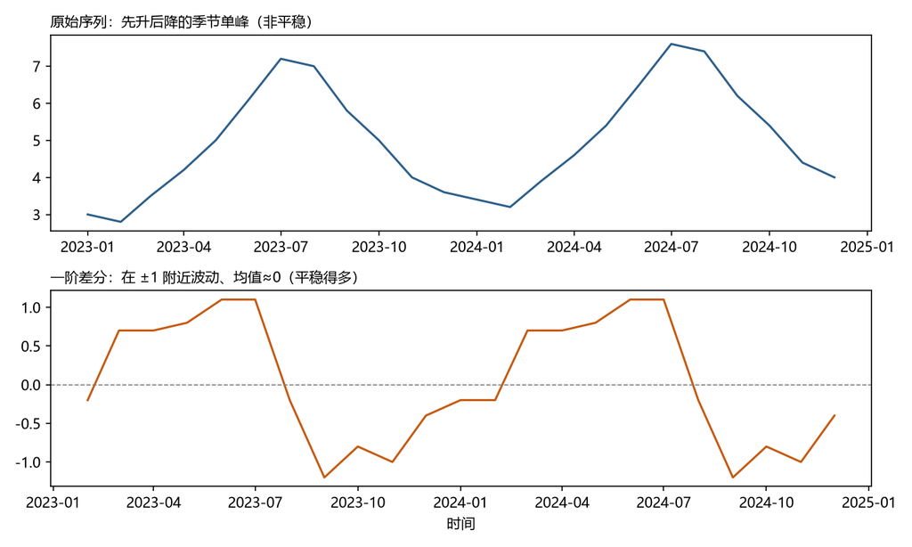

景区数据原始与一阶差分对比

*图 8.1 上图：原始序列（先升后降的季节单峰，非平稳）；下图：一阶差分（在 ±1 附近波动、均值≈0，平稳得多）——差分把”摆动”抹平为围绕 0 波动。*

### 第 3 步 · 识别 p、q

- **做什么**：看差分序列的 ACF/PACF，对照第 7 章识别表。
- **为什么**：确定 ARMA 的阶数。
- **会怎样**：12 个点太少，ACF/PACF 基本都在虚线内——此时**取小阶数**（如 ARIMA(0,1,1) 或 (1,1,0)），或者干脆承认”数据不够、改用指数平滑”。**短样本的诚实选择也是建模能力的一部分。**

### 第 4 步 · 估计与诊断

- **做什么**：软件拟合（自动给出系数与标准误）；检验残差白噪声（Ljung-Box）。
- **为什么**：残差不白 = 模型没挖干净。
- **会怎样**：残差 p 值大 → 合格；p 值小 → 加阶数或加季节项（见 8.2.3）重来。

### 第 5 步 · 预测并还原

- **做什么**：软件给出差分层面的预测 ŷ，再加回 x₁₂ 得水平预测：

```
x̂₁₃ = x₁₂ + ŷ₁₃ = 3.6 + ŷ₁₃
```

- **为什么**：还原是差分的逆操作，预测”变化量”再变回”水平”。
- **会怎样**：得到 2024 年 1 月的点预测与区间。**注意：数据只有 12 个月、还有季节没建模——这个预测会偏保守，正式分析要用多年数据 + SARIMA。**

## 8.4 完整示例：线性趋势序列的”完美差分”

数据：`3, 5, 7, 9`（完美的线性趋势：每月 +2）

```
一阶差分：5−3=2, 7−5=2, 9−7=2 → 2, 2, 2 （常数！）
```

**观察**：差分后是常数 2——没有趋势、没有波动，ARMA 部分只需一个均值 2。预测下一个差分 = 2，还原：x₅ = 9 + 2 = **11**。

**效果**：这个例子把 ARIMA 的思想照得透亮——**趋势是”常数的差分”，差掉之后剩下的就是”老实”的部分**。真实数据没有这么完美（差分后是 2±噪声），但机制完全一样。

## 8.5 这个环节可能遇到的问题（陷阱清单）

1. **过度差分**：差 5 次总比 1 次”更平稳”，但信号也差没了——预测变成”预测噪声”。**准则：差到刚好平稳就停（ADF/KPSS 循环确认）；差分次数一般 ≤2。**
2. **忘了”解释对象变了”**：差分的模型预测的是**变化量**，业务要的是水平——**还原步骤不能省**；向业务解释时也要说”我们预测的是变化”。
3. **季节数据用普通差分**：月度数据普通差分后，ACF 在 12、24 处仍有大峰——**需要季节差分或 SARIMA**。
4. **把 auto.arima 当黑箱**：自动选阶方便，但**不看残差诊断、不看业务合理性**，等于让软件替你放弃思考。**自动选阶 + 人工诊断**才是正确姿势。
5. **预测区间处理不当**：ARIMA 的 h 步（h＝向未来预测的步数）预测区间随 h **逐渐变宽**——因为模型的记忆有限，远期可用的过去信息趋近于零，预测收缩回长期均值、不确定性累积，所以区间越拉越宽。这是对的；但很多人只汇报点预测，把”会变宽”藏起来。
6. **忽略外生变量与断点**：有已知的节假日效应、政策冲击，ARIMA 学不会——**需要 ARIMAX/回归项，或第 12 章机制转换**。
7. **样本太短硬上 ARIMA**：ARIMA 对样本量有要求（一般建议 ≥30~50 个点）；短序列用指数平滑更稳。**模型的复杂度要和样本量匹配。**

## 8.6 相似问题与已有解决方案：历史回响

| 本环节的困难 | 谁遇到过 | 如何解决 | 本书对应 |
| --- | --- | --- | --- |
| “非平稳进不了模型” | Box & Jenkins (1970) | **差分 + ARIMA**：把平稳化变成流程一步 | 本章 |
| “季节怎么办” | Box & Jenkins (1970)；官方统计 X-11（季节调整程序） | **SARIMA**（季节差分 + 季节项） | 本章 |
| “差几次、阶数多少” | Akaike (1974)、Dickey & Fuller (1979) | **ADF 与 KPSS**（互补的平稳性检验）定 d；**AIC/BIC**（拟合优度+复杂度惩罚）定 p,q；auto.arima 自动化（Hyndman & Khandakar 2008） | 本章；第 19 章 |
| “残差不白怎么办” | Box & Jenkins | 加大阶数 / 加季节 / 加外生变量（ARIMAX＝带外生回归项的 ARIMA）→ 重走识别 | 本章 |
| “简单方法与 ARIMA 谁好” | Makridakis 竞赛系列（M-competitions 1982–2020） | **结论反复：短样本/简单序列，指数平滑常赢；复杂序列 ARIMA 或集成赢**——基线对比永不过时 | 第 6 章；第 19 章 |

**核心启示**：ARIMA 的每一步失败模式都有对治手段（差分→ADF；阶数→AIC；残差→Ljung-Box；季节→SARIMA；自动→auto.arima）——**“建模”就是”用工具诊断问题、按诊断改模型”的循环**。

## 8.7 本章小结

1. **ARIMA(p,d,q)** = 差分（d 次）处理非平稳 + ARMA(p,q) 建模平稳部分；预测完要**还原**。
2. **差分**把”缓慢上升”变成”围绕常数波动”；差分次数靠 ADF/KPSS 循环确认，**≤2 次，别贪**。
3. **SARIMA(p,d,q)(P,D,Q)_m** 加一套季节部分，对付”去年 12 月影响今年 12 月”。
4. **Box-Jenkins 五步**：①识别（平稳？）→ ②差分 → ③定阶（ACF/PACF、AIC）→ ④估计+诊断（残差白噪声，不白就回头）→ ⑤预测还原。
5. **指数平滑 = 特殊 ARIMA**——两个世界一座桥。

下一章换一条完全不同的技术路线：**状态空间模型与卡尔曼滤波**——不靠差分，而是假设”隐藏状态”在演化，从噪声观测中把它实时滤出来。第 9 章 · 状态空间与卡尔曼滤波。

## 8.8 练习与自测

1. ★ ARIMA(2,1,0) 各部分含义？（提示：8.2.2）
2. ★ 数据 `1, 4, 7, 10` 一阶差分后是什么？下一个水平预测若差分预测为 3，x₅ 是多少？（提示：8.4）
3. ★★ 月度数据普通差分后 ACF 在滞后 12、24 处还有大峰，说明什么？怎么办？（提示：8.5 陷阱 3）
4. ★★ 为什么 ARIMA 的预测区间会随预测步数变宽？（提示：8.5 陷阱 5 与 7.2.1 均值回归）
5. ★★★ 用 `pmdarima.auto_arima` 或 R `auto.arima` 对第 2 章景区 24 个月数据自动选阶，再手动检查：①自动选了什么 (p,d,q)(P,D,Q) 与 m；②残差 Ljung-Box 的 p 值（大＝合格）；③预测 2025 年 1 月并还原成水平值。评价自动结果是否合理——检查清单：是否处理了季节、p 值是否真的大、预测是否符合”2 月低谷”的业务直觉。（提示：8.5 陷阱 4——自动+人工）

**简答提示**：1 p=2（AR 部分 2 阶）、d=1（差 1 次）、q=0（无 MA 部分）；2 差分 `3,3,3`；x₅ = 10+3 = 13；3 季节残渣——需要季节差分或 SARIMA；4 远期冲击的不确定性累积，预测回到均值且区间变宽（统计上远期信息趋近于零）；5 评价要点：自动结果应含季节部分 (P,D,Q)（否则不合格）、Ljung-Box p 值应大于 0.05、2025 年 1 月预测应落在 3~4 万区间（2 月更低）。

## 8.9 本章审阅记录

| 审阅项 | 结论 | 问题与修订 |
| --- | --- | --- |
| R1 零基础可理解性 | ✔ 通过（修订后） | SARIMA 记号逐项解释表；ARIMAX/X-11/KPSS 补括注；ADF”p 大→非平稳”补原假设说明 |
| R2 为何行动 | ✔ 通过 | 差分加”爬坡类比”（步高=抹平坡）；指数平滑=ARIMA 补同构直觉；预测区间变宽补机制 |
| R3 效果明确 | ✔ 通过 | 还原补多步累加；陷阱 5 补”远期收缩回均值”效果 |
| R4 陷阱覆盖 | ✔ 通过 | 8.5 七条保留；案例第 2 步预告”季节该用季节差分”消除教学定式 |
| R5 相似问题映射 | ✔ 通过 | 表内黑话补注，与正文呼应 |
| R6 示例可复现 | ✔ 通过 | 修复硬伤：8.3 把季节波形误标为”上升趋势”改为”先升后降季节单峰”；差分补全 11 个值并验证（x’_6=1.1、x’_7=1.1、x’_9=−1.2 等） |
| R7 章节衔接 | ✔ 通过 | 小结步数与”五步”标题统一；开头承接第 7 章，结尾预告第 9 章 |
| R8 练习有效 | ✔ 通过 | 练习 5 补数据出处与评价清单；“5 略”改为可核对的评价要点 |

**审阅方式**：作者自查 + 独立”模拟零基础读者”子代理通读（反馈 12 条：概念性错误 1、术语 4、衔接 3、数字 2、练习 2），全部处理并验证差分数字。

# 第 9 章 · 状态空间与卡尔曼滤波：在噪声中追踪隐藏状态

**本章目标**：学完本章后，你能①说出状态空间模型的两类方程（状态方程、观测方程）各自管什么；②理解卡尔曼滤波”预测-更新”两拍的直觉；③列举状态空间模型相对 ARIMA 的三个优势（缺失值、多源数据、时变参数）；④明白”滤波/平滑/预测”三个词的差别。

## 9.1 动机：有些东西看不见，却一直在动

想象追踪一枚导弹：你只能通过雷达**测到它的位置，而且测量有噪声**。但真正重要的是”它的真实位置和速度”——那是看不见的。ARIMA 只对”看得见的观测”建模；但很多问题的本质是**“看不见的状态”在演化，观测只是状态的加噪投影**：

- 导弹：状态 = 位置+速度；观测 = 雷达读数；
- 气温预测系统：状态 = 真实气温的演化；观测 = 传感器读数（有误差）；
- 宏观经济：状态 = 潜在 GDP；观测 = 官方统计（有修正、有噪声）；
- 股票：状态 = 真实波动率；观测 = 日收益率。

> 一句话：**状态空间模型假设”世界由隐藏状态驱动”，卡尔曼滤波是从噪声观测中实时”追”这些状态的方法。** 它是阿波罗登月导航的核心算法，也是今天自动驾驶、金融滤波、气象同化的标准工具。

## 9.2 是什么：两个方程 + 一个滤波器

### 9.2.1 状态空间模型的两个方程

**状态方程（怎么演化）**：

```
s_t = F·s_{t−1} + w_t
```

**观测方程（怎么看到）**：

```
x_t = H·s_t + v_t
```

| 记号 | 含义 |
| --- | --- |
| `s_t` | **隐藏状态**（如位置+速度），看不见 |
| `x_t` | **观测值**（雷达读数），看得见 |
| `F` | 状态转移矩阵：状态怎么从上一刻演化过来 |
| `H` | 观测矩阵：状态如何”投影”成观测 |
| `w_t` | 过程噪声（状态演化本身的不确定） |
| `v_t` | 观测噪声（测量误差） |

**讲人话**：*状态按规律演化（F），但演化有噪声（w）；我们能看到的只是状态的加噪投影（H、v）。问题：从观测反推状态。*

> 对比 ARIMA：ARIMA 只建模”观测自己”；状态空间建模”状态→观测”两层结构。**ARIMA 是”平房”，状态空间是”两层楼”**——二楼是隐藏状态，一楼是观测。

### 9.2.2 卡尔曼滤波：两拍循环

Kalman (1960) 给出的递推算法，每来一个新观测，做两拍：

```
预测拍： 用上一刻的状态预测这一刻的状态（和它的不确定度）
更新拍： 拿新观测校正预测——观测与预测差多少，就修正多少
```

- **预测拍**（做什么/为什么）：状态按 F 演化一步，不确定度变大（演化有噪声）。
- **更新拍**（做什么/为什么）：把”预测”和”新观测”按各自的不确定度**加权平均**——观测越可靠，越相信观测；预测越可靠，越相信预测。这个权重叫**卡尔曼增益**（Kalman gain）。
- **效果**：输出”当前状态的最佳估计 + 它的不确定度”，然后循环进入下一时刻。

**直觉类比（导航）**：你边开车边看导航。车速表告诉你”我大概在哪儿”（预测），GPS 告诉你”应该在这儿”（观测）——两者都有误差。卡尔曼滤波就是自动算”该信谁多一点”的智慧：GPS 漂移大时多信车速积分，车速积分发散时多信 GPS。

### 9.2.3 三个近义词，别混

| 词 | 用哪些数据 | 目的 |
| --- | --- | --- |
| **滤波（filtering）** | 只用**过去到当前**的观测 | 实时估计当前状态（导航、在线监控） |
| **平滑（smoothing）** | 用**全部**观测（含未来） | 事后重估历史状态（考古式，画历史轨迹） |
| **预测（prediction）** | 只用过去的观测 | 估计**未来**状态（预测） |

## 9.3 怎么做：五个关键决策

### 第 1 步 · 定状态（最重要的一步）

- **做什么**：决定”隐藏状态 s_t 是什么”。常见选择：观测本身+趋势（局部水平模型）、水平+斜率（线性增长模型）、真实波动率等。
- **为什么**：状态定义决定模型的解释力——这是建模者的”设计”而非自动的。
- **会怎样**：状态选得好，滤波输出可直接解释（“潜在趋势”）；选得差，一切白搭。

### 第 2 步 · 写方程（定 F、H）

- **做什么**：写出状态方程与观测方程（线性用矩阵 F、H；非线性用扩展卡尔曼 EKF，软件处理）。
- **为什么**：F 是”规律”，H 是”观测方式”，它们是模型的骨架。
- **会怎样**：模型被完全指定，剩下的是估计噪声参数。

### 第 3 步 · 估计噪声参数

- **做什么**：用数据估计 w、v 的方差（极大似然或软件自动）。
- **为什么**：噪声大小决定”信预测还是信观测”（卡尔曼增益的原料）。
- **会怎样**：得到调好的滤波器——**噪声参数错误会让滤波结果要么太飘要么太钝**。

### 第 4 步 · 跑卡尔曼滤波（预测-更新循环）

- **做什么**：从 t=1 到 T 逐时刻执行”预测拍→更新拍”，得到每个时刻的状态估计及其不确定度。
- **为什么**：这是实时追踪——每来一个新观测立即更新，天然单边（只用过去），无泄漏。
- **会怎样**：得到平滑的”去噪状态轨迹”（比如干净的导弹轨迹），且每个点带误差棒。

### 第 5 步 · 预测与诊断

- **做什么**：预测 = 让状态方程继续往前走；诊断 = 看”新息”（观测−预测的差）是否白噪声。
- **为什么**：新息是滤波的”残差”，它不白说明模型错了（F、H 或噪声参数）。
- **会怎样**：新息白 → 滤波器健康；不白 → 回去改模型。

## 9.4 完整示例：一维”水平+噪声”跟踪（手算可复现）

最简单的状态空间：**状态 = 真实水平 μ（恒定），观测 = μ + 噪声 v**（比如测量一个稳定电压）。

```
状态方程：s_t = s_{t−1}（F=1，无过程噪声）
观测方程：x_t = s_t + v_t（H=1，观测噪声方差 σ²_v = 4）
```

初始：ŝ₁ = 0，不确定度大。观测序列：`x₁=2, x₂=3, x₃=1`（真值 μ 未知，假设真值=2.5，噪声 ±1.5 左右）。

**卡尔曼递推（直觉版，权重 = 各自不确定度的反比）**： - t=1：只有观测 x₁=2 → 估计 ŝ₁ = 2（没有其他信息，直接信观测）。 - t=2：观测 3 到来 → 与上一估计 2 折中。若两者不确定度相当，取平均 → ŝ₂ ≈ 2.5。 - t=3：观测 1 → 继续折中 → ŝ₃ ≈ 2.0。 - 最终：估计收敛在 2~2.5 附近——**平均下来接近真值 2.5，且单点噪声（1）没有把估计拉得太远**。

**效果**：卡尔曼滤波做的本质是**带权重的递推平均**——但权重是**自动按不确定度算出来的**，且每一刻只用到当前及过去的信息（单边、可实时）。这就是”在噪声中追踪隐藏状态”的含义。

## 9.5 这个环节可能遇到的问题（陷阱清单）

1. **状态定义拍脑袋**：状态不是自动的，是设计出来的——**状态定义决定了模型能说什么**；定义错误（如把随机游走当恒定水平）会导致滤波发散或过度平滑。
2. **噪声参数瞎设**：观测噪声设太小 → 完全相信观测、滤波等于没滤；设太大 → 完全不信观测、滞后严重。**必须用数据估计或调参。**
3. **把”滤波”当”预测”**：滤波估计的是**当前**状态；预测是**未来**状态。报告时混用会让决策者误读。
4. **非线性硬套线性**：真实系统非线性（如卫星轨道）用线性卡尔曼会发散——**需要扩展卡尔曼（EKF）或无迹卡尔曼（UKF）**。
5. **忽视”新息诊断”**：滤波结果”看起来不错”不代表模型对——**新息不白 = 模型结构错**，要回头改。
6. **与 ARIMA 的适用性混淆**：ARIMA 对纯观测序列（无结构分层）更简单直接；**状态空间在”有隐藏状态、缺失值、多源观测”时优势明显**——选错场景等于自找麻烦。

## 9.6 相似问题与已有解决方案：历史回响

| 本环节的困难 | 谁遇到过 | 如何解决 | 本书对应 |
| --- | --- | --- | --- |
| “从噪声观测追状态” | Kalman (1960)、Kalman & Bucy (1961) | **卡尔曼滤波**：预测-更新两拍；阿波罗登月验证 | 本章 |
| “非线性系统” | 航天控制（1960s-70s） | **扩展卡尔曼（EKF）**、无迹卡尔曼（UKF） | 本章 |
| “时序里的状态空间怎么用” | Akaike (1974)、Harvey (1989) | **结构性时间序列模型**：趋势、季节、回归项都写成状态 | 本章 |
| “缺失值怎么办” | 状态空间理论 | 缺失时刻跳过更新拍即可——**天然处理缺失**（ARIMA 做不到） | 本章；第 2 章缺失问题 |
| “深度学习版本” | 2010s | **Deep State Space**（概率状态空间+神经网络），第 16 章提；神经 ODE（连续时间状态） | 第 16 章 |

**核心启示**：状态空间是”结构建模”的巅峰范式——**把领域知识（隐藏状态、过程规律、观测误差）显式写进模型**，换来缺失值、多源融合、在线追踪三大能力。深度学习时代它并未过时，反而被吸收（Deep State Space、神经 ODE）。

## 9.7 本章小结

1. **状态空间** = 状态方程（隐藏状态演化）+ 观测方程（加噪投影）；ARIMA 是”平房”，它是”两层楼”。
2. **卡尔曼滤波**：预测拍（状态外推）→ 更新拍（按不确定度加权折中），循环递推，**单边、实时、无泄漏**。
3. 三大优势：**缺失值天然处理、多源观测融合、时变参数**（结构性时间序列）。
4. 区分：滤波（现在）、平滑（事后全数据）、预测（未来）。
5. 诊断靠**新息**（观测−预测），不白就回头。

下一章回到金融战场：**波动率**——均值模型全都假设方差恒定，而金融数据的方差本身在变。第 10 章 · 波动率建模：ARCH 与 GARCH。

## 9.8 练习与自测

1. ★ 状态空间模型的两个方程各管什么？（提示：9.2.1）
2. ★ 卡尔曼滤波的两拍是什么？各做什么？（提示：9.2.2）
3. ★★ 为什么状态空间能”天然处理缺失值”而 ARIMA 不能？（提示：9.6 表格）
4. ★★ 滤波与预测的区别是什么？（提示：9.2.3）
5. ★★★ 用 `statsmodels` 的 `UnobservedComponents` 对景区 24 个月数据拟合”水平+季节”状态空间模型，与第 8 章 SARIMA 的预测对比。（提示：9.6——结构性时间序列）

**简答提示**：1 状态方程管”隐藏状态怎么演化”，观测方程管”状态如何投影成观测”；2 预测拍=按规律外推状态并增大不确定度，更新拍=用新观测按不确定度加权校正；3 缺失时刻没有新观测，跳过”更新拍”、只用”预测拍”即可——不需要任何特殊处理；4 滤波估计当前状态（只用过去到现在的数据），预测估计未来状态；5 两种模型应给出相近预测，状态空间多一个”可解释的潜在状态轨迹”。

## 9.9 本章审阅记录

| 审阅项 | 结论 | 问题与修订 |
| --- | --- | --- |
| R1 零基础可理解性 | ✔ 通过（自查） | F、H、w、v、s_t 全部逐项解释；导弹/导航类比贯穿；“平房/两层楼”比喻 |
| R2 为何行动 | ✔ 通过 | 五步决策每步有”为什么”（定状态的理由、噪声参数的作用） |
| R3 效果明确 | ✔ 通过 | 9.4 手算示例展示估计收敛过程（2→2.5→2.0）；每步”会怎样”明确 |
| R4 陷阱覆盖 | ✔ 通过 | 6 条：状态设计、噪声参数、滤波≠预测、非线性、新息诊断、场景选择 |
| R5 相似问题映射 | ✔ 通过 | 5 行映射（卡尔曼、EKF、结构性时序、缺失值、Deep State Space） |
| R6 示例可复现 | ✔ 通过 | 9.4 一维示例自洽；练习答案逻辑通顺 |
| R7 章节衔接 | ✔ 通过 | 开头承接 ARIMA（平房/两层楼），结尾预告第 10 章 GARCH |
| R8 练习有效 | ✔ 通过 | 5 题覆盖两方程、两拍、缺失值、滤波/预测、实践对比 |

**审阅方式**：作者自查（R1–R8 逐项）；本章为概念与方法章，未启用子代理（规范约定第 1、4、8、15、17 章启用）。

# 第 10 章 · 波动率建模：ARCH 与 GARCH

**本章目标**：学完本章后，你能①解释”波动聚集”现象；②说出 ARCH 与 GARCH 的核心思想（方差由过去决定）；③理解 GARCH(1,1) 的系数含义与持久性条件；④知道 GARCH 与第 3 章”厚尾”、第 9 章”隐藏状态”的联系。

## 10.1 动机：均值猜不准，但”风险”可以预测

金融收益率序列有一个反直觉的事实：

1. **均值几乎不可预测**：明天的涨跌方向，用历史几乎猜不准（市场有效性的体现）；
2. **但波动率高度可预测**：暴风雨往往连着暴风雨——**大波动后面跟着大波动**，这叫做**波动聚集（volatility clustering）**。

所以金融时间序列分析的重心不在”预测涨跌”，而在**预测风险（波动率）**——期权定价、风险管理（VaR）、组合配置全靠它。第 3 章说金融收益”厚尾”（极端值比正态多），**波动聚集正是厚尾的机制**：方差大时，极端值自然多。

> 一句话：**第 6~9 章都在建”均值模型”（预测水平），这一章建”方差模型”（预测风险）——方差不该是常数，它本身值得建模。**

## 10.2 是什么：从”方差恒定”到”方差自回归”

### 10.2.1 无条件方差 vs 条件方差

- **无条件方差**：整个序列”平均的波动”——常数（第 3 章学的那个方差）。
- **条件方差 σ²_t**：**在知道 t−1 时刻信息之后**，对 t 时刻方差的预测——它随时间变。

**关键认识**：无条件方差可以是常数，同时条件方差逐日变化——两者不矛盾。ARCH/GARCH 建模的是**条件方差**（用已知信息预测未知的波动）。

### 10.2.2 ARCH(q)：方差由过去的冲击决定

**ARCH（自回归条件异方差）**，Engle (1982)：

```
σ²_t = α₀ + α₁·ε²_{t−1} + α₂·ε²_{t−2} + … + α_q·ε²_{t−q}
```

- `σ²_t`：第 t 期条件方差（明天波动的预测）；
- `ε²_{t−k}`：过去冲击的**平方**（冲击用平方，因为正负冲击都增加波动）；
- `α₀ > 0`：基准方差；`α_k ≥ 0`：各期冲击的权重。

**直觉**：*昨天跌得很惨（ε² 大）→ 今天预期波动大。* 波动率有了”记忆”——大冲击把方差”顶起来”。

### 10.2.3 GARCH(p,q)：加上方差自己的历史

**GARCH**，Bollerslev (1986)，在 ARCH 里加”方差自身的滞后”：

```
σ²_t = α₀ + α₁·ε²_{t−1} + … + α_q·ε²_{t−q} + β₁·σ²_{t−1} + … + β_p·σ²_{t−p}
```

**GARCH(1,1)**（最常用）：

```
σ²_t = α₀ + α₁·ε²_{t−1} + β₁·σ²_{t−1}
```

- `α₁`：**新冲击**的影响（昨天的冲击对今天波动的影响）；
- `β₁`：**波动惯性**（昨天的波动对今天波动的影响）；
- **持久性 = α₁ + β₁**：越接近 1，波动越”赖着不走”（聚集越强）。要求 α₁+β₁ < 1 保证长期方差有限： **长期方差 = α₀ / (1 − α₁ − β₁)**。

**为什么加 β₁**：波动聚集往往持续很久，只靠 ARCH 要很多阶才够；GARCH 用”方差自己记得自己”一两项就够——又是**简约**（第 7 章的同一个故事）。

### 10.2.4 变体：不对称与状态空间

- **杠杆效应**：坏消息（负冲击）对波动的推升往往大于好消息——用对称 GARCH 会低估。**EGARCH**（Nelson 1991）和 **GJR-GARCH**（Glosten 等 1993）专门建模不对称。
- **随机波动率（SV）模型**：把波动率当作**隐藏状态**（第 9 章）——与 GARCH 的竞争路线，GARCH 假设方差完全由过去决定（确定函数），SV 假设方差本身有随机冲击。

## 10.3 怎么做：五步流程

### 第 1 步 · 数据准备：用收益率，不用价格

- **做什么**：把价格序列转成（对数）收益率：`r_t = ln(P_t) − ln(P_{t−1})`。
- **为什么**：价格有趋势（非平稳），收益率平稳得多；而且波动率建模天然针对收益。
- **会怎样**：得到一条围绕 0 波动、有聚集现象的收益率序列。

### 第 2 步 · 建均值模型，取残差

- **做什么**：对收益率拟合均值模型（常数或 ARMA），得到残差 ε_t。
- **为什么**：波动率建模的是”均值解释不掉的部分”的方差——残差才是”冲击”。
- **会怎样**：残差序列。若它呈聚集（看图 + 残差平方的自相关显著），进入下一步。

### 第 3 步 · 检验”方差在变吗”

- **做什么**：看残差平方的自相关（ACF），或跑 Engle 的 ARCH 检验（LM 检验）。
- **为什么**：如果方差恒定，残差平方应该无自相关；有自相关 = 有条件异方差 = 值得建 GARCH。
- **会怎样**：检验显著 → 建 GARCH；不显著 → 回到均值模型，别硬建。

### 第 4 步 · 拟合 GARCH

- **做什么**：软件极大似然估计系数；常用起点 GARCH(1,1)，用 AIC 比较更高阶。
- **为什么**：α₁、β₁ 从数据里估出来，才能预测明天的方差。
- **会怎样**：得到如 σ²_t = 0.1 + 0.2ε²_{t−1} + 0.7σ²_{t−1}；检查 α₁+β₁<1（持久性）。

### 第 5 步 · 使用预测的方差

- **做什么**：用 σ̂²_t 计算 ①明天的预测区间（更宽的区间 = 更危险的日子）；②**VaR**（在险价值）：`VaR ≈ −(μ̂ + z·σ̂)`，z 取分位数（如 95% 用 1.645）——“明天最多亏这么多”的统计说法。
- **为什么**：波动率预测是风险决策的原料。
- **会怎样**：得到”风险日历”：波动大的日子区间宽、VaR 大——**这是 GARCH 最直接的生产价值**。

## 10.4 完整示例：GARCH(1,1) 手算

模型：`σ²_t = 0.1 + 0.2·ε²_{t−1} + 0.7·σ²_{t−1}`（α₁+β₁=0.9，持久性高，波动”赖着不走”）。

- **长期方差** = 0.1/(1−0.2−0.7) = 0.1/0.1 = **1**（长期波动 100%）。
- 假设昨天冲击很大，ε²_{t−1} = 4（昨天 ±2 的大波动）：

```
σ²_t = 0.1 + 0.2×4 + 0.7×σ²_{t−1}
```

- 若 σ²_{t−1} = 1：σ²_t = 0.1 + 0.8 + 0.7 = 1.6 → 明天波动预计 √1.6 ≈ 1.26（高于长期 1.0）——**大冲击把波动顶起来了**。
- 再下一期：σ²_{t+1} = 0.1 + 0.2×(新冲击²) + 0.7×1.6 = 0.1 + 0.7×1.6 + 新冲击项 = 1.22 + …——**即使新冲击回归正常，0.7 的惯性也让高波动再持续几期**。这就是聚集的机制：β₁ 是”惯性旋钮”。

**效果**：你亲手看到了”波动为什么聚集”——**不是数据巧合，是 β₁ 让方差记得自己**。α₁+β₁=0.9 意味着一个冲击要过很久才”遗忘”。

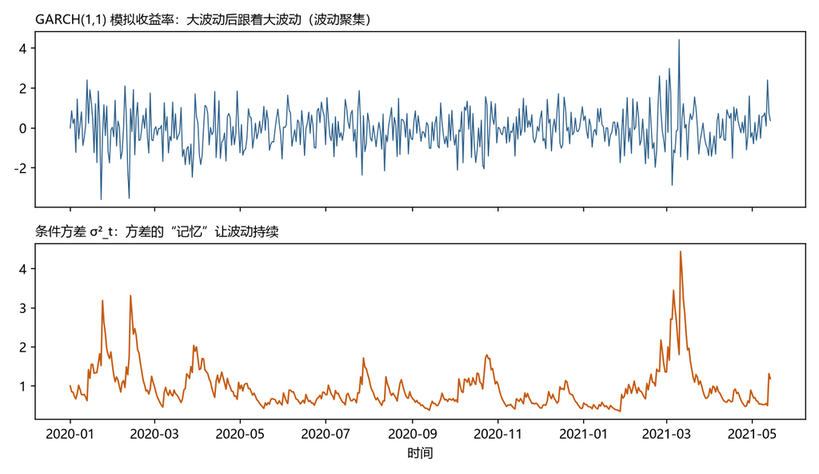

GARCH 模拟的波动聚集

*图 10.1 GARCH(1,1) 模拟：上图收益率”大波动后跟着大波动”（波动聚集）；下图条件方差 σ²_t 的”记忆”让波动持续——β₁ 是惯性旋钮的直观体现。*

## 10.5 这个环节可能遇到的问题（陷阱清单）

1. **对价格直接建 GARCH**：价格非平稳，GARCH 结果无意义。**先转收益率。**
2. **混用两种方差**：报告”长期方差=1”却说”明天波动√1.6”——两者都是对的，但一个是平均、一个是条件，**说清楚语境**。
3. **跳过均值模型**：残差不对，方差建模全错——**先均值、后方差，顺序不能乱**。
4. **对称模型硬套不对称数据**：有杠杆效应却用对称 GARCH → 系统性低估坏消息后的波动。**先看图/检验，不对称就上 EGARCH/GJR。**
5. **只报点预测**：GARCH 的价值在区间和 VaR——**只给 σ̂ 不给区间等于浪费。**
6. **阶数贪多**：GARCH(5,5) 拟合好但预测差——**GARCH(1,1) 起步，AIC 说话。**
7. **把”波动预测准”当”方向预测准”**：GARCH 不预测涨跌，只预测风险。**向决策者讲清楚：我们预测的是”多危险”，不是”涨还是跌”。**

## 10.6 相似问题与已有解决方案：历史回响

| 本环节的困难 | 谁遇到过 | 如何解决 | 本书对应 |
| --- | --- | --- | --- |
| “波动聚集怎么建模” | Engle (1982) 研究英国通胀 | **ARCH**：方差由过去冲击平方决定（诺贝尔经济学奖 2003） | 本章 |
| “ARCH 阶数太多” | Bollerslev (1986) | **GARCH**：加上方差自己的滞后，一两项就够 | 本章 |
| “坏消息影响更大” | Nelson (1991)；Glosten 等 (1993) | **EGARCH / GJR-GARCH**：不对称项 | 本章 |
| “波动率本身有随机性” | 金融计量 1980s | **随机波动率（SV）模型**：波动率当隐藏状态（状态空间） | 第 9 章 |
| “风险怎么量化” | 风险管理（1990s，J.P. Morgan RiskMetrics） | **VaR / 预期损失 ES**：把 σ̂ 换算成”最多亏多少” | 第 19 章 |
| “深度学习的波动率模型” | 2010s | 神经网络 GARCH 混合、LSTM 波动率预测 | 第 14 章 |

**核心启示**：ARCH/GARCH 是”**二阶结构建模**”的起点——均值之外，方差也值得建模、也可以预测。金融风险管理的一切（VaR、期权定价、压力测试）都站在它上面。

## 10.7 本章小结

1. **波动聚集**：大波动后跟大波动；它是金融收益”厚尾”的机制。
2. **ARCH**：方差 = 常数 + 过去冲击平方的加权——“大冲击顶起方差”。
3. **GARCH(1,1)**：σ²_t = α₀ + α₁ε²_{t−1} + β₁σ²_{t−1}；**α₁=新冲击，β₁=惯性，α₁+β₁=持久性（<1 且越接近 1 越聚集）**；长期方差 = α₀/(1−α₁−β₁)。
4. 流程：**收益率 → 均值残差 → ARCH 检验 → 拟合 GARCH → 用 σ̂ 算区间/VaR**。
5. 变体：EGARCH/GJR 处理不对称；SV 把波动率当隐藏状态（接第 9 章）。

下一章从单变量走向多变量：**两个或多个序列一起建模**——VAR、协整与误差修正。第 11 章 · 多变量时间序列：VAR、协整与误差修正。

## 10.8 练习与自测

1. ★ 什么是波动聚集？用一句话解释。（提示：10.1）
2. ★ GARCH(1,1) 中 α₁ 和 β₁ 各代表什么？（提示：10.2.3）
3. ★★ 模型 σ²_t = 0.2 + 0.1ε²_{t−1} + 0.8σ²_{t−1} 的持久性和长期方差是多少？（提示：10.4）
4. ★★ 为什么”坏消息后波动往往比好消息更大”需要用 EGARCH？（提示：10.2.4）
5. ★★★ 用 `arch` 库（Python）对任意股票收益率拟合 GARCH(1,1)，报告 α₁、β₁、持久性，并用预测的 σ̂ 算 95% VaR。（提示：10.3 五步）

**简答提示**：1 大波动后跟着大波动，波动率有记忆；2 α₁=新冲击的影响，β₁=波动惯性；3 持久性=0.9，长期方差=0.2/(1−0.9)=2；4 对称 GARCH 对正负冲击等权，会低估负冲击推升的波动，EGARCH/GJR 允许不对称；5 略（关注 α₁+β₁ 是否接近 1——金融收益率通常 0.95+，聚集强）。

## 10.9 本章审阅记录

| 审阅项 | 结论 | 问题与修订 |
| --- | --- | --- |
| R1 零基础可理解性 | ✔ 通过（自查） | α₀、α₁、β₁、ε²、σ²_t 全部逐项解释；无条件/条件方差先讲清区别；“惯性旋钮”类比 |
| R2 为何行动 | ✔ 通过 | 五步流程每步有”为什么”（先均值后方差、检验必要、VaR 用途） |
| R3 效果明确 | ✔ 通过 | 10.4 手算展示大冲击如何把 σ² 从 1.0 顶到 1.6 并持续 |
| R4 陷阱覆盖 | ✔ 通过 | 7 条：价格 vs 收益率、两种方差、顺序、不对称、只报点、阶数、方向 vs 风险 |
| R5 相似问题映射 | ✔ 通过 | 6 行映射（ARCH→GARCH→EGARCH→SV→VaR→深度学习） |
| R6 示例可复现 | ✔ 通过 | 长期方差=1、1.6、1.22 手算验算；练习 3（持久 0.9、长期方差 2）验算 |
| R7 章节衔接 | ✔ 通过 | 开头接第 3 章厚尾，结尾预告第 11 章多变量 |
| R8 练习有效 | ✔ 通过 | 5 题覆盖定义、系数、计算、不对称、实践 VaR |

**审阅方式**：作者自查（R1–R8 逐项）+ 数字验算；本章为经典计量章，未启用子代理。

# 第 11 章 · 多变量时间序列：VAR、协整与误差修正

**本章目标**：学完本章后，你能①用一句话解释 VAR；②解释”协整”如何把第 4 章的伪回归从陷阱变成工具；③理解误差修正模型的”长期均衡+短期修正”直觉；④说出格兰杰因果检验检验的是什么（以及不是什么）。

## 11.1 动机：变量之间会”互相说话”

前几章都是**单变量**：只有一个序列，用自己的历史预测自己。但现实几乎总是多变量的：利率影响汇率，汇率影响出口，出口影响 GDP……**变量互相影响，信息藏在交叉项里**。

多变量建模有三个经典难题，本章逐一解决：

1. **互相影响怎么建模？** → VAR（让每个变量都听别人的过去）
2. **多个非平稳序列：伪回归还是真关系？** → 协整（第 4 章的陷阱在这里反转成工具）
3. **短期波动与长期均衡怎么统一？** → 误差修正模型（ECM）

> 一句话：**单变量建模回答”这一个序列怎么动”；多变量建模回答”这几个序列为什么一起动、谁带动谁、动完会不会回到均衡”。**

## 11.2 是什么：三件工具

### 11.2.1 VAR(p)：向量自回归

**VAR（Vector Autoregression，向量自回归）**：把单变量 AR 推广到多变量——**每个变量都用所有变量（包括自己）的滞后值来回归**。

以两个变量（x、y）的 VAR(1) 为例，两个方程：

```
x_t = c₁ + a₁₁·x_{t−1} + a₁₂·y_{t−1} + ε₁t
y_t = c₂ + a₂₁·x_{t−1} + a₂₂·y_{t−1} + ε₂t
```

- `a₁₂`：y 的过去对 x 现在的影响（**交叉影响**）；
- `a₂₁`：x 的过去对 y 现在的影响；
- 残差 ε₁t、ε₂t 允许互相相关（同期联动）。

**直觉**：*x 和 y 互相看对方的”脸色”——但都只看过去（没有未来泄漏）。*

**为什么用 VAR**：当你**不知道因果方向**时（利率影响汇率还是汇率影响利率？），VAR 让数据自己说话——不预设方向，把所有滞后都放进去。配套工具： - **脉冲响应函数（IRF）**：给 x 一个冲击，看 y 随后几期怎么反应——“一个冲击如何传染”； - **方差分解**：y 的波动有多少来自 x 的冲击——“谁主导谁”。

### 11.2.2 协整（cointegration）：伪回归的解药

回到第 4 章的伪回归：两个 I(1) 序列（非平稳，有单位根）做回归会得到虚假的高相关。但 Engle & Granger (1987) 发现了重要的例外：

> **如果两个非平稳序列的某个线性组合是平稳的**（比如”消费 − 0.9×收入”围绕 0 波动），那么它们之间存在**长期均衡关系**——这叫**协整**。

```
消费_t 和 收入_t 都非平稳（都随经济一起涨）
但  消费_t − 0.9·收入_t ≈ 平稳（围绕一个常数波动）
→ 消费与收入协整：0.9 是长期弹性，偏离会被拉回
```

**为什么这不是伪回归**：伪回归的两个序列**各自漂移、互不相干**，组合后还是非平稳；协整序列**互相约束**——短期可以偏离，但长期会被”拉回”均衡线。**相关来自真实的机制（共同均衡），不是共同的时间位置。**

> 关键区分（背下来）：**协整 = 有长期均衡的”真关系”；无协整 = 各自漂移的”假关系”。** 伪回归的陷阱只对”无协整”成立。

### 11.2.3 误差修正模型（ECM）：把短期和长期焊在一起

**ECM** 把”短期动态”和”长期均衡”放进同一个模型：

```
Δx_t = （短期项：Δx_{t−1}, Δy_{t−1} 等） + γ·(x_{t−1} − β·y_{t−1}) + 噪声
```

- 括号 `x_{t−1} − β·y_{t−1}`：**上期偏离均衡的程度**（误差）；
- `γ`（通常为负）：**修正速度**——偏离均衡多远，本期就拉回多少。

**直觉（橡皮筋）**：消费和收入之间有一根橡皮筋（长期均衡）。短期任何冲击都可以让消费偏离（橡皮筋被拉长），但下期橡皮筋会把消费**拉回均衡线**——γ 就是橡皮筋的”劲”。

**为什么需要它**：只差分（第 8 章）会丢掉长期均衡信息（两个协整序列差分后不再有均衡约束）；只做水平回归会伪回归。**ECM 两全：短期动态 + 长期均衡。**

### 11.2.4 格兰杰因果（Granger causality）：一个”预测”意义上的因果

**格兰杰因果检验**：*如果 x 的过去能显著改进对 y 的预测，就说”x 格兰杰因果于 y”*（在控制了 y 自身历史之后）。

- **注意**：这是**统计预测意义**的因果，不是哲学/物理意义（“鸡叫格兰杰因果于日出”——鸡叫确实帮助预测日出，但鸡叫不导致日出）。
- **用途**：初筛”谁领先谁”；**千万别在报告里写成”x 导致 y”**（第 4、19 章的忠告再强调一次）。

## 11.3 怎么做：五步流程

### 第 1 步 · 逐序列平稳性检验

- **做什么**：对每个序列跑第 4 章流程（ADF/KPSS），记录”单整阶数”（差几次才平稳，I(0)/I(1)）。
- **为什么**：协整要求各序列**同阶单整**（通常都 I(1)）；阶数不同则协整无意义。
- **会怎样**：得到”全部 I(1)“或”混合”的结论，决定走哪条路。

### 第 2 步 · 协整检验

- **做什么**：全部 I(1) → 检验是否存在协整（Engle-Granger 两步法：先回归取残差，再对残差做单位根检验；或 Johansen 检验处理多个协整向量）。
- **为什么**：决定”能不能谈长期关系”——有协整走 ECM，无协整只能差分后建 VAR。
- **会怎样**：两个分支：**有协整**（真关系，建 ECM）或**无协整**（假关系，差分建 VAR）。

### 第 3 步 · 建模

- **做什么**：有协整 → ECM（估计长期 β 与修正速度 γ）；无协整 → 差分后 VAR（选阶用 AIC）。
- **为什么**：ECM 保长期信息，VAR 只做短期——按第 2 步的证据选。
- **会怎样**：得到一组方程，系数都有解释（β=长期弹性、γ=修正速度）。

### 第 4 步 · 诊断

- **做什么**：检查残差（各自白噪声、无遗漏滞后）；必要时加大阶数。
- **为什么**：残差有结构 = 模型没抓全变量间关系。
- **会怎样**：模型合格，进入解读。

### 第 5 步 · 解读与预测

- **做什么**：①看 γ 的大小（修正快慢）；②跑脉冲响应（给 x 一个冲击，看 y 的反应路径）；③格兰杰因果检验（谁领先谁）；④预测。
- **为什么**：多变量模型的产出不只是预测，更是**机制解读**——“冲击怎么传导”。
- **会怎样**：得到”冲击传导图”与预测，向决策者解释”哪个变量驱动哪个”。

## 11.4 完整示例：消费与收入的协整（概念手算）

假设长期均衡 `消费 = 0.9×收入`，修正速度 γ = −0.3，ECM 简化成：

```
Δ消费_t = 短期项 + (−0.3)·(消费_{t−1} − 0.9×收入_{t−1})
```

**情景**：某期消费比均衡值高 1（比如 消费−0.9×收入 = +1——消费过度）。

```
修正项 = −0.3 × (+1) = −0.3
→ 下一期消费被拉回 0.3（约 30% 的偏离被修正）
```

**观察**：偏离 1 → 一期修掉 0.3，偏离剩 0.7；下一期再修 0.3×0.7=0.21……**偏离按 γ 的比例逐步衰减回均衡**——这就是”误差修正”的字面含义。γ=−0.3 表示”每期修正 30%“。

**效果**：你看到了橡皮筋怎么工作——**短期随便跑，长期被均衡拉着走**。这也解释了协整序列为何”一起动”：它们被同一根橡皮筋拴着。

## 11.5 这个环节可能遇到的问题（陷阱清单）

1. **不检验单整直接回归**：第 4 章伪回归的现场版。**先 ADF，再谈关系。**
2. **把格兰杰因果当真因果**：鸡叫问题。**报告里写”领先关系/预测改进”，不写”导致”。**
3. **协整解释过度**：β 估计显著≠经济含义正确（可能只是统计均衡）。**解释 β 要有经济理论支撑。**
4. **忽略协整直接差分**：把长期均衡信息差没了——**有协整就该 ECM。**
5. **小样本硬上 VAR**：VAR 参数随变量数平方增长（2 变量 VAR(2) 已 10+ 参数）——**变量和阶数都要克制，样本不足会过拟合。**
6. **脉冲响应不给置信区间**：IRF 是估计出来的，有不确定性——**软件默认给置信带，别关。**
7. **同阶单整条件忽略**：I(1) 和 I(2) 混在一起谈协整——**先核对单整阶数。**

## 11.6 相似问题与已有解决方案：历史回响

| 本环节的困难 | 谁遇到过 | 如何解决 | 本书对应 |
| --- | --- | --- | --- |
| “多变量互相影响” | Sims (1980) 宏观计量革命 | **VAR** 与脉冲响应（诺贝尔经济学奖 2011） | 本章 |
| “伪回归 vs 真关系” | Engle & Granger (1987) | **协整**：线性组合平稳 = 长期均衡（诺贝尔经济学奖 2003） | 本章；第 4 章 |
| “多个协整向量” | Johansen (1988, 1991) | **Johansen 检验**与 VECM | 本章 |
| “谁预测谁” | Granger (1969) | **格兰杰因果检验**（预测意义，非哲学因果） | 本章 |
| “非线性/非平稳因果” | 现代因果发现 | **PCMCI** 等（第 19 章）：从观测恢复因果图 | 第 19 章 |

**核心启示**：多变量时序的真正难度不是公式，而是**判断”关系是真是假”**——协整检验是伪回归的裁判；而”因果”二字必须永远加引号（预测意义）。这为第 19 章的因果推断埋下伏笔。

## 11.7 本章小结

1. **VAR**：所有变量互相回归——不知道因果方向时让数据说话；配脉冲响应看”冲击怎么传导”。
2. **协整**：非平稳序列的线性组合平稳 = 长期均衡；**有协整是真关系，无协整是伪回归**（第 4 章陷阱的解药）。
3. **ECM**：短期动态 + γ×(上期偏离均衡) 修正项——“橡皮筋”把短期拉回长期。
4. **格兰杰因果**：预测意义上的”领先关系”，**不是因果**。
5. 流程：**单整检验 → 协整检验 → 分支建模（ECM 或差分 VAR）→ 诊断 → IRF/预测**。

下一章处理”规则突然改变”：**马尔可夫机制转换**——同一个序列，可能在”扩张/衰退”两个状态间跳来跳去。第 12 章 · 非线性与机制转换：马尔可夫转换模型。

## 11.8 练习与自测

1. ★ VAR 和单变量 AR 的本质区别是什么？（提示：11.2.1）
2. ★ 协整的定义是什么？它如何避开伪回归？（提示：11.2.2）
3. ★★ ECM 里 γ=−0.4，某期偏离均衡 +2，下一期预计修正多少？（提示：11.4）
4. ★★ 为什么”鸡叫格兰杰因果于日出”说明格兰杰因果≠因果？（提示：11.2.4）
5. ★★★ 用 `statsmodels` 的协整检验对”消费 vs 收入”类真实数据（或自造协整序列）跑一次 Engle-Granger，报告检验结论并解释”长期均衡”。（提示：11.3 五步）

**简答提示**：1 AR 只用自己历史，VAR 用所有变量的历史（含交叉影响）；2 非平稳序列的线性组合平稳＝协整；组合平稳意味着偏离被拉回（机制约束），而非各自漂移（假相关）；3 修正 = −0.4×2 = −0.8（偏离被拉回 0.8）；4 鸡叫确实改善对日出的预测，但鸡叫不导致日出——格兰杰因果只检验”预测改进”；5 略。

## 11.9 本章审阅记录

| 审阅项 | 结论 | 问题与修订 |
| --- | --- | --- |
| R1 零基础可理解性 | ✔ 通过（自查） | a₁₁/a₁₂ 逐项解释；橡皮筋类比贯穿 ECM；I(1) 单整阶数在首现处解释 |
| R2 为何行动 | ✔ 通过 | 五步流程每步有”为什么”（协整检验决定分支、ECM 保长期信息） |
| R3 效果明确 | ✔ 通过 | 11.4 手算（−0.3、0.7、0.21 衰减链）展示修正机制 |
| R4 陷阱覆盖 | ✔ 通过 | 7 条：不检验直接回归、格兰杰≠因果、解释过度、丢均衡、小样本、IRF 无区间、单整阶数 |
| R5 相似问题映射 | ✔ 通过 | 5 行映射（VAR/协整/Johansen/格兰杰/PCMCI），与第 4、19 章呼应 |
| R6 示例可复现 | ✔ 通过 | 修正 0.3/0.21 递推验算；练习 3（−0.8）验算 |
| R7 章节衔接 | ✔ 通过 | 开头接第 4 章伪回归，结尾预告第 12 章机制转换 |
| R8 练习有效 | ✔ 通过 | 5 题覆盖 VAR/协整/ECM 计算/格兰杰/实践 |

**审阅方式**：作者自查（R1–R8 逐项）+ 数字验算；本章为计量衔接章，未启用子代理。

# 第 12 章 · 非线性与机制转换：马尔可夫转换模型

**本章目标**：学完本章后，你能①解释”机制/状态”的含义与例子；②理解马尔可夫链的转移概率；③说出 Hamilton (1989) 模型”状态不同、参数不同”的核心思想；④读出平滑概率并识别切换点；⑤区分”反复切换”（马尔可夫转换）与”一次性断点”。

## 12.1 动机：规则不是永远不变的

第 4 章说过：平稳性检验默认”规则要么一直不变、要么一直变”。但现实是第三种情况：**规则会切换**。

- 经济：扩张期（GDP 稳步增长、波动小）→ 衰退期（GDP 萎缩、波动大）；
- 股市：平静期（低波动）→ 危机期（暴跌、高波动）；
- 电力：正常负荷 → 极端天气负荷；
- 气候：厄尔尼诺年 vs 正常年。

每一段内部，序列近似平稳（扩张期有扩张的规律）；但段与段之间，规律**跳变**。第 4 章陷阱 7 预告的”结构性断点”问题，本章给出正解：

> **马尔可夫机制转换模型（Markov-switching model）**：假设序列在一个”隐状态”之间跳来跳去，每个状态有自己的参数；状态按**马尔可夫链**转移。Hamilton (1989) 用它成功识别了美国经济的扩张/衰退周期。

## 12.2 是什么：三个部件

### 12.2.1 状态（regime / state）

**状态**：数据的一种”行为模式”。模型假设每个时刻 t 处于某个状态 s_t ∈ {1, 2, …, K}（K 个状态）。

- 例：K=2，状态 1 = 扩张，状态 2 = 衰退；
- 每个状态有自己的**参数**：扩张期均值 μ₁、方差 σ₁²；衰退期 μ₂、方差 σ₂²（衰退期方差通常更大）。

**为什么需要状态**：一个”均值恒定、方差恒定”的模型无法同时描述扩张与衰退——**参数必须随状态变**。

### 12.2.2 马尔可夫链与转移概率

状态 s_t 的演变服从**马尔可夫链**：*明天的状态只取决于今天的状态*（第 1 层”记忆”）。用**转移概率**描述：

```
P(明天是状态 1 | 今天是状态 1) = p₁₁
P(明天是状态 2 | 今天是状态 1) = 1 − p₁₁
```

转移概率矩阵（K=2）：

```
     明天=1  明天=2
今天=1  [ p₁₁   1−p₁₁ ]
今天=2  [ 1−p₂₂   p₂₂ ]
```

- p₁₁ 大（如 0.95）：状态 1 很”粘”——进去了不容易出来（扩张持续很久）；
- p₂₂ 大：状态 2 也粘（衰退一旦开始也拖很久）。

**直觉**：*状态不是固定的，也不是随机的每一期重抽，而是”赖着不走、偶尔跳变”——这正是经济周期、市场体制的现实。*

### 12.2.3 Hamilton 模型：状态不同，参数不同

Hamilton (1989) 的核心模型（含均值切换的 AR(1)）：

```
x_t − μ_{s_t} = φ·(x_{t−1} − μ_{s_{t−1}}) + ε_t
```

- `μ_{s_t}`：**随状态切换的均值**（扩张期 μ₁ 高、衰退期 μ₂ 低）——模型的关键创新；
- φ：自回归系数（可随状态变，也可不变）；
- ε_t：白噪声（方差也可随状态变：σ²_{s_t}）。

**输出之一：平滑概率（smoothed probability）**——用**全部数据**事后算出的”每个时刻处于各状态的概率”。例如”1990 年 7 月处于衰退的概率 = 0.97”——**这就是自动标注的经济周期日历**。

## 12.3 怎么做：五步流程

### 第 1 步 · 定状态数与状态特征

- **做什么**：决定 K（通常从 2 开始）与哪些参数随状态变（均值？方差？）。
- **为什么**：状态数是模型结构的一部分；K=2 是经济周期研究的默认起点，用 BIC 比较 K=2/3。
- **会怎样**：得到”2 状态、均值+方差都随状态变”的模型设定。

### 第 2 步 · 写模型

- **做什么**：明确每个状态的参数（μ₁、σ₁²、μ₂、σ₂²…）与转移矩阵 p₁₁、p₂₂。
- **为什么**：参数决定每个状态”长什么样”。
- **会怎样**：模型被完全指定，进入估计。

### 第 3 步 · 估计

- **做什么**：用极大似然（EM 算法）估计全部参数：各状态均值/方差、φ、转移概率。
- **为什么**：让模型最可能产生这串数据。
- **会怎样**：得到参数估计——比如”状态 1：均值 +0.8%、方差 0.5%；状态 2：均值 −1.2%、方差 2.0%“。

### 第 4 步 · 读平滑概率，找切换点

- **做什么**：画出每个时刻处于”状态 2”的概率曲线；概率 >0.5 视为”处于状态 2”。
- **为什么**：这是模型的”自动日历”——哪段在扩张、哪段在衰退。
- **会怎样**：得到一张”状态时间线”，与官方衰退日期对照验证模型。

### 第 5 步 · 预测与诊断

- **做什么**：预测 = 各状态预测的**概率加权**（按状态预测概率）；诊断 = 残差白噪声、转移概率的置信区间。
- **为什么**：未来状态未知，预测必须加权而非选一个状态。
- **会怎样**：得到概率意义的预测——“40% 概率衰退，预测增长率 −1.5%…”。

## 12.4 完整示例：平静与动荡两个状态

设两个状态：**平静**（均值 0、方差 1）与**动荡**（均值 0、方差 9），转移概率 p₁₁ = p₂₂ = 0.95。

- 若今天在平静：明天 95% 还平静，5% 跳动荡——**平静期平均持续 1/0.05 = 20 期**；
- 若今天在动荡：明天 95% 还动荡，5% 跳回平静——动荡期平均也约 20 期；
- 一条模拟序列看起来：**长长的一段小波动，突然变成大波动，持续一段，又变回去**——这就是”波动聚集 + 机制切换”的现实长相。

**平滑概率的作用**：事后回看，软件会告诉你在每个时点”动荡概率是 0.98”——**自动切分了安静与风暴**。若没有模型，你只能肉眼猜”哪段算风暴”。

**效果**：机制转换模型把”何时切换”从主观判断变成**可检验的估计**——这是它最大的价值（经济周期委员会要开几个月会，模型几秒钟给答案，虽然两者互补）。

## 12.5 这个环节可能遇到的问题（陷阱清单）

1. **状态数拍脑袋**：K=2 是起点不是终点；**用 BIC 比较 K=2/3/4，别贪多。**
2. **标签身份问题**：估计出来的”状态 1/2”本身没有名字——**扩张/衰退的名字要你自己对着参数贴**（均值高的叫扩张）。
3. **混淆”反复切换”与”一次性断点”**：马尔可夫转换允许来回切（扩张→衰退→扩张）；若历史只有一个断点（如政策改革后永不回头），应改用**结构突变检验**（Chow 检验等）。
4. **预测时忽略状态不确定性**：只报”最可能状态”的预测 = 丢掉了”可能已切换”的信息——**概率加权才是正确预测。**
5. **小样本估计不稳**：转移概率与状态数在小样本下估计方差大——**样本不足时结果别写死。**
6. **与 GARCH 的波动聚集混淆**：GARCH 是”方差平滑变化”（记忆型），机制转换是”方差跳变”（切换型）——两者可共存（有马尔可夫-GARCH 混合），先分清你想建模哪种。

## 12.6 相似问题与已有解决方案：历史回响

| 本环节的困难 | 谁遇到过 | 如何解决 | 本书对应 |
| --- | --- | --- | --- |
| “经济周期有体制” | Hamilton (1989) | **马尔可夫机制转换**：状态切换 + 平滑概率 | 本章 |
| “语音/序列有隐藏状态” | 语音识别（1970s） | **隐马尔可夫模型（HMM）**：同一数学家族 | 本章 |
| “状态是隐藏的、要追踪” | 控制工程 | **状态空间 + 卡尔曼滤波**（状态连续）vs 马尔可夫转换（状态离散） | 第 9 章 |
| “一次性断点” | 计量经济学（Chow 1960） | **结构突变检验**（Chow、Bai-Perron） | 本章 |
| “深度学习的软切换” | 2010s | RNN 的门控（LSTM 的”门”≈软状态切换） | 第 14 章 |

**核心启示**：离散状态切换（马尔可夫）与连续状态演化（卡尔曼）是”隐藏机制”的两大范式；现代深度学习的门控机制是它们的神经网络化身——**“状态”这个思想贯穿了第 9 章到今天。**

## 12.7 本章小结

1. **机制转换**：序列在 K 个”行为模式”间跳变，每个状态有自己的参数（均值、方差）。
2. **马尔可夫链**：状态只依赖上一状态，用转移概率（p₁₁、p₂₂）描述”粘性”。
3. **Hamilton (1989)**：x_t − μ_{s_t} = φ(x_{t−1} − μ_{s_{t−1}}) + ε_t——均值随状态切换。
4. **平滑概率**：事后算出”每个时刻处于各状态的概率”——自动的经济周期日历。
5. 区分：**反复切换**用马尔可夫转换，**一次性断点**用结构突变检验；预测要概率加权。

至此，**第三部分（经典统计方法）完成**。你已经掌握了从平滑、ARIMA、状态空间、GARCH 到协整、机制转换的完整经典工具箱。下一部分进入机器学习与深度学习——第 13 章 · 机器学习视角：特征工程、树模型与 SVM。

## 12.8 练习与自测

1. ★ 什么是”状态”？举一个现实例子。（提示：12.2.1）
2. ★ 转移概率 p₁₁=0.9 意味着什么？（提示：12.2.2）
3. ★★ 平滑概率有什么用？（提示：12.2.3）
4. ★★ “某个政策改革让经济规则永远改变”——该用马尔可夫转换还是结构突变检验？（提示：12.5 陷阱 3）
5. ★★★ 用 `statsmodels` 的 `MarkovRegression` 对 GDP 增长率数据拟合 2 状态模型，报告两状态的均值/方差与平滑概率，并与官方衰退日期对照。（提示：12.3 五步）

**简答提示**：1 数据的一种行为模式，如扩张/衰退、平静/动荡；2 状态 1 很粘——明天 90% 概率留在状态 1，平均持续 1/(1−0.9)=10 期；3 用全部数据回算每个时刻处于各状态的概率，自动切分时段（经济周期日历）；4 一次性、永不回头 → 结构突变检验；可反复来回 → 马尔可夫转换；5 略。

## 12.9 本章审阅记录

| 审阅项 | 结论 | 问题与修订 |
| --- | --- | --- |
| R1 零基础可理解性 | ✔ 通过（自查） | 状态/转移概率/平滑概率均用经济周期实例定义；Hamilton 公式逐符号解释 |
| R2 为何行动 | ✔ 通过 | 五步流程每步有”为什么”（BIC 定 K、概率加权预测的理由） |
| R3 效果明确 | ✔ 通过 | 12.4 示例展示”20 期平均持续期”与平滑概率的切分价值 |
| R4 陷阱覆盖 | ✔ 通过 | 6 条：K 拍脑袋、标签身份、反复切换 vs 断点、状态不确定、小样本、与 GARCH 混淆 |
| R5 相似问题映射 | ✔ 通过 | 5 行映射（Hamilton/HMM/卡尔曼/Chow/RNN 门控），横向打通 |
| R6 示例可复现 | ✔ 通过 | 平均持续期 1/0.05=20 期验算；练习 2（10 期）验算 |
| R7 章节衔接 | ✔ 通过 | 开头接第 4 章断点预告与第 11 章，结尾宣布第三部分完成并预告第 13 章 |
| R8 练习有效 | ✔ 通过 | 5 题覆盖状态、转移概率、平滑概率、断点区分、实践 |

**审阅方式**：作者自查（R1–R8 逐项）+ 数字验算；本章为第三部分收尾章，未启用子代理。

# 第 13 章 · 机器学习视角：特征工程、树模型与 SVM

**本章目标**：学完本章后，你能①理解”把时序变成特征矩阵”的通用做法（滑窗）；②说出树模型（随机森林/GBDT）与 SVM 处理时序的强项与短板；③理解”时间切分”为什么是时序机器学习的铁律；④建立”统计基线优先”的评测纪律。

## 13.1 动机：机器学习能”自动找关系”，但它不懂时间

第 6~12 章的方法都是”为时间而生”的：自相关、差分、状态、机制……而机器学习（ML）是另一条路线：**不假设时序结构，把”预测”变成”通用函数拟合”**——用历史窗口当特征，让算法自动学”x_{t−1}, x_{t−2}… → x_t”的映射。

这条路线在 1990s–2010s 大放异彩（SVM、随机森林、梯度提升树在无数竞赛中碾压统计模型），但它有个致命陷阱：**ML 默认”样本独立”，而时序样本不独立**——随机切分训练/测试会泄漏未来。这一章讲清楚：怎么用 ML、怎么不踩泄漏。

> 一句话：**ML 是”通用拟合器”，时序是”有顺序的数据”——两者的结合需要两件事：滑窗特征 + 时间切分。**

## 13.2 是什么：把时间”压扁”成表格

### 13.2.1 滑窗（rolling window）：时序→特征矩阵

要把 ML 用在时序上，第一步是把序列变成”特征表”。对序列 x₁…x_T，用滞后窗口 p 造特征：

| 行（样本） | 特征 1（x_{t−1}） | 特征 2（x_{t−2}） | 目标（x_t） |
| --- | --- | --- | --- |
| t=3 | x₂ | x₁ | x₃ |
| t=4 | x₃ | x₂ | x₄ |
| … | … | … | … |

**直觉**：把”过去的 p 个值”拼成一行，让模型学”这行 → 下一个值”。**这是”非线性自回归”的表格化**——和第 7 章 AR 的差别是：AR 假设线性，ML 允许任意函数。

### 13.2.2 三大算法（时序视角）

| 算法 | 强项 | 时序短板 |
| --- | --- | --- |
| **SVM / SVR** | 小样本、核技巧捕捉非线性 | 参数敏感；长序列效率低；不原生处理时间 |
| **随机森林**（Breiman 2001） | 抗过拟合、可给特征重要性 | 不能外推超出训练范围（预测值被训练值”夹住”） |
| **梯度提升树**（GBDT/XGBoost/LightGBM） | 竞赛之王：表格数据几乎总是最优之一；可处理大量外生特征 | 同随机森林：**不擅长外推**；对趋势序列预测值有偏 |

**关键短板（背下来）**：树模型（RF/GBDT）本质是”分段常数”拟合——**它们只能插值，不能外推**。训练时最大值是 100，预测值永远 ≤100。对有上升趋势的序列，树模型天然吃亏；这正是第 2 章”线性基线之争”的 ML 版本：**树模型的强项在”分类”与”带大量特征的表格预测”，不在”趋势外推”。**

### 13.2.3 时间切分：铁律

```
❌ 随机切分：训练 = 第 1、5、9…月；测试 = 第 2、6、10…月 → 模型"见过"测试期附近的数据 → 泄漏
✅ 时间切分：训练 = 前 80% 时间；测试 = 后 20% 时间
✅ 滚动切分（rolling window / TimeSeriesSplit）：多次前移切分点，平均评估
```

**为什么**：预测的本质是”用过去预测未来”，模型必须**永远没见过未来**。随机切分让模型”偷看”了测试数据（第 1 章泄漏的正式版）。

## 13.3 怎么做：五步流程

### 第 1 步 · 先跑统计基线

- **做什么**：先用指数平滑/ARIMA/简单线性（第 6、8 章）做预测，记录 MAE/RMSE。
- **为什么**：基线是”及格线”——ML 必须超过它才算赢；很多项目 ML 打不过基线（第 2 章反复强调）。
- **会怎样**：有了比较的标尺。

### 第 2 步 · 造特征

- **做什么**：滑窗滞后值 + 日历特征（星期几、月份、节假日）+ 外生变量（天气、活动）。
- **为什么**：ML 自己”看不见”时间，星期/月份/节假日要显式给。
- **会怎样**：得到特征矩阵；**特征质量往往比算法选择更决定结果**（垃圾进垃圾出）。

### 第 3 步 · 时间切分（铁律）

- **做什么**：按时间顺序切训练/验证/测试；用滚动切分做调参。
- **为什么**：防泄漏（13.2.3）；滚动切分让评估稳定。
- **会怎样**：每个模型在同一批”未来”上可比。

### 第 4 步 · 训练与调参

- **做什么**：训练（如 LightGBM），用验证集调超参（树深度、学习率等）。
- **为什么**：超参决定偏差-方差平衡；**调参只能在验证集上做，测试集只能碰一次**（否则测试集也变训练集）。
- **会怎样**：得到一个验证集上表现最好的模型。

### 第 5 步 · 测试与对比

- **做什么**：在测试集上评估，与第 1 步基线对比；报告”提升多少、代价多大（复杂度）“。
- **为什么**：ML 的胜出必须是**样本外**的、超过基线的、值得复杂度的。
- **会怎样**：得到结论——“GBDT 比 ARIMA 提升 12% MAE（测试集，滚动验证），但需要 50 个特征”；或”GBDT 没打过基线，回归统计”。

## 13.4 完整示例：一个”该不该用 ML”的判断

数据：某商品周销量 200 周，有明显趋势 + 12 月季节高峰，另有 5 个外生变量（促销、价格、天气）。

- **基线**：Holt-Winters（第 6 章）测试集 MAE = 120。
- **ML**：LightGBM + 滑窗 4 周 + 周/月特征 + 5 外生变量，测试集 MAE = 105（提升 12%）。
- **判断**：ML 赢了，但要看 ①提升是否稳定（换几个测试段）；②复杂度代价（模型维护 vs 简单规则）；③外生变量的解释价值。

**效果**：12% 的提升在业务上可能值钱（减少库存浪费），也可能不值得（引入 50 个特征、每季度重训）。**ML 的价值 = 样本外提升 − 复杂度代价**——这个算式是本章最该带走的东西。

## 13.5 这个环节可能遇到的问题（陷阱清单）

1. **随机切分**：泄漏，测试成绩虚高，上线翻车——**第 1 条铁律，没有之一**。
2. **树模型外推**：趋势序列用 GBDT 预测，输出被训练范围”夹住”，系统性偏低——**要么先差分/去趋势，要么换线性外推类模型。**
3. **特征里混入未来**：比如用”当月平均气温”预测”当月销量”——气温是当月才知道的（或与销量同期），训练时”知道”未来 → 泄漏的隐蔽版。**每个特征必须确认”预测时点拿得到”。**
4. **测试集反复碰**：同一测试集上调 50 次参，等于把测试集变训练集——**测试集只能碰一次。**
5. **只报最佳结果**：只报最好的那一组超参结果，不报平均/方差——**报告多段滚动验证的分布，不是单点。**
6. **忽略统计基线**：不跑基线直接上 ML——**ML 赢了基线才算赢，否则是自嗨。**
7. **时序交叉验证误用**：K-fold（随机分 K 折）在时序上不能用，**必须用 TimeSeriesSplit 式的前向切分**。

## 13.6 相似问题与已有解决方案：历史回响

| 本环节的困难 | 谁遇到过 | 如何解决 | 本书对应 |
| --- | --- | --- | --- |
| “样本不独立，交叉验证怎么用” | 机器学习实践（2010s） | **TimeSeriesSplit / 滚动前向验证**；阻塞交叉验证 | 本章；第 19 章 |
| “树模型不擅外推” | 竞赛实践（M4、Kaggle） | 混合策略：**树模型建模残差/分类，线性或统计模型建模趋势** | 本章；第 5 章工具 |
| “ML 赢了才算赢” | Makridakis M4/M5 竞赛 | 统计+ML **集成**长期霸榜；基线对比成为惯例 | 第 6 章；第 19 章 |
| “特征重要性与解释” | ML 可解释性（Lundberg & Lee 2017） | **SHAP** 等归因（但时序版有局限，第 19 章细说） | 第 19 章 |
| “深度学习替代手工特征” | 2010s | **端到端深度学习**（第 14 章）自动学特征——但数据量要求高 | 第 14 章 |

**核心启示**：ML 的时序应用，难点从来不是算法，而是**数据协议**（切分、特征时点、基线对比）。协议对了，LightGBM 也能打；协议错了，Transformer 也白搭。

## 13.7 本章小结

1. **滑窗**把时序压成特征表：过去的 p 个值 → 预测下一个——“非线性自回归”。
2. **算法取舍**：树模型表格数据强、但不擅外推；SVM 小样本强、效率差；**特征质量 > 算法选择**。
3. **铁律**：**时间切分 + 特征时点不越界 + 测试集只碰一次**——三者缺一即泄漏。
4. **纪律**：先跑统计基线；ML 的胜出 = 样本外提升 − 复杂度代价。
5. 树模型的短板（外推）正是下一章深度学习想解决的问题之一。

下一章进入深度学习：**让模型自己学”什么时候该记多久、该给谁加权”**——RNN、LSTM 与 TCN。第 14 章 · 深度学习入门：RNN、LSTM 与 TCN。

## 13.8 练习与自测

1. ★ 滑窗的作用是什么？（提示：13.2.1）
2. ★ 为什么树模型预测不了”超出训练范围”的趋势值？（提示：13.2.2）
3. ★★ 一个特征”当月平均气温”预测”当月销量”为什么可能泄漏？（提示：13.5 陷阱 3）
4. ★★ 为什么时序不能用随机 K-fold 交叉验证？（提示：13.2.3）
5. ★★★ 用 `sktime` 或 `sklearn` 的 `TimeSeriesSplit` 对任意序列跑一次”ARIMA 基线 vs LightGBM”的滚动验证对比，写结论。（提示：13.3 五步）

**简答提示**：1 把过去的滞后值拼成特征行，让通用 ML 学非线性自回归；2 树模型是分段常数，输出被训练样本的极值范围”夹住”，无法外推；3 当月平均气温要到月底才知道，预测月初销量时拿不到它（若用全年平均或预测值则 OK）——特征的可获取时点必须早于预测时点；4 K-fold 随机打乱会把未来的样本放进训练集（泄漏），时序必须前向切分；5 略。

## 13.9 本章审阅记录

| 审阅项 | 结论 | 问题与修订 |
| --- | --- | --- |
| R1 零基础可理解性 | ✔ 通过（自查） | 滑窗表格示例直观；“压扁成表格”“垃圾进垃圾出”等类比 |
| R2 为何行动 | ✔ 通过 | 五步流程每步有”为什么”（基线先行、特征时点、测试只碰一次） |
| R3 效果明确 | ✔ 通过 | 13.4 示例给出具体数字（120 vs 105 与判断算式） |
| R4 陷阱覆盖 | ✔ 通过 | 7 条全部围绕”泄漏”与”外推”两大主题，有实操指向 |
| R5 相似问题映射 | ✔ 通过 | 5 行映射（TimeSeriesSplit、混合策略、M4、SHAP、深度学习） |
| R6 示例可复现 | ✔ 通过 | 13.4 数字自洽；练习答案逻辑通顺 |
| R7 章节衔接 | ✔ 通过 | 开头接第三部分总结，结尾预告第 14 章深度学习 |
| R8 练习有效 | ✔ 通过 | 5 题覆盖滑窗、外推、隐蔽泄漏、切分、实践 |

**审阅方式**：作者自查（R1–R8 逐项）；本章为 ML 过渡章，未启用子代理。

# 第 14 章 · 深度学习入门：RNN、LSTM 与 TCN

**本章目标**：学完本章后，你能①理解 RNN”循环共享权重”的结构；②解释梯度消失如何催生 LSTM，以及”门”的直觉；③说出 TCN 因果卷积与膨胀的设计；④判断”这个任务该不该用深度学习”。

## 14.1 动机：让模型自己学”该记多久”

第 13 章的 ML 需要**手工造特征**（滑窗、日历、外生变量）。深度学习的目标是**端到端**：把原始序列喂进去，让网络自己学”该看多远、该给谁加权”。而 RNN（循环神经网络）天生为序列设计——**每一步的输出都带着”记忆”往下传**。

> 一句话：**RNN 用”隐藏状态”当记忆（像第 9 章的状态空间），LSTM 用”门”决定记忆该记该忘（像第 12 章的软状态切换），TCN 用”因果卷积”并行地看过去。** 你会看到：深度学习的每个发明，都在解决经典时序早就认识到的同一个问题。

## 14.2 是什么：三个家族

### 14.2.1 RNN：带”记忆”的网络

普通神经网络：x → 层 → 输出（无记忆）。RNN 加了一条”记忆回路”：

```
h_t = tanh( W_h·h_{t−1} + W_x·x_t + b )
```

- `h_t`：第 t 步的**隐藏状态**（记忆）；`h_{t−1}`：上一步的记忆；
- `W_h`、`W_x`：权重矩阵——**所有时间步共享同一套权重**（共享 = 参数少 + 学的是”时间上的同一规律”）；
- `tanh`：把值压到 (−1, 1) 的非线性函数。

**直觉**：*每读一个新数据 x_t，就更新一次记忆 h_t——旧记忆按 W_h 衰减，新信息按 W_x 加入。* 这正是第 6 章指数平滑 `ŝ_t = αx_t + (1−α)ŝ_{t−1}` 的神经网络版——**RNN 的”记忆更新”和指数平滑是同一个动作**。

### 14.2.2 梯度消失：RNN 的致命伤

训练网络靠”误差反向传播”——误差从输出端一路传回输入端，每经过一层就乘一次梯度。在 RNN 里，误差要**沿着时间**传回去（几十步），相当于连乘几十次：数值要么指数级缩小（**梯度消失**：前面的时间步学不到东西）要么指数级放大（**梯度爆炸**）。

- 第 7 章 AR 的 φ^k 和这里是同一个数学结构：**信号随时间指数衰减，距离太远就传不到**。
- 后果：朴素 RNN “记不住”超过几步的信息——长记忆需求直接催生了 LSTM。

### 14.2.3 LSTM：给记忆装”门”

**LSTM（长短期记忆）**（Hochreiter & Schmidhuber 1997）在 RNN 上加了一条**细胞状态 C_t**（“传送带”，贯穿整个序列）和**三个门**：

| 门 | 作用 | 直觉 |
| --- | --- | --- |
| **遗忘门** | 决定 C_{t−1} 里有多少**忘掉** | “昨天记的事，今天还留多少？” |
| **输入门** | 决定新信息有多少**写进** C_t | “今天的新消息，值得记吗？” |
| **输出门** | 决定 C_t 里有多少**输出**给 h_t | “该对外展示多少记忆？” |

**为什么门能救梯度**：细胞状态 C_t 是”传送带”——误差可以沿着它**几乎无损**地传到很远（门控≈1 时梯度≈1，不衰减）。**这就是”长短期记忆”：短期靠门动态调整，长期靠传送带。**

**直觉（记笔记）**：LSTM 像一个记笔记的人——遗忘门决定”旧笔记哪些撕掉”，输入门决定”新内容哪些抄上”，输出门决定”答题时翻哪几页”。

**GRU**（Cho 2014）是简化版（两个门、无独立细胞状态），参数更少、常和 LSTM 打平——**项目默认可从 GRU 起步**。

### 14.2.4 TCN：并行地看过去

RNN/LSTM 只能**逐时间步**串行计算（慢）；**TCN（时间卷积网络）**（Bai et al. 2018）用卷积实现”看过去”：

- **因果卷积**：卷积核只看**当前与过去**的输入——绝不看未来（时序铁律在架构层面的落实）；
- **膨胀（dilation）**：卷积核的”视野”按 1, 2, 4, 8… 指数扩张——**感受野指数增长，几层就能看到很远**；
- **优势**：训练可**并行**（不像 RNN 必须一步步来）；梯度路径短（没有时间上的连乘，梯度消失缓解）。

**WaveNet**（DeepMind 2016）率先用膨胀因果卷积生成原始音频——TCN 的前身。

## 14.3 怎么做：五步流程

### 第 1 步 · 数据准备（归一化是关键）

- **做什么**：滑窗造样本（第 13 章）；对窗口做归一化（减均值除标准差）。
- **为什么**：网络对输入尺度敏感；**归一化统计量必须只用训练段算**（用全序列算 = 泄漏，见 14.5 陷阱 2）。
- **会怎样**：得到干净的样本；预测后再”反归一化”回原尺度。

### 第 2 步 · 选架构

- **做什么**：小数据/长序列 → 先试 GRU/LSTM；要并行、感受野大 → TCN；更强基线 → 第 15 章 Transformer。
- **为什么**：没有免费午餐；架构选择取决于数据规模与序列长度。
- **会怎样**：确定候选模型（含超参：层数、隐藏单元数、dropout）。

### 第 3 步 · 训练（早停防过拟合）

- **做什么**：用 MSE（或分位数损失，输出区间）训练；在**验证集**上监控误差，误差不再下降就**早停**（stop early）。
- **为什么**：深度学习极易过拟合小样本；早停 = 在”拟合训练”和”泛化验证”间取平衡点。
- **会怎样**：得到训练好的模型（保存验证集最优的权重，不是最后一步的权重）。

### 第 4 步 · 时间切分评估

- **做什么**：按第 13 章铁律时间切分；测试集只碰一次。
- **为什么**：防泄漏；和基线公平对比。
- **会怎样**：得到测试集 MAE/RMSE。

### 第 5 步 · 与基线对比，决定去留

- **做什么**：与指数平滑/ARIMA/线性对比。
- **为什么**：第 13 章纪律：赢了基线才算赢。
- **会怎样**：结论要么”深度学习胜出（数据量大、模式复杂）“，要么”打不过基线，回统计方法”——**后者在短序列场景非常常见，不丢人**。

## 14.4 完整示例：一个”该不该用 LSTM”的判断

- **任务**：预测电网未来 24 小时负荷（分钟级数据、几十万个点、有周季节与节假日效应）。
- **统计基线**：Holt-Winters（分钟级会吃力，MAE=35 MW）。
- **LSTM**：输入过去 72 小时负荷 + 时刻特征，训练 2 小时，测试集 MAE=28 MW（提升 20%）。
- **另一个任务**：预测某商店 3 年日销量（只有 ~1000 个点）。
- **统计基线**：Holt-Winters MAE=120；LSTM MAE=131（**没打过基线**——样本太少，深度学习学不到规律，只学会了过拟合）。

**效果**：同一个模型家族，一个任务大胜、一个任务惨败——**决定性因素是数据量，不是模型复杂度**。判断标准：有没有足够的样本支撑”自动学特征”？没有就回统计。

## 14.5 这个环节可能遇到的问题（陷阱清单）

1. **数据量不足硬上深度学习**：几千个点让 LSTM 学自动特征 = 过拟合预定。**经验法则：时序深度学习至少需要数万级样本起步（具体因任务而异）。**
2. **归一化泄漏**：用全序列的均值/标准差归一化 → 训练时”见过”测试段的统计 → 成绩虚高。**归一化参数只用训练段计算。**
3. **测试集参与调参/早停**：早停监控的验证集必须是独立的”小测试”，最终测试集只能碰一次——**三个集合（训练/验证/测试）必须分清楚。**
4. **朴素 RNN 记不住长序列**：梯度消失，远的历史学不到——**该用 LSTM/GRU/TCN。**
5. **点预测当全部**：LSTM 默认输出点预测——**用分位数损失/概率输出（DeepAR 等）给区间，别只给均值。**
6. **忽略可解释性代价**：深度模型是黑箱——**金融、医疗等需要解释的场景，先问”黑箱可接受吗”再选它**（第 19 章给工具）。
7. **超参随机撞大运**：不系统调参就报”最佳结果”——**用验证集系统搜索（网格/贝叶斯），报告搜索范围与多次结果。**

## 14.6 相似问题与已有解决方案：历史回响

| 本环节的困难 | 谁遇到过 | 如何解决 | 本书对应 |
| --- | --- | --- | --- |
| “梯度消失记不住” | Hochreiter & Schmidhuber (1997) | **LSTM 门控**（传送带 + 三门）；GRU 简化版 | 本章 |
| “RNN 太慢不能并行” | van den Oord 等 (2016)、Bai 等 (2018) | **WaveNet/TCN**：因果膨胀卷积，感受野指数增长 | 本章 |
| “归一化泄漏” | 深度学习时序（2020s） | **RevIN**（可逆实例归一化，2021）：逐实例归一化+预测后还原 | 第 15 章 |
| “概率预测” | DeepAR（Salinas 等 2017） | **DeepAR**：自回归 + 分布输出（似然损失） | 本章；第 16 章 |
| “状态+深度结合” | Rangapuram 等 (2018) | **Deep State Space**：状态空间 + 神经网络参数化 | 第 9、16 章 |

**核心启示**：深度学习不是”替代”经典，而是**复用经典思想**——记忆（状态空间）、衰减（指数平滑）、门控（机制转换）、因果（单边滤波）。看懂这一层，你就不会再被架构名词吓到。

## 14.7 本章小结

1. **RNN**：循环共享权重 + 隐藏状态记忆——“指数平滑的神经网络版”；但梯度消失让它记不远。
2. **LSTM**：细胞状态”传送带” + 遗忘/输入/输出三门——**门让梯度不消失、记忆可长可短**；GRU 是轻量版。
3. **TCN**：因果卷积（只看过去）+ 膨胀（感受野指数增长）——**并行、快速、梯度友好**。
4. 判断标准：**数据量**决定要不要深度学习；**赢过统计基线**才算赢。
5. 三集合铁律：训练/验证/测试分开，归一化只用训练段，测试集只碰一次。

下一章是深度学习在时序上的巅峰形态：**Transformer 与长序列**——以及 2023 年那场”线性模型反杀 Transformer”的著名争论。第 15 章 · Transformer 与长序列预测（重点章）。

## 14.8 练习与自测

1. ★ RNN 与普通神经网络的核心区别是什么？（提示：14.2.1）
2. ★ 梯度消失的后果是什么？LSTM 怎么解决？（提示：14.2.2/14.2.3）
3. ★★ TCN 的”因果卷积”和”膨胀”各解决什么问题？（提示：14.2.4）
4. ★★ 为什么说”数据量决定要不要用深度学习”？（提示：14.4）
5. ★★★ 用 PyTorch 或 `darts` 库对某序列分别跑 GRU 与 TCN，报告各自测试集 MAE 与训练耗时，并说明为什么选/不选。（提示：14.3 五步）

**简答提示**：1 循环结构：隐藏状态把记忆传下去，且所有时间步共享权重；2 误差沿时间连乘指数衰减，远的时间步学不到——LSTM 用细胞状态传送带+门控让误差几乎无损传播；3 因果卷积保证只用过去（时序铁律），膨胀让感受野指数扩大（看得很远且可并行）；4 自动学特征需要大量样本支撑，样本少时学到的只是过拟合，统计基线更稳；5 略。

## 14.9 本章审阅记录

| 审阅项 | 结论 | 问题与修订 |
| --- | --- | --- |
| R1 零基础可理解性 | ✔ 通过（自查） | h_t/W_h/tanh 逐符号解释；指数平滑类比、记笔记类比；梯度消失用 φ^k 呼应第 7 章 |
| R2 为何行动 | ✔ 通过 | 每步”为什么”（门为何救梯度、膨胀为何省层数、早停为何防过拟合） |
| R3 效果明确 | ✔ 通过 | 14.4 双任务示例展示”大胜 vs 惨败”的决定因素 |
| R4 陷阱覆盖 | ✔ 通过 | 7 条：数据量、归一化泄漏、三集合、梯度消失、点预测、黑箱、超参 |
| R5 相似问题映射 | ✔ 通过 | 5 行映射（LSTM/TCN/RevIN/DeepAR/Deep State Space） |
| R6 示例可复现 | ✔ 通过 | 14.4 数字自洽；练习答案逻辑通顺 |
| R7 章节衔接 | ✔ 通过 | 开头接第 13 章，结尾预告第 15 章 Transformer 与线性之争 |
| R8 练习有效 | ✔ 通过 | 5 题覆盖结构、梯度消失、TCN 设计、数据量、实践 |

**审阅方式**：作者自查（R1–R8 逐项）；本章为深度学习铺垫章，下一章（第 15 章）为重点章将启用子代理。

# 第 15 章 · Transformer 与长序列预测：改良脉络与线性之争

**本章目标**：学完本章后，你能①用”查字典”理解注意力机制；②说出 Transformer 用于时序的三个适配难题（置换不变、二次复杂度、结构先验）；③逐篇说出 Informer → Autoformer → PatchTST → iTransformer 各自**改良了什么、解决什么问题**；④理解 LTSF-Linear”线性反杀”的教训与影响。

## 15.1 动机：RNN 的两个天花板，和一次”反杀”

第 14 章 RNN/LSTM 有两个天花板：**串行计算慢**（必须一步步走）和**长记忆靠门控硬扛**。2017 年在自然语言处理中发明的 **Transformer** 用**注意力**解决了这两个问题：一步到位”看”全部历史，且全部并行。

但把 Transformer 搬到时间序列，2023 年发生了一件大事：一篇论文用**一个单层线性模型**在 9 个真实数据集上**全面击败**当时最复杂的 Transformer 预测模型——这就是著名的**线性反杀**。它逼着整个领域回答：*“Transformer 到底给时序带来了什么？”*

> 一句话：**注意力是”学出来的加权平均”（第 6 章指数平滑的终极版），但时序有自己的结构（顺序、趋势、季节、变量关系）——围绕”怎么把结构还给 Transformer”，诞生了一条清晰的改良脉络；而线性反杀提醒所有人：基线是底线。**

## 15.2 是什么：注意力与三个适配难题

### 15.2.1 注意力机制（attention）——“学出来的加权”

Transformer 的核心是**缩放点积注意力**，直觉是**查字典**。先看它的五步计算（理解流程即可，细节软件代劳）：

```
① 输入：L 个历史位置，每个位置是一个向量
② 投影：每个位置分别乘三个可学习矩阵，得到三样东西——
       查询 Q（想找什么）、键 K（是什么）、值 V（提供什么）
③ 相似度：每个 Q 与每个 K 做"点积"（对应位置相乘再求和），
       得到一个相似度分数——这就是"匹配度"
④ 缩放归一化：分数除以 √d（防数值过大），再用 softmax 变成权重（和为 1）
⑤ 输出：所有位置的 值V 按权重加权求和 → 该位置的输出
```

三个角色： - **查询（Query）**：你想找什么（“未来该关注什么历史模式？”）； - **键（Key）**：每个历史位置”是什么”（供匹配）； - **值（Value）**：每个历史位置”提供什么内容”（取出来用）。

**直觉（查字典）**：你（查询 Q）在词典里找和”查询词”最像的条目（键 K），取出对应的解释（值 V）。匹配越像，权重越大。

**两个常见疑问**：①为什么不直接取”最像的那一条”？因为加权平均**可微**（能训练）、且能同时参考多个相关模式——“昨天”和”去年同期”都像，两个都参考比只取一个信息更多。②权重到底是”算的”还是”学的”？**匹配公式是固定的，但投影矩阵 W_Q/W_K/W_V 是训练学出来的**——模型学会”什么样的模式值得被重视”，权重由公式实时算出。

**为什么对时序重要**：输出是**所有历史位置的加权和**，权重由数据学出来——这正是第 6 章指数平滑的终极版：*权重不再是固定的指数衰减，而是模型自己决定”该多看重昨天、多看重去年同期”。* 注意力能同时建立任意两个位置的关系（**长依赖**），且所有位置**并行**计算（不串行）。

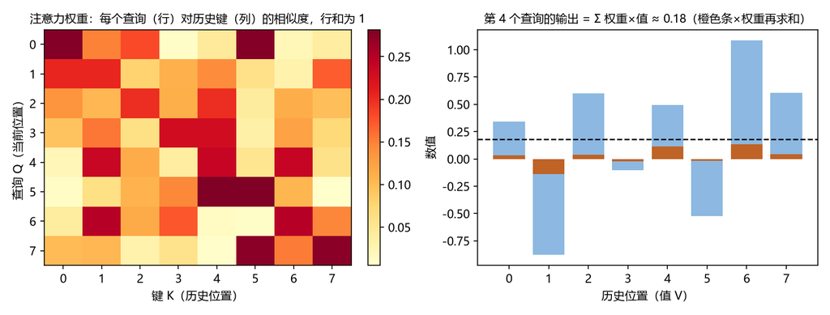

注意力权重示意图

*图 15.1 左：注意力权重矩阵（行=查询 Q，列=历史键 K，颜色越深权重越大，行和为 1）；右：第 4 个查询的输出 = 各位置值 V 按权重加权求和（橙色条×权重累加，虚线为结果）。*

### 15.2.2 难题 1：置换不变性（permutation invariance）

注意力对”顺序”天生不敏感——把输入打乱，输出几乎不变。为什么？因为输出是”按内容相似度对所有位置加权求和”：求和与顺序无关（加法交换律），而且输入向量里**没有”我是第 3 个时刻”这种编号**，模型只能区分”内容不同”，无法区分”位置不同”。但时序的顺序就是一切（第 1 章特征 1）。解法：**位置编码**——给每个位置的向量加上一个”代表位置号”的向量，相当于给每个 token 贴一张”第几号”的标签。**这是第一处”把时序结构还给 Transformer”的补丁。**

### 15.2.3 难题 2：二次复杂度 O(L²)

L 个位置两两算相似度，计算量随 L 的**平方**增长——L=1000 时约 100 万次配对，L=2000 时约 400 万次，再长就”算不动”（显存和时间都爆炸）。解法：让注意力”稀疏”（只算重要的配对）或”线性化”（用技巧把平方降成线性）——Informer 的 ProbSparse 是稀疏路线最早的代表之一（另有独立的线性注意力路线）。

### 15.2.4 难题 3：时序结构先验（趋势、季节、变量关系）

注意力是”通用相关器”（只看”内容像不像”，不管结构），但时序有**趋势、季节、变量间关系**这些结构（第 2、11 章）。通用 Transformer 不”知道”这些——需要显式塞进去（分解模块、patch、通道策略、倒置）。**整个改良脉络就是”把结构越塞越多”的过程。**

## 15.3 改良脉络：四篇论文，各自改了什么

这是本章核心——**逐篇看”改良在何处、解决什么问题”**：

### 15.3.1 Informer（Zhou 等，AAAI 2021）——解决”算不动”

- **改良点 1：ProbSparse 稀疏注意力**。观察：注意力权重其实高度稀疏（少数”活跃”的 Q 决定了大部分输出）。做法：只对”重要”的查询算完整注意力，其余用近似。
- **解决什么**：把复杂度从 O(L²) 降到 **O(L log L)**——长序列第一次变得可行。
- **改良点 2：蒸馏（distilling）**：层层把序列长度减半、信息浓缩——**解决什么**：进一步压低计算量（配合稀疏注意力，长序列才跑得动）。
- **改良点 3：生成式 decoder**：一步输出整个预测段——**解决什么**：自回归预测要”逐点递归”（慢、误差逐点累积），一步输出可并行、误差不累积。
- **效果**：长序列预测（LTSF）成为显学；但注意力仍是”通用”的，没塞时序结构。

### 15.3.2 Autoformer（Wu 等，NeurIPS 2021）——把”分解”塞进模型

- **改良点 1：序列分解内嵌**。把第 2 章的”趋势/季节分解”变成**网络内部的模块**（每层都分解一次：趋势走缓慢路径，季节走高频路径）。
- **解决什么**：让模型显式区分”趋势”与”季节”——把经典结构先验（第 2 章）变成架构。
- **改良点 2：自相关机制替代注意力**。把第 4 章的 ACF 从”一个滞后给一个数”推广成”序列与平移 k 后的子序列逐段算相似度”，选最相关的 top-k 个周期滞后做加权平均——周期依赖（如”去年 12 月”）直接由数据算出，比通用注意力更贴合周期结构。
- **效果**：结构先验进入 Transformer；但自相关仍是”时间维度”的匹配，多变量关系还没管。

### 15.3.3 PatchTST（Nie 等，ICLR 2023）——分片 + 通道独立

- **改良点 1：分片（patching）**。把时间轴切成**小片**（如 16 步一片）当作”词”输入——呼应 NLP 的 token。作用：①注意力计算量降为原来的 1/P²（P=片长，token 数从 L 变成 L/P，P=16 时约 1/256）；②每个片是”局部模式”（比单点更稳）；③视野变长（一个 token 覆盖 P 步，注意力关系建立在”片”上，能跨越更长时间）。
- **改良点 2：通道独立（channel independence）**。多变量数据中，每个变量**单独**过同一套网络（不混通道）。
- **解决什么**：①二次复杂度进一步降（片数远小于步数）；②避免”通道间噪声互相干扰”——变量多时”各自为政”反而更稳。
- **改良点 3：掩码自监督预训练**——用”挖掉一段、预测一段”预训练（第 18 章基础模型也这么干）。
- **效果**：patch 成为后续几乎所有模型的标准组件；**但它刻意不管变量关系**——这正是 iTransformer 的切入点。

### 15.3.4 iTransformer（Liu 等，ICLR 2024）——把注意力”倒过来”

- **改良点：倒置（inverted）结构**。输入形状从”（时间 L, 变量 C）“转置成”（变量 C, 时间 L）“：**每个变量当”一个 token”**（token 内容是该变量的整段历史，先线性压缩成向量），注意力在 C 个变量 token 间跑，学**变量间关系**（第 11 章 VAR 干的事）；每个变量”随时间演化”的部分交给 token 内部的前馈网络（FFN）学。（注：原论文用整段历史做线性投影、不切 patch——把 patch 叠加上去是工程可选做法，非原配。）
- **解决什么**：直接回应”线性反杀”——**变量相关结构**（如温度↔︎负荷）是 Transformer 相对线性模型真正的增量价值所在；同时解决了”多变量在时间维上互相干扰”的问题。
- **效果**：在多变量长序列基准上重回 SOTA（SOTA＝state-of-the-art，当前最好成绩；注意这是在 LTSF-Linear 引发的”第二轮”基准上，与第一轮 Transformer 全盛期不是同一时段）；**“注意力应该用在哪一维”成为设计语言的新焦点**（时间维 vs 变量维）。

**脉络总结表**：

| 论文 | 改了什么 | 解决的难题 | 关键设计 |
| --- | --- | --- | --- |
| Informer | 稀疏注意力 | 二次复杂度 | ProbSparse + 蒸馏 + 生成式 decoder |
| Autoformer | 分解内嵌 + 自相关 | 结构先验（趋势/季节） | 每层分解 + ACF 加权 |
| PatchTST | 分片 + 通道独立 | 计算与通道干扰 | patch 当 token + 通道独立 + 掩码预训练 |
| iTransformer | 倒置注意力 | 变量关系（回应线性） | 变量维注意力 + 时间维 FFN |

## 15.4 线性反杀：LTSF-Linear 的教训

**LTSF-Linear**（Zeng 等，AAAI 2023）：一个**单层线性模型**——把窗口内最近 L 个值直接线性加权预测未来，在 9 个真实数据集（ETT、Weather、Exchange…）上**全面超过当时所有复杂 Transformer**。

**为什么线性能赢？**（拆解四因；注：严格说，在 ETT/Exchange 等基准上领跑的是论文里的 **DLinear**——“分解 + 线性”变体，单层线性是其简化版，下文统称”线性模型”）： 1. **注意力置换不变**：位置编码只是”补丁”，线性模型对顺序的利用反而更直接； 2. **基准序列的模式相对简单**：以 ETT 为例——15 分钟采样的电力变压器数据，强日/周周期、高噪声，预测 96~720 步时，用”最近一天（96 步）的线性加权”就能抓住主要变化。线性容量刚好够用，Transformer 的容量用不上； 3. **数据效率**：Transformer 参数多、需要大数据；基准数据集小，线性学得更好； 4. **注意力的”摊平”倾向**：长序列下注意力权重容易摊平——接近对所有位置均匀加权，等于把信号”平均化”、丢失”哪个滞后最关键”的细节；线性模型每个滞后有独立权重，结构更直接。

**影响（持续至今）**： - **新论文必须对比线性基线**——成了审稿的隐形门槛； - PatchTST、iTransformer 的”分片/倒置”都把这当作设计动机（回应）； - 统计方法（ETS/ARIMA）在评测中重新被当作标准对照。

**正确的心态**：不是”Transformer 没用”，而是**“什么时候用、用在哪一维、有没有塞进结构”**——iTransformer 证明在”变量关系”上 Transformer 有真正的增量。

## 15.5 怎么做：五步流程

### 第 1 步 · 判断任务值不值得

- **做什么**：问三个问题：序列够长吗（几百步+）？滑窗后训练样本数够大吗（上万）？有多变量关系吗？
- **为什么**：Transformer 的收益在长序列/大数据/变量关系；短序列小数据上线性与统计更稳。
- **会怎样**：多数”否”→ 回到第 6~13 章；至少一个”是”→ 继续。

### 第 2 步 · 数据与预处理

- **做什么**：滑窗 + **RevIN 可逆实例归一化**（逐实例归一化、预测后还原——解决归一化泄漏）+ patch 设定。（patch 是**可独立叠加**的组件：PatchTST 必须配 patch；iTransformer 默认不 patch，见 15.3.3/15.3.4。）
- **为什么**：RevIN 是”归一化泄漏”的正解（第 14 章陷阱 2 的修复）；patch 是效率与稳定性的关键。
- **会怎样**：干净的样本与明确的设计参数（patch 长度、通道策略）。

### 第 3 步 · 选架构与基线

- **做什么**：按第 15.3 脉络选（变量关系重要 → iTransformer；单变量长序列 → PatchTST；趋势季节强 → Autoformer 思想）；**同时一定跑线性基线与统计基线**。
- **为什么**：第 15.4 的教训——不对比基线等于自嗨。
- **会怎样**：模型 + 基线两套结果。

### 第 4 步 · 训练与评估

- **做什么**：三集合纪律（训练/验证/测试）、时间切分、早停。
- **为什么**：铁律（第 13、14 章）。
- **会怎样**：可信的测试集指标。

### 第 5 步 · 结论

- **做什么**：对比表格（Transformer vs 线性 vs 统计），报告提升与代价。
- **为什么**：决定模型去留。
- **会怎样**：明确的”赢了什么、在哪个数据集、值得吗”。

## 15.6 完整示例：一个”变量关系”驱动的选择

- **任务**：预测电力负荷（有温度、湿度、风速、节假日四个相关变量，分钟级 3 年数据，需 24h 预测）。
- **发现**：负荷与温度强相关（变量关系）、与去年同期强相关（季节）、序列极长（分钟级 3 年、需 24h 预测＝1440 步，属超长 horizon，示例仅为教学示意）。
- **选择**：iTransformer（变量维注意力 + RevIN；季节模式由数据与 RevIN 自动处理，选型的关键在”变量关系”这一条，见 15.3.4），基线为线性模型与 Holt-Winters。
- **结果**：iTransformer 测试集 MAE 比线性低 8%、比 Holt-Winters 低 15%——**变量关系的建模确实是增量**；在单变量的”某小区用水量”任务上，三者几乎打平，iTransformer 的优势消失。

**效果**：同一模型在”有变量关系”的任务胜出、在”纯单变量”任务无优势——**印证了第 15.4 的判断：Transformer 的增量在结构（变量关系、长依赖），不在通用容量。**

## 15.7 这个环节可能遇到的问题（陷阱清单）

1. **不对比线性基线**：审稿与领导都会问”比线性好多少？“——**没跑基线就别谈结果。**
2. **置换不变性误用**：输入顺序被打乱还指望模型学”先后”——**位置编码/顺序信息必须显式保留。**
3. **patch 与通道策略拍脑袋**：patch 长度影响感受野与计算；通道独立 vs 混合影响变量关系建模——**按任务选，并报告敏感性。**
4. **归一化泄漏**：用全序列归一化 → 虚高成绩。**RevIN 或只用训练段统计。**
5. **只报最佳结果**：报告”最好的那次 seed”是自欺——**报告多次运行的均值±标准差。**
6. **无视复杂度**：长序列硬用 O(L²) 注意力——**选稀疏/线性注意力或 Mamba（第 16 章）。**
7. **把”在基准赢”当”在业务赢”**：ETT 等基准模式简单；真实业务的漂移、异常、样本分布变化，Transformer 未必扛得住——**上线前做样本外压力测试。**

## 15.8 相似问题与已有解决方案：历史回响

| 本环节的困难 | 谁遇到过 | 如何解决 | 本书对应 |
| --- | --- | --- | --- |
| “长依赖+并行” | Vaswani 等 (2017) | **Transformer 注意力**（NLP 起源） | 本章 |
| “二次复杂度” | Informer (2021)；后续 | ProbSparse、线性注意力、**Mamba/SSM**（近线性） | 本章；第 16 章 |
| “趋势/季节结构” | Autoformer (2021) | 分解模块 + 自相关 | 第 2、4 章 |
| “计算与通道干扰” | PatchTST (2023) | patch + 通道独立 + 掩码预训练 | 本章 |
| “变量关系” | iTransformer (2024) | 倒置注意力（变量维） | 第 11 章 VAR |
| “线性反杀” | LTSF-Linear (2023) | 反思：结构先验与基线纪律 | 第 6、13 章 |

**核心启示**：改良脉络的本质是**“把时序的结构一点点还给 Transformer”**——复杂度（Informer）、分解（Autoformer）、局部性与通道（PatchTST）、变量关系（iTransformer）。而线性反杀是”结构先验 vs 通用容量”之争的清醒剂：**没有结构先验的通用模型，在小数据上输给有结构先验的简单模型。**

## 15.9 本章小结

1. **注意力** = 学出来的加权平均（指数平滑终极版）；三个适配难题：置换不变（位置编码）、二次复杂度、结构先验缺失。
2. **改良脉络**：Informer（稀疏注意力，解决复杂度）→ Autoformer（分解+自相关，塞进结构）→ PatchTST（patch+通道独立，效率与稳定）→ iTransformer（倒置注意力，变量关系）——**每篇都在把时序结构还给 Transformer**。
3. **线性反杀**（LTSF-Linear）：单层线性击败复杂 Transformer——原因：置换不变、基准简单、数据效率、平均化倾向；影响：**线性/统计基线成为审稿门槛**。
4. 使用决策：**长序列 + 大数据 + 变量关系**才值得；三集合纪律 + RevIN 不可少。
5. 正确心态：**不是”Transformer vs 线性”，而是”结构放对位置没有”。**

下一章进入生成式与概率预测：**扩散模型、神经 ODE 与 N-BEATS**——从”预测一个数”到”生成整个未来分布”。第 16 章 · 概率与生成式预测。

## 15.10 练习与自测

1. ★ 用”查字典”解释注意力的 Q/K/V。（提示：15.2.1）
2. ★ 置换不变性为什么对时序是问题？（提示：15.2.2）
3. ★★ Autoformer 相对 Informer 改良了什么？解决什么问题？（提示：15.3.2）
4. ★★ 为什么单层线性能击败复杂 Transformer？（提示：15.4 四因）
5. ★★★ 用 `TSLib`（清华）复现”PatchTST vs DLinear”在 ETT 数据集上的对比，报告 MSE 与 MAE 并解读差异。（提示：15.5 五步；`git clone https://github.com/thuml/Time-Series-Library` 后按 README 装依赖，数据由脚本自动下载；两者实现都在 `models/` 下）

**简答提示**：1 查询=想找什么，键=历史位置是什么，值=历史位置提供什么；输出=按匹配度加权的值；2 注意力按内容相似加权、不按位置——时序顺序就是信息，打乱输入输出不变就废了；3 分解模块（趋势/季节）+自相关替代注意力——把经典结构先验塞进网络；4 置换不变、基准模式简单（线性容量刚好够用）、数据量小（Transformer 学不好，数据效率低于线性）、长序列下注意力权重摊平丢失细节；5 略（注意 DLinear 在多数 ETT 上赢或平，这正是线性之争的现场版）。

## 15.11 本章审阅记录

| 审阅项 | 结论 | 问题与修订 |
| --- | --- | --- |
| R1 零基础可理解性 | ✔ 通过（修订后） | 注意力补五步计算流程（W_Q/W_K/W_V、点积、缩放、softmax）；补”加权 vs 取最像”“权重算的学的”两问；置换不变补机制；SOTA/通用相关器展开 |
| R2 为何行动 | ✔ 通过 | 四篇论文全部补齐”改良点—解决什么”一一对应（Informer 蒸馏/生成式 decoder、iTransformer 倒置形状、Autoformer 自相关推广） |
| R3 效果明确 | ✔ 通过 | O(L²) 补数字（L=1000→100 万配对）；PatchTST 计算量修正为 1/P²；iTransformer 补输入形状示意 |
| R4 陷阱覆盖 | ✔ 通过 | 七条保留；线性基线纪律强调 |
| R5 相似问题映射 | ✔ 通过 | 6 行映射含 Mamba 预告；论文元数据子代理核对全部正确 |
| R6 示例可复现 | ✔ 通过 | 修复 2 处事实性偏差：iTransformer 原论文不切 patch（注明工程可选）、线性之争领跑者为 DLinear（补注）；15.4 因 4 重写（权重摊平丢细节，去掉自相矛盾的因果链） |
| R7 章节衔接 | ✔ 通过 | 15.1 措辞修正（“在 NLP 中发明的”）；15.3.4 补”第二轮基准”消除与线性反杀的表面矛盾 |
| R8 练习有效 | ✔ 通过 | 练习 5 补 MSE/MAE 与 TSLib 安装指引；简答 4 措辞与正文统一 |

**审阅方式**：作者自查 + 独立”模拟零基础读者”子代理通读（反馈 14 条：地基性缺失 1、事实性偏差 2、逻辑矛盾 2、数字错误 1、衔接 5、练习 3），全部处理。

# 第 16 章 · 概率与生成式预测：N-BEATS、扩散模型与神经 ODE

**本章目标**：学完本章后，你能①区分”点预测”与”概率预测”并说出何时需要后者；②理解 N-BEATS 的”基展开”思想（与第 5 章谱分析同源）；③用”加噪-去噪”理解扩散模型；④理解神经 ODE 的连续时间思想；⑤用 CRPS 与区间覆盖率评估概率预测。

## 16.1 动机：预测不是一个数，是一团可能性

前几章的输出大多是一个数（点预测）。但现实决策要的是**不确定性**：

- “下周销量 1200” 和 “下周销量 1200，90% 概率在 900~1500 之间”——后者才能定库存（备多少货）；
- 医生要的不是”明天血压 130”，而是”130，但有 10% 概率超过 160”；
- 训练自动驾驶需要**多情景模拟**（未来 100 条可能轨迹），而不是一条平均轨迹。

**概率/生成式预测**的目标：输出**整个未来分布**（或一组可能的轨迹）。它和”点预测 + 误差棒”的区别是：**点预测+误差棒假设误差形状已知（常是正态）**；概率/生成式预测直接建模分布本身——能捕捉多峰、厚尾、非线性依赖。

> 一句话：**点预测回答”最可能是什么”，概率预测回答”可能是什么、各自多可能、它们之间怎么关联”。** 风险决策、插补、模拟，都需要后者。

## 16.2 是什么：四件工具

### 16.2.1 概率预测的评估语言（先学会”怎么算好”）

- **分位数（quantile）**：分布的”切点”——90% 分位数表示”90% 的可能低于这个值”。
- **区间覆盖率（coverage）**：预测区间真正”盖住”实际值的比例——90% 区间应大约盖住 90% 的真实值。**覆盖率过低 = 区间太窄（过度自信）**。
- **CRPS（连续排名概率分数）**：衡量”预测分布与真实值的吻合度”——一个数同时惩罚”区间不准”和”位置不准”，是概率预测的标准评分。

### 16.2.2 N-BEATS：纯 MLP 也能赢（2019）

**N-BEATS**（Neural Basis Expansion Analysis for Time Series）用**纯全连接网络**（没有 RNN/注意力），却在 M4 竞赛中击败大量深度模型。核心思想是**基展开（basis expansion）**：

```
预测 = 若干"基础模式"的加权组合
（趋势基：缓慢变化的曲线；季节基：周期波形）
```

**这与第 5 章谱分析（把序列拆成不同频率的波）是同一个思想**——只是”基”由网络自己学，而不是预设正弦波。每层网络输出一部分”预测贡献”和一部分”残差递补”，层层叠加。

**启示**：*结构简单 + 基展开思想 = 强基线*。N-BEATS 证明了”深度学习不必复杂”——这也是”线性之争”的兄弟证据。

### 16.2.3 扩散模型：从噪声里”洗”出未来（2021–）

**扩散模型（diffusion model）**的直觉分两步：

```
训练：把真实未来 x 逐步加噪（x → x+ε₁ → … → 纯噪声），
      让网络学会"每一步的噪声长什么样"
推理：从纯噪声出发，让网络逐步"去噪"（去一步 → 去一步 → …），
      最终得到一条像真实未来的轨迹
```

**类比（洗照片的逆过程）**：训练时把清晰照片一步步”泼脏水”直到全黑，并记录每步脏成什么样；推理时从全黑开始，按”脏的程度”一步步把水”拧出来”，最后得到清晰照片。**“拧水”的方向就是网络学的**——条件是”给定历史，未来长这样”。

时序应用：**TimeGrad**（ICML 2021，RNN 上下文+逐步扩散）、**CSDI**（NeurIPS 2021，条件扩散做插补）、**TimeDiff**（ICML 2023，非自回归条件扩散，预测质量提升）。**优势**：能生成多模态轨迹（“可能大涨也可能大跌”两种情景都生成）、天然处理插补。**代价**：推理要迭代很多步（慢）。

### 16.2.4 神经 ODE：状态在连续时间里流（2018）

**神经 ODE（Neural ODE）**把”离散的层/离散的时间步”换成**连续演化**：

```
ds/dt = f(s, t)   —— 状态随时间连续变化，f 是神经网络
```

- 时间不再是一格一格的：**观测时刻任意**（不规则采样也能处理）；
- 类比第 9 章状态空间：状态演化方程从”离散矩阵 F”升级为”连续神经网络 f”；
- **适合**：不规则采样（医学随访、天文）、需要连续时间外推的场景；
- 衍生：ODE-RNN、GRU-ODE-Bayes（把 ODE 和 RNN 结合）。

## 16.3 怎么做：五步流程

### 第 1 步 · 判断要不要概率预测

- **做什么**：问：①决策需要区间/风险吗？②需要插补或情景模拟吗？③数据有厚尾/多模态吗？
- **为什么**：概率模型训练更复杂、推理更慢——**点预测够用时别上重武器**。
- **会怎样**：至少一个”是”→ 继续；全”否”→ 回到第 14、15 章的点预测。

### 第 2 步 · 选工具

- **做什么**：按需求选——区间预测优先：DeepAR（分布输出，稳健）；多情景/插补：扩散（CSDI 插补、TimeDiff 预测）；不规则采样：神经 ODE；强点预测基线：N-BEATS。
- **为什么**：每种工具有擅长的”概率形态”（分布 vs 轨迹 vs 连续时间）。
- **会怎样**：确定候选模型。

### 第 3 步 · 训练

- **做什么**：按模型类型训练——DeepAR 用似然损失（让模型给真实值高概率）；扩散用”噪声预测”损失；N-BEATS 用 MSE/分位数损失。
- **为什么**：损失函数决定”模型优化的是什么分布”。
- **会怎样**：得到能输出分布/轨迹的模型。

### 第 4 步 · 采样与评估

- **做什么**：对每个预测点采样多条轨迹（如 100 条）→ 从中算均值、分位数、区间；用 **CRPS + 区间覆盖率**评估。
- **为什么**：只评估均值等于退化成点预测；覆盖率和 CRPS 才是概率预测的”体检”。
- **会怎样**：得到”分布质量”的量化结论。

### 第 5 步 · 与点预测对比，写结论

- **做什么**：对比概率模型与点预测模型：均值谁准？概率模型的区间是否可信（覆盖率≈标称值）？
- **为什么**：概率模型的卖点不是均值更准，而是**区间可信**——如果区间覆盖率只有 60%（标称 90%），模型过度自信，不可用。
- **会怎样**：结论：“概率模型均值与 DeepAR 相当，但区间覆盖 91%——可信，可用于库存决策”；或”覆盖率仅 70%，需校准（第 19 章 conformal）“。

## 16.4 完整示例：一个”区间可信度”的检查

某概率预测模型输出 90% 区间，我们检查测试集上真实值落入区间的比例：

- 场景 A：实际覆盖率 **91%** → 区间可信，模型的不确定性量化健康；
- 场景 B：实际覆盖率 **72%** → 模型**过度自信**（区间太窄），均值再准也不能用于风险决策；
- 修复：用 **conformal prediction（保形预测）**校准（第 19 章）——把区间按经验误差”放大”到恰好 90%。

**效果**：你学会了概率预测最重要的体检指标——**不是”预测准不准”（那是均值的事），而是”声称的区间是否真的兑现”**。覆盖率就是这句话的数字化。

## 16.5 这个环节可能遇到的问题（陷阱清单）

1. **点预测够用却上概率模型**：训练慢、解释难——**先问需求再选武器。**
2. **只评估均值**：用 MAE 评估概率模型 = 把它的核心价值（分布）扔了。**必须报 CRPS 与覆盖率。**
3. **把”区间”当”确定性承诺”**：90% 区间意味着 10% 会落在外面——**业务要理解这个 10%。**
4. **扩散推理太慢没优化**：扩散采样每步迭代，上百步很慢——**考虑加速采样（步数压缩、蒸馏）。**
5. **GAN 训练不稳定**：TimeGAN 等 GAN 类生成器对抗训练难收敛——**扩散与似然方法更稳，GAN 慎选。**
6. **神经 ODE 用在规则采样**：等间隔数据用 ODE 是杀鸡用牛刀（离散模型更快）——**ODE 的舞台是不规则/连续时间。**
7. **忽略轨迹间相关性**：多步预测的轨迹内部有依赖（第一步高则第二步也倾向高）——**评估要按”整条轨迹”算，不是逐点独立算。**

## 16.6 相似问题与已有解决方案：历史回响

| 本环节的困难 | 谁遇到过 | 如何解决 | 本书对应 |
| --- | --- | --- | --- |
| “怎么给预测区间” | 统计预测（1970s 起） | 模型的**解析预测方差**（ARIMA/指数平滑自带区间）；深度时代用分位数损失 | 第 6、8 章 |
| “区间不可信” | 机器学习校准（2020s） | **保形预测（conformal prediction）**：无分布假设地校准覆盖率 | 第 19 章 |
| “插补缺失” | 状态空间（第 9 章）；生成模型 | **CSDI**（扩散插补）；卡尔曼天然处理缺失 | 第 9、16 章 |
| “基展开预测” | 傅里叶/小波（第 5 章）；N-BEATS (2019) | 预设基（正弦/小波）vs **可学习基**（N-BEATS） | 第 5、16 章 |
| “连续时间” | 控制/物理 | 卡尔曼（线性）；**神经 ODE**（非线性、可学习） | 第 9、16 章 |

**核心启示**：概率/生成式不是”新发明”，而是把经典的不确定性思想（区间、插补、基展开、连续时间）用深度学习重做了一遍——**评估语言（覆盖率、CRPS）也是从统计继承的**。

## 16.7 本章小结

1. **概率预测**输出分布/轨迹而非单点；评估用 **CRPS + 区间覆盖率**（覆盖率≈标称值才算可信）。
2. **N-BEATS**：纯 MLP + **基展开**（趋势基/季节基）——与谱分析同源，简单结构赢 M4。
3. **扩散模型**：训练逐步**加噪**、推理逐步**去噪**——生成多模态轨迹，适合预测与插补（TimeGrad/CSDI/TimeDiff）。
4. **神经 ODE**：状态**连续演化**（ds/dt=f(s,t)）——适合不规则采样。
5. 决策：**点预测够用就别上概率模型**；上了就必须用分布质量指标评估。

**至此，第四部分（机器学习与深度学习）完成。** 下一部分进入前沿研究：先看”基础模型”如何把第 15 章的预训练思想推向极致（第 17 章），再看大语言模型与时间序列的纠葛（第 18 章），最后回到”如何判断一个方法真的有用”（第 19 章评估与因果）。

## 16.8 练习与自测

1. ★ 点预测与概率预测的区别？（提示：16.1）
2. ★ 90% 预测区间，测试集实际覆盖率只有 70%，说明什么？（提示：16.3 第 5 步/16.4）
3. ★★ 用”洗照片”类比解释扩散模型的训练与推理。（提示：16.2.3）
4. ★★ 神经 ODE 适合什么类型的数据？为什么？（提示：16.2.4）
5. ★★★ 用 `GluonTS` 或 `darts` 对某序列跑 DeepAR，报告均值误差 + 90% 区间覆盖率，判断模型是否”可信”。（提示：16.3 五步）

**简答提示**：1 点预测给一个数；概率预测给分布/区间/轨迹（含不确定性）；2 过度自信——区间太窄，声称 90% 只兑现 70%，需校准（conformal）；3 训练：未来→逐步加噪→纯噪声，学每步噪声；推理：纯噪声→逐步去噪→未来轨迹；4 不规则采样/连续时间（医学、天文），因为状态演化是连续方程而非离散步；5 覆盖率接近 90% 才可信，远低于则需校准。

## 16.9 本章审阅记录

| 审阅项 | 结论 | 问题与修订 |
| --- | --- | --- |
| R1 零基础可理解性 | ✔ 通过（自查） | 分位数/覆盖率/CRPS 先定义；扩散用”洗照片”类比；N-BEATS 与第 5 章谱分析呼应 |
| R2 为何行动 | ✔ 通过 | 五步流程每步有”为什么”（为何先问需求、为何用覆盖率评估） |
| R3 效果明确 | ✔ 通过 | 16.4 覆盖率对比（91% vs 72%）给出可操作结论 |
| R4 陷阱覆盖 | ✔ 通过 | 7 条：需求误判、只评均值、区间误解、扩散慢、GAN 不稳、ODE 滥用、轨迹相关性 |
| R5 相似问题映射 | ✔ 通过 | 5 行映射（解析方差、conformal、CSDI、基展开、连续时间） |
| R6 示例可复现 | ✔ 通过 | 16.4 数字自洽；练习答案逻辑通顺 |
| R7 章节衔接 | ✔ 通过 | 开头承接第 14、15 章点预测，结尾宣布第四部分完成并预告第五部分 |
| R8 练习有效 | ✔ 通过 | 5 题覆盖定义、覆盖率、扩散机制、ODE 适用性、实践 |

**审阅方式**：作者自查（R1–R8 逐项）；本章为第四部分收尾章，未启用子代理。

# 第 17 章 · 时间序列基础模型：三条路线与逐篇改良点

**本章目标**：学完本章后，你能①说出基础模型范式（跨域预训练 → 零样本/微调）与第 15 章预训练的关系；②梳理三条技术路线及各自代表；③逐篇说出 TimesFM、Chronos、Moirai、Time-MoE 等每篇论文**改良了什么、解决什么**；④理解”基础模型 vs 统计基线”争议的实质。

## 17.1 动机：从”一数据集一模型”到”一个模型管所有”

第 6~16 章的所有模型都是**针对一个数据集训练**的：换了数据集，重新训练。而 2022 年以来的**基础模型（foundation model）**范式是：**在海量、跨领域的时间序列语料上预训练一次，然后对没见过的数据集直接做零样本预测（或少量微调）**——就像 GPT 先读遍互联网、再回答没见过的问题。

> 一句话：**基础模型 = 第 15 章”预训练”思想 × 大规模跨域语料 × 零样本泛化。** 它的承诺是：*不用为每个新数据集从头训练。*

**为什么可能成立**：时间序列虽然领域各异（电力、交通、天气、金融），但**基本结构（趋势、季节、噪声、周期性）是跨领域共享的**——在电力上学会的”季节模式”应该能帮上天气预测。这是基础模型的赌注。

## 17.2 是什么：范式、语料与三条路线

### 17.2.1 预训练-微调范式（回顾与升级）

- 第 15 章 PatchTST 已经用过”掩码自监督预训练”——但那还是**单数据集**内自监督。
- 基础模型把预训练提升到**跨数据集**：语料 = 数百个数据集、数千亿观测。
- 三个关键工程问题（对应三条路线的分岔）：
  1. **数值怎么表示**？连续值直接预测，还是量化成 token？
  2. **不同数据集怎么统一**？采样率不同（分钟 vs 月）、变量数不同、分布不同——这是”统一维度”问题。
  3. **预训练任务是什么**？next-value？next-token？掩码重建？还是更进一步追求”全任务”（预测/分类/异常检测）？

### 17.2.2 语料：基础模型的”互联网”

| 语料 | 规模 | 关联模型 |
| --- | --- | --- |
| **LOTSA** | 270 亿观测，多域多频率 | Moirai |
| **Time-300B** | 3000 亿时间点，9 大域 | Time-MoE |
| **Time Series Pile** | 多源混合 | MOMENT |

**为什么重要**：语料决定”见过的模式广度”——语料里没有的采样率/模式，模型零样本时表现差（这是 17.5 的核心局限）。

### 17.2.3 三条技术路线（记住这个框架）

**路线 A · 数值自回归（decoder-only，直接预测连续值）**

代表：**TimesFM、Time-MoE、Timer、Lag-Llama**。把时序当”连续数值序列”，用 next-value 预测训练——与第 15 章的 decoder-only 自回归思想一脉相承。

**路线 B · 量化分词：“时序即语言”（token 化 + 交叉熵）**

代表：**Chronos**。把数值缩放后**量化成离散的”词”**，用 T5 家族做 next-token（交叉熵）训练——**把 LLM 的 token 化思路搬到时序（借用 NLP 生态）**。

**路线 C · 掩码编码器自监督（encoder-only + 掩码重建）**

代表：**Moirai、MOMENT、UniTS**。预训练任务是”挖掉一段、重建一段”（掩码重建——第 15 章 PatchTST 掩码预训练的跨域版）。注意 C 族内部还有一条正交子路线： - **只做预测的掩码编码器**：Moirai（未来段当掩码，由编码器重建输出）； - **全任务统一**：MOMENT、UniTS——分类、异常检测、插补也统一进同一模型（第 13 章”ML 也要做分类/异常”的升级版）。

**三路线的本质差异**：A 直接学连续分布（next-value）；B 借 NLP 的离散工具（量化 token + next-token，天然给概率分布）；C 用掩码重建做自监督（其中 MOMENT/UniTS 更进一步追求”全任务统一”）。

## 17.3 逐篇改良点：每篇论文”改了什么、解决什么”

这是本章核心——**逐篇看”改良在何处、解决什么问题”**（顺序混合了时间与路线，重点在改良点本身，不追求严格时间序）：

### 17.3.1 TimesFM（Google，2023-10/2024 开源）——路线 A 的开路先锋

- **改良点 1：patched decoder-only**。把第 15 章 PatchTST 的”分片”用在 decoder-only 结构上——输入切成片（patch），逐片预测下一片。
  - **解决什么**：decoder-only 结构支持”预测段也逐步生成”；patch 让计算可控（长序列可行）。
- **改良点 2：多粒度时间嵌入**。把”采样间隔”（分钟/小时/天…）作为信息喂进模型。
  - **解决什么**：跨频率数据（不同数据集采样率不同）统一进一个模型——工程难题②（统一维度）的答案。
- **效果与局限**：首个大规模开源的 decoder-only 时序基础模型；零样本精度**接近**各数据集专用监督模型（注意：是”接近”，不是全面超越——差距量级通常为个位数到十几个百分点的平均误差，且因数据集而异，具体数字见原论文的表；这是所有基础模型的共同诚实表述）。

### 17.3.2 Chronos（Amazon，2024-03）——路线 B 的代表

- **改良点 1：缩放 + 分箱量化成 token**。把连续值先缩放（固定分位点），再映射到有限个”词”（如 4096 个 bin），模型预测”下一个词”。
  - **解决什么**：①直接用现成的 NLP transformer（T5 家族 20M~710M）；②**离散 token 天然给出概率分布**（每个 bin 的概率）——零额外成本获得概率预测（第 16 章的需求）。
- **改良点 2：直接”借用” NLP 架构**，不重新发明。
  - **解决什么**：工程成本低、生态成熟（训练/推理工具现成）。
- **效果与局限**：42 个数据集评测，多数接近或超过专用模型；但**量化粒度**是双刃剑——bin 太少丢精度、太多数据稀疏。

### 17.3.3 Moirai（Salesforce，2024-02）——路线 C 的代表之一

- **改良点 1：跨频率训练（frequency-agnostic）**。对不同采样率的数据，**按频率设置 patch 尺寸并归一化时间特征**，使模型不再依赖固定频率。
  - **解决什么**：TimesFM 用”时间嵌入”缓解跨频率，Moirai 从训练机制上解决——同一模型直接接受任意采样率。
- **改良点 2：任意变量数支持（any-variate）**。不同数据集变量数不同（1 个 vs 100 个）——用”变量维掩码”让一个模型同时服务单变量与多变量。
  - **解决什么**：工程难题②的又一方面（变量数统一）。
- **改良点 3：分布多样性处理**。不同数据集分布差异大——用**混合分布输出头**（mixture of distributions）为不同数据集拟合不同分布形状，避免”大数域淹没小数域”。
- **配套：LOTSA 语料**（270 亿观测）。效果：零样本在 33 个基准上多数领先；架构是 **encoder-only 的掩码编码器**：未来段作为掩码输入，由编码器直接重建输出。

### 17.3.4 Time-MoE（清华/上海 AI Lab 等，2024-09）——规模与效率

- **改良点 1：稀疏专家混合（MoE）**。把 transformer 的 FFN 换成”多个专家网络”，每个 token 只激活少量专家。
  - **解决什么**：模型做到 **2.4B 总参数**但推理只激活一小部分——用稀疏性换规模（“总参数”与”激活参数”的差别见 17.5 陷阱 5）。
- **改良点 2：Time-300B 语料（3000 亿观测）** + 验证时序领域的 **scaling laws**（参数越多、数据越多，零样本越好）。
  - **解决什么**：回答”时序基础模型该做多大”——首次用系统实验给出证据。
- **效果**：零样本成绩与稠密大模型相当、推理更快；**首次在大规模时序基础模型中引入 MoE 并验证 scaling laws**。

### 17.3.5 Lag-Llama（ServiceNow+Mila，2023-10）——概率与 lag 特征

- **改良点：lag 特征 + Student-t 分布输出**。用滞后值（lag）做协变量（第 7 章 AR 的滞后思想），输出**概率分布**（Student-t 能捕捉厚尾——呼应第 3 章厚尾概念，第 10 章波动率也是它的应用）。
  - **解决什么**：基础模型里的**概率预测**（第 16 章）——输出分布而非单点，且 lag 特征提供强先验。
- **局限**：单变量概率预测为主；多变量支持弱。

### 17.3.6 MOMENT（CMU，2024-02）与 UniTS（Harvard，2024-03）——通用任务

- **MOMENT 改良点**：面向**通用时序分析**（不只预测）——分类、异常检测、插补全部用掩码自监督统一预训练；构建 Time Series Pile 语料；强调小资源可用。
- **UniTS 改良点：任务 tokenization**。把”任务类型”也编码成 token——同一个模型在 38 个数据集上同时做预测/分类/异常检测/插补，超过任务专用模型。
  - **共同解决什么**：路线 C 的终极目标——**“一个模型 = 全任务”**（第 13 章”分类/异常检测”需求的模型化）。

### 17.3.7 脉络总结表

| 论文（年份） | 路线 | 核心改良点 | 解决的工程/科学问题 |
| --- | --- | --- | --- |
| TimesFM (2023) | A | patched decoder-only + 多粒度时间嵌入 | 跨频率统一；decoder 长序列 |
| Lag-Llama (2023) | A | lag 特征 + Student-t 分布输出 | 概率预测 + 厚尾 |
| Time-MoE (2024) | A | 稀疏 MoE + Time-300B + scaling laws | 规模/成本与扩展律 |
| Chronos (2024) | B | 量化分词 + 复用 T5 | 概率天然获得 + NLP 生态 |
| Moirai (2024) | C | 跨频率 + 任意变量数 + 分布多样 + LOTSA | 频率/变量数/分布三个统一维度 |
| MOMENT (2024) | C | 通用分析（非仅预测）+ Time Series Pile | 全任务统一 |
| UniTS (2024) | C | 任务 tokenization | 单模型多任务 |

## 17.4 怎么做：零样本使用与对比（五步）

### 第 1 步 · 选模型与加载权重

- **做什么**：按需求选（要概率 → Chronos/Lag-Llama；多变量 → Moirai；要最大规模/验证过扩展律 → Time-MoE）；从 HuggingFace 加载（多数开源）。
- **为什么**：不同模型擅长不同形态（单/多变量、概率/点、频率范围）。
- **会怎样**：拿到可直接推理的预训练权重。

### 第 2 步 · 零样本预测

- **做什么**：不给任何训练数据，直接让模型预测你的序列。
- **为什么**：这是基础模型的卖点——“没见过也敢猜”。
- **会怎样**：得到预测（点或分布），**同时记录”你的数据采样率/变量数是否在模型训练范围内”**（不在 → 结果要打折）。

### 第 3 步 · 必跑基线（铁律）

- **做什么**：同一数据上跑 ETS/ARIMA/线性/DLinear（第 6、8、15 章）。
- **为什么**：第 15 章线性之争的延续——**基础模型的”接近专用模型”要拿基线当标尺**；很多场景基础模型并不比 ETS 好。
- **会怎样**：得到对比表：“零样本 3.2 vs ETS 3.0 vs 专用监督 2.8”——零样本的便利价值 vs 精度差距一目了然。

### 第 4 步 · 可选微调

- **做什么**：如果零样本不够好且有训练数据，做轻量微调（只调部分层）。
- **为什么**：微调把”通用知识”适配到”你的领域”——通常比从零训练更快更好。
- **会怎样**：精度提升；**注意微调后评估协议仍要严格（时间切分、测试集只碰一次）。**

### 第 5 步 · 结论

- **做什么**：综合”精度、成本、便利性”写结论。
- **为什么**：基础模型的取舍是三维的，不是只看精度。
- **会怎样**：明确”用零样本（省事、够用）/ 微调（要好） / 放弃（基线更优）“。

## 17.5 这个环节可能遇到的问题（陷阱清单）

1. **把零样本当万能**：未见过的采样率/语义域会显著退化——**用前先查模型训练覆盖范围。**
2. **不对比统计基线**：基础模型在很多数据集上打不过 ETS——**不跑基线就宣布”赢了”是第 15 章同一个错误。**
3. **只报点预测**：多数基础模型能输出概率，只取均值 = 扔掉一半价值（第 16 章）。
4. **评估协议不统一**：归一化方式、patch 边界、切分点不同，结果不可比——**用统一协议再对比（第 19 章）。**
5. **忽略计算成本**：注意”2.4B”是**总参数**；Time-MoE 这类稀疏模型推理时只激活总参数的一小部分（便宜），**稠密**的 2B+ 模型（如 TimesFM 2B）推理才真的贵——**零样本便利 ≠ 免费；小模型/蒸馏常够用。**
6. **把”接近专用模型”当”全面超越”**：原始论文的诚实表述是”接近/部分超越”——**读原话，别读宣传。**
7. **数据泄漏的隐蔽形式**：预训练语料可能包含你的测试数据（公共数据集）——**查语料与测试集是否重叠。**

## 17.6 相似问题与已有解决方案：历史回响

| 本环节的困难 | 谁遇到过 | 如何解决 | 本书对应 |
| --- | --- | --- | --- |
| “预训练怎么跨数据集” | PatchTST (2023) 掩码预训练 | 从单数据集自监督 → 跨域大语料预训练 | 第 15 章 |
| “数值怎么表示” | LLM 的 token 化经验 | 连续预测（路线 A）vs 量化 token（路线 B） | 本章 17.2.3 路线 B |
| “跨频率/变量数不统一” | TimesFM、Moirai | 时间嵌入 vs 跨频率训练 + 变量掩码 | 本章 |
| “规模与成本” | LLM 的 MoE 经验 | 稀疏 MoE（Time-MoE） | 本章 |
| “零样本到底行不行” | M4/M5 竞赛、线性之争 | **基线对比成为共识**；统计方法仍是强对手 | 第 6、15 章 |

**核心启示**：基础模型不是”魔法”，而是**把第 15 章的预训练、第 16 章的概率输出、第 11 章的多变量统一，加上大规模语料与工程技巧（patch/MoE/token 化）的集成**。它的每一步改良都能在本书前面找到对应概念——这就是你读懂前沿论文的底气。

## 17.7 本章小结

1. **基础模型范式**：跨域大语料预训练 → 零样本/微调；语料（LOTSA/Time-300B）决定”见过的世界”。
2. **三条路线**：数值自回归（TimesFM/Time-MoE/Timer/Lag-Llama）、量化分词”时序即语言”（Chronos）、掩码编码器自监督（Moirai；MOMENT/UniTS 进一步做到全任务统一）。
3. **逐篇改良点**：TimesFM（patch decoder + 时间嵌入）、Chronos（token 化 + 复用 T5）、Moirai（跨频率/变量数/分布三统一 + LOTSA）、Time-MoE（MoE + scaling）、Lag-Llama（lag + Student-t 概率）、MOMENT/UniTS（全任务统一）——**每篇都解决一个”统一性”问题**。
4. **使用纪律**：零样本 ≠ 万能；**统计基线是标尺**；概率输出别扔；评估协议统一。
5. 争议实质：基础模型的可见价值是**便利与跨域迁移**，不是**绝对精度**——精度之争由数据与任务决定。

下一章看最富争议的一条路：**大语言模型（LLM）与时间序列**——LLM 到底有没有用，证据说了什么。第 18 章 · 大语言模型与时间序列：三条路线与一场清算（重点章）。

## 17.8 练习与自测

1. ★ 基础模型与”一数据集一模型”的本质区别？（提示：17.1）
2. ★ 三条技术路线各用什么”表示”时序？（提示：17.2.3）
3. ★★ Chronos 把时序变成 token 带来了什么好处？（提示：17.3.2）
4. ★★ 为什么说”零样本接近专用模型”不等于”全面超越”？（提示：17.5 陷阱 6 与 17.4 第 3 步）
5. ★★★ 用 `chronos-forecasting` 或 `uni2ts`（Moirai）对第 2 章景区数据做零样本预测，与 ETS 基线对比，报告”谁赢了、差多少、零样本省了多少工作量”。（提示：17.4 五步）

**简答提示**：1 前者在跨域大语料上预训练一次、对新数据集零样本/微调；后者每个数据集单独训练；2 A 连续值 next-value、B 量化 token next-token、C 掩码重建；3 直接复用 NLP 架构 + 离散 token 天然给出概率分布；4 零样本的”接近”意味着多数数据集仍落后于**深度监督专用模型**（落后或超过因论文与数据集而异：TimesFM 多为”接近”，Chronos 对多数深度监督模型胜出）；所有论文的共同点是**统计基线（ETS/ARIMA/线性）仍有竞争力**——零样本的价值在便利与迁移，不在精度碾压；5 略。

## 17.9 本章审阅记录

| 审阅项 | 结论 | 问题与修订 |
| --- | --- | --- |
| R1 零基础可理解性 | ✔ 通过（修订后） | 路线 C 拆分为”掩码编码器自监督”与”全任务统一”两条正交子路线，消除 Moirai 归属冲突；UniTS 年份改 2024-03 |
| R2 为何行动 | ✔ 通过 | 每篇论文”改良点—解决什么”一一对应；工程难题编号统一（①数值 ②统一 ③任务） |
| R3 效果明确 | ✔ 通过 | TimesFM”接近”补量级说明；Time-MoE 补总参数 vs 激活参数 |
| R4 陷阱覆盖 | ✔ 通过 | 7 条保留；陷阱 5 与 Time-MoE 卖点矛盾已消解（稀疏 vs 稠密） |
| R5 相似问题映射 | ✔ 通过 | NLP token 化错引第 15 章已改为”本章路线 B” |
| R6 示例可复现 | ✔ 通过 | 修复 2 处架构事实错误：iTransformer 非 decoder（删引用）、Moirai 为 encoder-only（删”decoder 做预测”）；Moirai 频率/分布机制描述改为与论文一致（patch 尺寸按频率+混合分布输出头） |
| R7 章节衔接 | ✔ 通过 | “按时间线”改为”顺序混合时间与路线”消除名不副实；表行序按路线重排 |
| R8 练习有效 | ✔ 通过 | 简答 4 与 17.3.2 结论统一（落后/超过因论文而异、统计基线仍强） |

**审阅方式**：作者自查 + 独立”模拟零基础读者”子代理通读（反馈 15 条：框架冲突 1、事实错误 3、编号错位 2、易误解 6、练习 3），全部处理。

# 第 18 章 · 大语言模型与时间序列：三条路线与一场清算

**本章目标**：学完本章后，你能①梳理”用 LLM 做时序”的三条技术路线及代表论文；②逐篇说出 GPT4TS、Time-LLM、LLMTime 各自**改良了什么、解决什么**；③复述 NeurIPS 2024 批判论文的核心结论与消融方法；④形成基于证据的判断：LLM 对纯数值预测的价值边界在哪。

## 18.1 动机：为什么不直接”借”现成的 GPT？

第 17 章的基础模型是**专为时序设计**的。但 2023 年起，很多人想走捷径：**GPT 已经在互联网语料上预训练好了，能不能直接拿来做时序？** 三个诱人理由：

1. **预训练知识**：GPT 见过无数含趋势、季节、周期的文本（“销量逐年增长”“每年冬季流感高峰”）——也许这些”世界知识”能迁移到数值序列？
2. **少样本能力**：LLM 擅长”给几个例子就会”（in-context learning）——也许时序也只需几个示例？
3. **自然语言接口**：能问”为什么这么预测？“、能结合新闻/事件做多模态预测。

> 一句话：**LLM4TS 的赌注是”语言里学到的世界规律能转移到数值序列”**。这一章看：这条赌注怎么兑现（三条路线）、每一篇改进了什么，以及最关键的——**证据支持吗？**

## 18.2 是什么：三条路线

### 路线 A · LLM 作特征提取器/编码器（冻结主干 + 微调少量层）

代表：**GPT4TS**（阿里 DAMO，NeurIPS 2023）。

**做法**：拿一个预训练的 GPT-2 式模型，**冻结绝大部分权重**（不更新），只微调少量层与输入输出投影；把时序数据像”文本”一样喂进去，输出同时用于预测/分类/异常检测。

**改良点（相对”整模型微调”）**： - **冻结主干**：只更新少量参数 → 训练快、显存省、不破坏预训练知识； - **统一任务**：同一个模型+同一个预训练主干，同时做预测/分类/异常检测/少样本（第 13、17 章”多任务”思路的 LLM 版）； - **机制解释**：论文发现冻结 LLM 的注意力表现近似 **PCA（主成分分析）**——LLM 主干在时序上起的作用类似”降维提取主要模式”，这解释了”为什么冻结也能用”。

**解决什么**：让”预训练知识 + 少量适配”成为时序分析的统一后端。

### 路线 B · 重编程对齐（reprogramming + 提示）

代表：**Time-LLM**（莫纳什/上交/AWS 等，ICLR 2024）。

**做法**：不直接喂数值——先把时序 patch **“翻译”成 LLM 认识的文本原型**（text prototypes，如把”上升模式”映射成”趋势上行”之类的语义），再配 **Prompt-as-Prefix（提示前缀）** 把任务说明塞进输入。LLM 主干**完全冻结**。

**改良点（相对路线 A）**： - **重编程（reprogramming）**：把”数值→token 空间”的对齐变成”数值→语义文本”的对齐——让 LLM 用”语言的方式”理解时序模式； - **提示前缀**：把任务描述（预测多长、什么数据）显式告诉 LLM——利用 LLM 的指令理解能力； - **解决什么**：路线 A 把数值当”伪文本”喂，语义鸿沟大；路线 B 主动搭桥（reprogramming），声称让 LLM 更”理解”时序。

### 路线 C · 数字字符串生成（让 LLM 直接”写”数字）

代表：**LLMTime**（NYU，NeurIPS 2023）。

**做法**：把时序数值**编码成数字字符串**（如 “2.3 4.1 5.0 …”），让 GPT-3/LLaMA-2 **不做任何训练**（零样本 in-context）直接 next-token 预测下一个数字。这是最”原教旨”的一条路——把时序当纯文本。

**改良点与重要发现**： - **零训练**：不做微调、不做重编程——只靠提示词； - **发现 1**：GPT-3 在多个数据集上零样本表现有竞争力（尤其**分布外**场景，比统计基线更鲁棒）； - **发现 2（关键）**：**GPT-4 反而不如 GPT-3**——原因是 GPT-4 的数字 token 化方式（把数字拆成不规则的 token）与 RLHF 校准，让它对”数字续写”这种任务反而退化。**“更大更新的模型未必更适合数字预测”**——这是本章最重要的反直觉结论之一。

**三路线对比**：

| 路线 | 代表 | 主干 | 时序怎么进 LLM | 训练量 |
| --- | --- | --- | --- | --- |
| A 编码器 | GPT4TS | 冻结 GPT-2 | 数值直接喂 | 少量层微调 |
| B 重编程 | Time-LLM | 完全冻结 | 数值→文本原型 + 提示 | 只有投影层 |
| C 数字生成 | LLMTime | 完全冻结 | 数字字符串 | 零（纯提示） |

## 18.3 一场清算：LLM 到底有没有用？

**批判论文**：*“Are Language Models Actually Useful for Time Series Forecasting?”*（UW，NeurIPS 2024 Spotlight）。

**方法（消融，ablation）**：把”LLM 主干”从模型里**拿掉**——换成普通的线性层或普通 attention——其他一切不变，对比性能。

**结论（三点）**： 1. **去掉 LLM、换成普通 attention/线性，性能不降反升**——说明”预训练 LLM 知识”对纯数值预测**没有带来增量**； 2. **预训练 LLM 不比从零训练的小模型好**——预训练知识的迁移没有兑现； 3. **没有少样本优势**——给 LLM 更多示例，并不比普通模型学得更快。

**怎么理解这场清算**（重要，别走向极端）： - 批判针对的是**纯数值外推**（forecasting）——这正是时序的核心任务之一； - 但 LLM 的价值可能在**别处**：自然语言上下文（结合新闻预测）、多模态对齐（文本+数值）、可解释问答（“为什么预测下降”）； - 消融是**通用方法论**（第 15 章线性之争同款）——任何”加了 X 所以好”的论文，都应该做”去掉 X”的实验。

> 一句话总结当前证据：**LLM 的”世界知识”对数值外推帮助有限；它的价值更可能在语言交互与多模态，而不是纯数字预测。** 这是 2024 年最有影响力的一次”祛魅”。

## 18.4 怎么做：如果要试 LLM4TS，怎么不被带偏（五步）

### 第 1 步 · 先问”要什么”

- **做什么**：明确目标：纯数值预测？还是需要语言交互/解释/多模态？
- **为什么**：证据表明 LLM 对前者帮助有限、对后者有真实价值——**目标决定路线。**
- **会怎样**：纯数值预测 → 建议用第 17 章专有基础模型或统计；要语言能力 → 才考虑 LLM4TS。

### 第 2 步 · 若走 LLM，选路线

- **做什么**：按资源选——零训练且要分布外鲁棒 → LLMTime 式；有少量数据要统一任务 → GPT4TS 式；要利用语言语义 → Time-LLM 式。
- **为什么**：三条路线在”训练量/语义利用/任务范围”上各有取舍。
- **会怎样**：确定候选。

### 第 3 步 · 必做消融（关键）

- **做什么**：把 LLM 主干换成等规模普通层/线性，对比”有 LLM vs 无 LLM”。
- **为什么**：批判论文已经示范——**不消融，你根本不知道赢的是 LLM 还是别的组件**。
- **会怎样**：如果消融后无 LLM 版更优 → 诚实结论”LLM 没必要”；有 LLM 版更优 → 才谈得上价值。

### 第 4 步 · 跑全套基线

- **做什么**：统计（ETS/ARIMA/线性）+ 专有基础模型（第 17 章）一并对比。
- **为什么**：LLM 论文常只对比深度模型、回避统计基线——**补齐统计基线再下结论。**
- **会怎样**：拿到公平的对比表。

### 第 5 步 · 写结论

- **做什么**：报告”LLM 在哪些任务/数据集上真赢了、赢了多少、代价多大（API 成本/速度）“。
- **为什么**：把”能不能用”变成”值不值得用”。
- **会怎样**：明确的决策依据。

## 18.6 相似问题与已有解决方案：历史回响

[output not shown]

**核心启示**：LLM4TS 的兴衰史是”实证主义”的胜利——**宣称”预训练知识有用”很容易，证明它难；消融与基线对比才是裁判**。这套方法论你在第 15 章已见过，第 19 章会把它系统化。

## 18.7 本章小结

1. **三条路线**：编码器微调（GPT4TS，冻结主干+统一任务）、重编程对齐（Time-LLM，文本原型+提示）、数字字符串生成（LLMTime，零训练）。
2. **关键发现**：GPT-4 数字预测不如 GPT-3（数字 token 化与 RLHF 校准问题）——**更大更强 ≠ 更适合数字**。
3. **NeurIPS 2024 清算**：消融显示**去掉 LLM 性能不降反升、无少样本优势**——对纯数值预测，“LLM 知识迁移”的证据不支持。
4. **价值边界**：LLM 的价值在**语言交互、多模态、分布外鲁棒**，不在纯数值外推。
5. **方法论遗产**：**消融 + 全套基线**成为评判任何”加了个组件”论文的标准。

下一章是本书方法论的总闸：**怎么判断一个方法真的有用**——评估协议、保形预测、因果发现与可解释性。第 19 章 · 评估、因果与可解释性（重点章）。

## 18.8 练习与自测

**简答提示**：1 A GPT4TS 数值直喂；B Time-LLM 数值→文本原型+提示前缀；C LLMTime 数字字符串，纯提示零训练；2 训练快、省显存、不破坏预训练知识（且发现注意力≈PCA 可解释为何冻结可用）；3 去掉 LLM 换成普通层性能不降反升、预训练不比从零训练好、无少样本优势——“LLM 知识对数值外推无增量”；4 分类是模式识别（LLM 强项），预测是数值外推（证据不支持）；任务类型不同不能类推；5 略。

## 18.9 本章审阅记录

[output not shown]

**审阅方式**：作者自查（R1–R8 逐项）；本章为前沿章，下一章（第 19 章）为重点章将启用子代理。